# Team members and dataset

**Dataset :** Dataset 2, Volcano Events

**DIA 4**

**Team Members:**

- Léo-Paul CHAUVIGNE (Team head)
- Hannah-May LITTIERE
- Timothée JOLIOT
- Axel JUILLARD
- Sandrine DANIEL
- Ovia Mahalakshmi CHANEMOUGANANDAM

# KDD Process Volcano Data Analysis

## Imports

```python
import pandas as pd
import numpy as np
import matplotlib.pyplot as plt
from prophet import Prophet
import plotly.graph_objects as go
import plotly.express as px
import plotly.io as pio
import seaborn as sns
from dash import Dash, dcc, html, Input, Output, State, ctx, dash_table
```

# 1. Data Collection and Exploration

In this section, we implement the first step of the KDD process: Data Collection and Preprocessing. The dataset used is the "Significant Volcanic Eruption Database" provided by the National Center for Environmental Information (NCEI). It contains the data for over 600 eruptions from 4360 BC to the present. Each eruption is detailed with attributes such as location, time, VEI (Volcanic Explosivity Index), and impact metrics (deaths, damage).

**Objectives of this step:**

1. Load the data into a Pandas DataFrame.
2. Clean the data by handling missing values and correct data types.
3. Summarize the data (shape, types, missing values) to understand its quality.
4. Establish rankings between variables to identify initial patterns.

```python
#Display settings to ensure we see all columns during exploration
pd.set_option('display.max_columns', None)
```

## First look at data

```python
# Function for printing the shape and data types of the dataset
# Input: a dataframe (df)
# Output: None (prints information to console)
def show_structure(df):
    rows, cols = df.shape # Extract the number of rows and columns from the DataFrame's shape attribute.
    print(f"Number of Rows: {rows}") # Print the total number of rows in the DataFrame.
    print(f"Number of Columns: {cols}") # Print the total number of columns in the DataFrame.

    print("Data Types:") # Print a descriptive header for the data types output.
    print(df.dtypes) # Print the data type of each column in the DataFrame.
```

```python
# Function for reading the TSV file with volcano events data
# Input: the path to the file (filepath)
# Output: a raw dataframe or None if file not found
def load_raw_data(filepath): # Define a function named load_raw_data that takes a filepath as input.
    # Tries to load the data, if it succeeds it returns the dataframe, if it fails it returns None # Explain the logic of the try-except block.
    try: # Start a try block to handle potential errors during file operations.
        df = pd.read_csv(filepath, sep='\t') # Read the TSV file into a pandas DataFrame using tab as a separator.
        print("File loaded.") # Print a success message if the file is loaded successfully.
        return df # Return the loaded DataFrame.
    except FileNotFoundError: # Catch the FileNotFoundError if the specified file does not exist.
        print("File not found. Please check the path.") # Print an error message if the file is not found.
        return None # Return None to indicate that the file could not be loaded.


# Place the volcano-events.tsv file in the same directory as this notebook # Comment advising on the placement of the data file.
file_path = "volcano-events.tsv" # Define the string variable file_path with the name of the TSV file.
df_raw = load_raw_data(file_path) # Call the load_raw_data function with the specified file_path and store the result in df_raw.

# We display the first 5 rows of the dataframe for a first peak at the data # Comment explaining the purpose of the next line.
df_raw.head(5) # Display the first 5 rows of the df_raw DataFrame.
```

```
File loaded.
```

|  | Search Parameters | Year | Mo | Dy | Tsu | Eq | Name | Location | Country | Latitude | Longitude | Elevation (m) | Type | VEI | Agent | Deaths | Death Description | Missing | Missing Description | Injuries | Injuries Description | Damage ($Mil) | Damage Description | Houses Destroyed | Houses Destroyed Description | Total Deaths | Total Death Description | Total Missing | Total Missing Description | … |
| --- | --- | --- | --- | --- | --- | --- | --- | --- | --- | --- | --- | --- | --- | --- | --- | --- | --- | --- | --- | --- | --- | --- | --- | --- | --- | --- | --- | --- | --- | --- |
| 0 | [] | NaN | NaN | NaN | NaN | NaN | NaN | NaN | NaN | NaN | NaN | NaN | NaN | NaN | NaN | NaN | NaN | NaN | NaN | NaN | NaN | NaN | NaN | NaN | NaN | NaN | NaN | NaN | NaN | … |
| 1 | NaN | -4360.0 | NaN | NaN | NaN | NaN | Macauley | Kermadec Is | New Zealand | -30.210 | -178.475 | 238.0 | Caldera | 6.0 | NaN | NaN | NaN | NaN | NaN | NaN | NaN | NaN | NaN | NaN | NaN | NaN | NaN | NaN | NaN | … |
| 2 | NaN | -4350.0 | NaN | NaN | NaN | NaN | Kikai | Ryukyu Is | Japan | 30.793 | 130.305 | 704.0 | Caldera | 7.0 | P | NaN | 3.0 | NaN | NaN | NaN | NaN | NaN | 3.0 | NaN | 3.0 | NaN | 3.0 | NaN | NaN | … |
| 3 | NaN | -4050.0 | NaN | NaN | NaN | NaN | Masaya | Nicaragua | Nicaragua | 11.985 | -86.165 | 594.0 | Caldera | 6.0 | NaN | NaN | NaN | NaN | NaN | NaN | NaN | NaN | NaN | NaN | NaN | NaN | NaN | NaN | NaN | … |
| 4 | NaN | -4000.0 | NaN | NaN | NaN | NaN | Witori | New Britain-SW Pac | Papua New Guinea | -5.576 | 150.516 | 724.0 | Caldera | 6.0 | T | NaN | 1.0 | NaN | NaN | NaN | NaN | NaN | 1.0 | NaN | NaN | NaN | 1.0 | NaN | NaN | … |

```python
show_structure(df_raw)
```

```
Number of Rows: 888
Number of Columns: 35
Data Types:
Search Parameters                      object
Year                                  float64
Mo                                    float64
Dy                                    float64
Tsu                                   float64
Eq                                    float64
Name                                   object
Location                               object
Country                                object
Latitude                              float64
Longitude                             float64
Elevation (m)                         float64
Type                                   object
VEI                                   float64
Agent                                  object
Deaths                                float64
Death Description                     float64
Missing                               float64
Missing Description                   float64
Injuries                              float64
Injuries Description                  float64
Damage ($Mil)                         float64
Damage Description                    float64
Houses Destroyed                      float64
Houses Destroyed Description          float64
Total Deaths                          float64
Total Death Description               float64
Total Missing                         float64
Total Missing Description             float64
Total Injuries                        float64
Total Injuries Description            float64
Total Damage ($Mil)                   float64
Total Damage Description              float64
Total Houses Destroyed                float64
Total Houses Destroyed Description    float64
dtype: object
```

With this first look at the data we notice a few things:

- The first row is filled with NaNs and the search parameter value is '[]'. It seems this row is an artefact, we will remove it.
- There appears to be a lot of NaNs in the data, we will need to take this into account. We will also need to distinguish between missing values and 0 values.
- The date data is split between 3 columns, 'Year', 'Mo' and 'Dy'. We will need to take this into account. The date columns are also in float64. Although this is counter-intuitive for date components (which should be integers) it is explained the presence of missing values (NaNs). In pandas, a column of integers containing even a single NaN is automatically cast to float
- In addition when looking at the Year column we also see that there are negative years, we will therefore need to add a way to display Years with B.C. and A.D. for readability in the dashboard but we will keep the values numerical for now.
- The agent column here has a value 'P' and a value 'T', these are characteristic and each letter stands for something, we will therefore have to understand what each letter stands for.
- A lot of columns have a 'normal' version and a 'total' version (Ex: Deaths & Total Deaths), we need to understand the difference between the two.
- A lot of columns also hava a corresponding 'definition' column (Death Description, Damage Description, Houses Destroyed Description) which are float values too. This could be interesting to look at as the descriptions could be ordinal scales we could use to impute missing values. For example here we see a row with no 'Deaths' recorded but a Death Description of '3.0'.

### Dropping the artefact row and column:

```python
#Function to drop the first row and column of the dataframe as they are artefacts of the data collection process.
#Input: pandas dataframe
#Output: pandas dataframe with first row and column dropped
def drop_first_row_and_column(df):
    df1 = df.copy() # Create a copy of the input DataFrame to avoid modifying the original
    df1 = df1.iloc[1:] # Drop the first row of the DataFrame
    df1 = df1.iloc[:, 1:] # Drop the first column of the DataFrame
    return df1 # Return the modified DataFrame

df_raw_2 = drop_first_row_and_column(df_raw)
df_raw_2.head()
```

|  | Year | Mo | Dy | Tsu | Eq | Name | Location | Country | Latitude | Longitude | Elevation (m) | Type | VEI | Agent | Deaths | Death Description | Missing | Missing Description | Injuries | Injuries Description | Damage ($Mil) | Damage Description | Houses Destroyed | Houses Destroyed Description | Total Deaths | Total Death Description | Total Missing | Total Missing Description | Total Injuries | … |
| --- | --- | --- | --- | --- | --- | --- | --- | --- | --- | --- | --- | --- | --- | --- | --- | --- | --- | --- | --- | --- | --- | --- | --- | --- | --- | --- | --- | --- | --- | --- |
| 1 | -4360.0 | NaN | NaN | NaN | NaN | Macauley | Kermadec Is | New Zealand | -30.210 | -178.475 | 238.0 | Caldera | 6.0 | NaN | NaN | NaN | NaN | NaN | NaN | NaN | NaN | NaN | NaN | NaN | NaN | NaN | NaN | NaN | NaN | … |
| 2 | -4350.0 | NaN | NaN | NaN | NaN | Kikai | Ryukyu Is | Japan | 30.793 | 130.305 | 704.0 | Caldera | 7.0 | P | NaN | 3.0 | NaN | NaN | NaN | NaN | NaN | 3.0 | NaN | 3.0 | NaN | 3.0 | NaN | NaN | NaN | … |
| 3 | -4050.0 | NaN | NaN | NaN | NaN | Masaya | Nicaragua | Nicaragua | 11.985 | -86.165 | 594.0 | Caldera | 6.0 | NaN | NaN | NaN | NaN | NaN | NaN | NaN | NaN | NaN | NaN | NaN | NaN | NaN | NaN | NaN | NaN | … |
| 4 | -4000.0 | NaN | NaN | NaN | NaN | Witori | New Britain-SW Pac | Papua New Guinea | -5.576 | 150.516 | 724.0 | Caldera | 6.0 | T | NaN | 1.0 | NaN | NaN | NaN | NaN | NaN | 1.0 | NaN | NaN | NaN | 1.0 | NaN | NaN | NaN | … |
| 5 | -3580.0 | NaN | NaN | NaN | NaN | Taal | Luzon-Philippines | Philippines | 14.002 | 120.993 | 311.0 | Stratovolcano | 6.0 | NaN | NaN | NaN | NaN | NaN | NaN | NaN | NaN | NaN | NaN | NaN | NaN | NaN | NaN | NaN | NaN | … |

### Taking a look at missing values:

```python
# Function to calculate and print the number of missing values per column
# Input: df (pd.DataFrame)
# Output: None
def show_missing_data(df):
    # Shows the number of missing data points in each column
    # Calculate the sum of null values for each column in the DataFrame
    missing_values = df.isnull().sum()


    # Print a header indicating the following output is about missing data
    print("Missing Data Points per Column:")
    # Print the Series containing the count of missing values for each column
    print(missing_values)

show_missing_data(df_raw_2)
```

```
Missing Data Points per Column:
Year                                    0
Mo                                    131
Dy                                    191
Tsu                                   705
Eq                                    808
Name                                    0
Location                                0
Country                                 0
Latitude                                0
Longitude                               0
Elevation (m)                           0
Type                                    0
VEI                                   182
Agent                                 363
Deaths                                444
Death Description                     317
Missing                               875
Missing Description                   873
Injuries                              786
Injuries Description                  763
Damage ($Mil)                         863
Damage Description                    639
Houses Destroyed                      837
Houses Destroyed Description          759
Total Deaths                          422
Total Death Description               291
Total Missing                         875
Total Missing Description             872
Total Injuries                        783
Total Injuries Description            753
Total Damage ($Mil)                   859
Total Damage Description              618
Total Houses Destroyed                828
Total Houses Destroyed Description    732
dtype: int64
```

Taking a look at the number of missing values per column (NaNs) :

We decide to keep the missing values as they are. This will allow us to better understand the data as we will be able to plot and compare columns where data is present. If we were to impute the missing values, we would be distorting the data and potentially leading to false conclusions.

### Looking and dealing with the agent data

```python
df_raw['Agent'].unique()
```

```
array([nan, 'P', 'T', 'P,T', 'W', 'M', 'T,L', 'S,W', 'F', 'I', 'T,F',
       'P,T,M', 'A', 'L', 'E', 'M,T', 'S', 'P,E,M', 'G,W,T', 'G,T',
       'T,P,W,I', 'T,P', 'm', 'G', 'W,S', 'W,T', 'P,I', 'T,W,I', 'F,P,I',
       'W,A', 'M,L,T,G', 'T,W', 'T, m', 'P,M', 'P,M,E', 'P,W,A,I', 'G,I',
       'W,M', 'T,A', 'L,G', 'W,P,I', 'A,P', 'I,M', '?', 'W,P', 'P,W',
       'T,G', 'P,m', 'I,S,A,T', 'S,L', 'P,W,T', 'A,F', 'P,T,W,I', 'E,I',
       'T,L,I', 'P,T,M,A', 'M,m,P', 'P,M,I', 'P,T,G', 'M,P', 'T,m', 'T,M',
       'P,L', 'P,M,T', 'A,T,W', 'P,T,M,S', 'I,T', 'L,T', 'P,m,I', 'T,I',
       'A,W', 'T,G,M', 'S,T,G', 'A,P,T', 'P,T,W', 'G,W, S', 'L,I,S',
       'M,G,T', 'T,P,L'], dtype=object)
```

Looking in further detail at the agent column we can see that sometimes an eruption has multiple agents. Here the agents are separated by a comma. We will need to seperate them into binary columns to better analyse them.

After further research we can see that the agents are as follows: Based on the NOAA Significant Volcanic Eruption Database and the classification standards by Simkin and Siebert (1994), the Agent column indicates the specific volcanic hazard or phenomenon that caused fatalities, injuries, or damage during an eruption.

- A : Avalanche (Debris)
- E : Electrical (Lightning)
- F : Floods
- G : Gas
- I : Indirect (Starvation, Disease)
- L : Lava Flow
- M : Mudflow (Lahar) (Primary) (upper case indicates the event happened at the same time as the eruption)
- m : Mudflow (Lahar) (Secondary) (lower case indicates the event happened after the eruption)
- P : Pyroclastic Flow
- S : Seismic
- T : Tephra/Ash fall (falling volcanic rock and ash).
- W : Waves
- ? : Unknown

We define a function to divide the agents into binary columns. Here we will treat nans as 'no agents' as we can see a '?' unkown agent exists and therefore needs to be treated separately :

```python
# Function to split the comma-separated 'Agent' column into individual binary columns for easier analysis.
# intput: df (pd.DataFrame)
# output: df_agent_divided (pd.DataFrame) without the agent column and with binary
def divide_agents(df):
    df_agent_divided = df.copy()
    # Convert to string, handle NaNs as empty strings, and remove spaces (e.g. "T, m" -> "T,m")
    agents_cleaned = df_agent_divided['Agent'].fillna('').astype(str).str.replace(' ', '')

    # We Split and Create the Binary Columns
    # 'sep=,' tells pandas to treat comma as the delimiter
    agent_dummies = agents_cleaned.str.get_dummies(sep=',')

    # Rename columns for clarity (e.g. "P" -> "Agent_P")
    agent_dummies = agent_dummies.add_prefix('Agent_')

    # Concatenate the new columns to the original dataframe
    df_agent_divided = pd.concat([df_agent_divided, agent_dummies], axis=1)

    # Drops the original 'Agent' column
    df_agent_divided = df_agent_divided.drop(columns=['Agent'])

    return df_agent_divided

# Let's see the result
df_agent_divided = divide_agents(df_raw_2)
df_agent_divided.dtypes
```

```
Year                                  float64
Mo                                    float64
Dy                                    float64
Tsu                                   float64
Eq                                    float64
Name                                   object
Location                               object
Country                                object
Latitude                              float64
Longitude                             float64
Elevation (m)                         float64
Type                                   object
VEI                                   float64
Deaths                                float64
Death Description                     float64
Missing                               float64
Missing Description                   float64
Injuries                              float64
Injuries Description                  float64
Damage ($Mil)                         float64
Damage Description                    float64
Houses Destroyed                      float64
Houses Destroyed Description          float64
Total Deaths                          float64
Total Death Description               float64
Total Missing                         float64
Total Missing Description             float64
Total Injuries                        float64
Total Injuries Description            float64
Total Damage ($Mil)                   float64
Total Damage Description              float64
Total Houses Destroyed                float64
Total Houses Destroyed Description    float64
Agent_?                                 int64
Agent_A                                 int64
Agent_E                                 int64
Agent_F                                 int64
Agent_G                                 int64
Agent_I                                 int64
Agent_L                                 int64
Agent_M                                 int64
Agent_P                                 int64
Agent_S                                 int64
Agent_T                                 int64
Agent_W                                 int64
Agent_m                                 int64
dtype: object
```

Now we notice something interesting. Tsunamis (Waves) and Earthquakes (Seismic) are listed in agents aswell as there standalone columns although this is discutable because the names are not exactly the same. We therefore need to check if the agents and the standalone columns' values overlap before continuing. Now that we have divided the agents into binary columns, we need to check the format of the 'Tsu' column and the 'Eq' column.

```python
df_raw['Tsu'].unique()
```

```
array([      nan, 3.000e+00, 3.473e+03, 2.100e+01, 3.093e+03, 3.900e+01,
       6.100e+01, 3.102e+03, 2.852e+03, 3.107e+03, 3.112e+03, 2.874e+03,
       5.863e+03, 2.190e+02, 2.220e+02, 3.129e+03, 2.530e+02, 5.754e+03,
       2.690e+02, 2.850e+02, 5.482e+03, 2.930e+02, 3.120e+02, 3.138e+03,
       3.470e+02, 3.141e+03, 3.750e+02, 3.148e+03, 3.150e+03, 3.870e+02,
       4.190e+02, 4.310e+02, 2.853e+03, 5.000e+02, 5.040e+02, 5.250e+02,
       5.280e+02, 5.290e+02, 5.680e+02, 5.770e+02, 3.221e+03, 6.130e+02,
       6.230e+02, 6.310e+02, 6.540e+02, 6.630e+02, 7.060e+02, 7.110e+02,
       7.180e+02, 7.140e+02, 7.300e+02, 7.310e+02, 7.410e+02, 8.090e+02,
       8.210e+02, 8.590e+02, 8.620e+02, 8.690e+02, 9.290e+02, 9.580e+02,
       9.710e+02, 3.451e+03, 1.022e+03, 1.020e+03, 1.068e+03, 1.086e+03,
       1.095e+03, 1.096e+03, 1.109e+03, 5.480e+03, 1.142e+03, 1.143e+03,
       1.144e+03, 1.145e+03, 5.777e+03, 1.175e+03, 1.181e+03, 1.197e+03,
       5.608e+03, 5.629e+03, 1.280e+03, 2.881e+03, 2.873e+03, 1.288e+03,
       2.433e+03, 5.696e+03, 5.697e+03, 1.291e+03, 1.326e+03, 3.413e+03,
       1.346e+03, 1.356e+03, 1.357e+03, 1.358e+03, 1.359e+03, 1.360e+03,
       1.365e+03, 1.363e+03, 1.392e+03, 1.400e+03, 1.407e+03, 1.412e+03,
       3.147e+03, 1.454e+03, 1.452e+03, 3.511e+03, 1.476e+03, 1.478e+03,
       5.720e+03, 1.593e+03, 1.607e+03, 1.624e+03, 4.218e+03, 1.657e+03,
       1.666e+03, 1.698e+03, 3.638e+03, 5.694e+03, 4.227e+03, 1.769e+03,
       3.383e+03, 1.816e+03, 1.824e+03, 5.928e+03, 1.825e+03, 1.826e+03,
       1.827e+03, 1.833e+03, 5.566e+03, 1.838e+03, 3.395e+03, 1.856e+03,
       1.882e+03, 1.902e+03, 1.942e+03, 1.977e+03, 5.695e+03, 5.478e+03,
       1.992e+03, 2.872e+03, 2.043e+03, 2.054e+03, 5.761e+03, 2.069e+03,
       2.080e+03, 2.115e+03, 3.018e+03, 5.759e+03, 4.702e+03, 2.154e+03,
       5.807e+03, 5.808e+03, 5.926e+03, 5.927e+03, 2.229e+03, 2.392e+03,
       2.265e+03, 2.279e+03, 2.880e+03, 2.340e+03, 2.923e+03, 2.694e+03,
       5.795e+03, 2.877e+03, 5.758e+03, 3.587e+03, 4.822e+03, 5.584e+03,
       5.676e+03, 5.678e+03, 5.796e+03, 5.699e+03, 5.930e+03, 5.913e+03,
       5.716e+03, 5.748e+03, 5.905e+03, 5.912e+03, 5.824e+03, 5.865e+03,
       5.868e+03, 5.906e+03, 5.923e+03])
```

```python
df_raw['Tsu'].nunique()==df_raw['Tsu'].notna().sum()
```

```
np.True_
```

This is weird, the Tsunami column is filled with incredibly high float values. Whatmore there is a different value per Tsunami.

This can be explained by the fact that these values are foreign keys, linking these tsunamis to a tsunami event dataset, this would explain the reason that tsunamis and earthquakes are seperated from the agents column.

We verify that this is also the case for the earthquakes column:

```python
df_raw['Eq'].unique()
```

```
array([   nan,  5877.,  7795.,    58.,  7341.,   421.,  9973.,  9788.,
         814.,   920.,  9756.,   942., 10519.,  6879.,  1017.,  1057.,
        8202.,  1129.,  1178.,  1205.,  1304.,  1328.,  1348.,  9532.,
        1515.,  6650.,  6651.,  1787.,  6050.,  1865.,  1867.,  1995.,
        6125., 10184.,  2049.,  6150.,  2125.,  7967.,  2179., 10023.,
        6195.,  6625.,  6198.,  2347.,  6309.,  2595., 10011.,  8158.,
        8391.,  2973.,  2994.,  6877., 10435., 10010.,  3974.,  4116.,
        4227.,  4292.,  4704.,  4876.,  7221.,  4990.,  6652.,  5150.,
        5292.,  5387., 10747.,  6499.,  5568.,  5659., 10555.,  9172.,
       10140., 10332., 10556., 10382., 10383., 10501., 10545., 10744.])
```

```python
df_raw['Eq'].nunique()==df_raw['Eq'].notna().sum()
```

```
np.True_
```

Since these two columns are foreign keys, we will treat them as boolean values, as in if a row is not null, it is equal to 1, otherwise it is equal to 0.

```python
# Function to process 'Tsu' and 'Eq' columns by replacing NaN with 0 and non-NaN with 1
# Input: df (pandas.DataFrame)
# Output: df_processed (pandas.DataFrame)
def process_tsu_eq_columns(df):
    df_tsu_eq_processed = df.copy() # Create a copy of the input DataFrame to avoid modifying the original.
    for col in ['Tsu', 'Eq']: # Iterate through the specified columns 'Tsu' and 'Eq'.
        if col in df_tsu_eq_processed.columns: # Check if the current column exists in the DataFrame.
            df_tsu_eq_processed[col] = df_tsu_eq_processed[col].notna().astype(int) # Convert non-NaN values to 1 and NaN values to 0 for the current column.
    return df_tsu_eq_processed # Return the processed DataFrame.

df_tsu_eq_processed = process_tsu_eq_columns(df_agent_divided)
df_tsu_eq_processed.head()
```

|  | Year | Mo | Dy | Tsu | Eq | Name | Location | Country | Latitude | Longitude | Elevation (m) | Type | VEI | Deaths | Death Description | Missing | Missing Description | Injuries | Injuries Description | Damage ($Mil) | Damage Description | Houses Destroyed | Houses Destroyed Description | Total Deaths | Total Death Description | Total Missing | Total Missing Description | Total Injuries | Total Injuries Description | … |
| --- | --- | --- | --- | --- | --- | --- | --- | --- | --- | --- | --- | --- | --- | --- | --- | --- | --- | --- | --- | --- | --- | --- | --- | --- | --- | --- | --- | --- | --- | --- |
| 1 | -4360.0 | NaN | NaN | 0 | 0 | Macauley | Kermadec Is | New Zealand | -30.210 | -178.475 | 238.0 | Caldera | 6.0 | NaN | NaN | NaN | NaN | NaN | NaN | NaN | NaN | NaN | NaN | NaN | NaN | NaN | NaN | NaN | NaN | … |
| 2 | -4350.0 | NaN | NaN | 0 | 0 | Kikai | Ryukyu Is | Japan | 30.793 | 130.305 | 704.0 | Caldera | 7.0 | NaN | 3.0 | NaN | NaN | NaN | NaN | NaN | 3.0 | NaN | 3.0 | NaN | 3.0 | NaN | NaN | NaN | NaN | … |
| 3 | -4050.0 | NaN | NaN | 0 | 0 | Masaya | Nicaragua | Nicaragua | 11.985 | -86.165 | 594.0 | Caldera | 6.0 | NaN | NaN | NaN | NaN | NaN | NaN | NaN | NaN | NaN | NaN | NaN | NaN | NaN | NaN | NaN | NaN | … |
| 4 | -4000.0 | NaN | NaN | 0 | 0 | Witori | New Britain-SW Pac | Papua New Guinea | -5.576 | 150.516 | 724.0 | Caldera | 6.0 | NaN | 1.0 | NaN | NaN | NaN | NaN | NaN | 1.0 | NaN | NaN | NaN | 1.0 | NaN | NaN | NaN | NaN | … |
| 5 | -3580.0 | NaN | NaN | 0 | 0 | Taal | Luzon-Philippines | Philippines | 14.002 | 120.993 | 311.0 | Stratovolcano | 6.0 | NaN | NaN | NaN | NaN | NaN | NaN | NaN | NaN | NaN | NaN | NaN | NaN | NaN | NaN | NaN | NaN | … |

```python
df_tsu_eq_processed['Tsu'].unique()
```

```
array([0, 1])
```

```python
df_tsu_eq_processed['Eq'].unique()
```

```
array([0, 1])
```

The tsunami and earthquake columns are now binary indicators like the agent columns.

We now process to check if they overlapp with similar agents (Tsunami with waves and floods and Earthquakes with seismic)

```python
# Specialized EDA function to check whether tsunami and earthquake data overlaps with the agent column. We also include a check to see if floods overlap with tsunamis as tsunamis could also be considered as causing floods.
# Input: df_agent_divided (pd.DataFrame) with agent columns divided
# Output: None
def check_tsu_eq_consistency(df_agent_divided):
    # We count the number of 'Tsu' and 'Eq' occurences.
    tsu_col_count = df_agent_divided['Tsu'].sum()
    eq_col_count = df_agent_divided['Eq'].sum()

    # We count the number of 'S', 'W', and 'F' codes in the 'Agent' column.
    agent_S_col_count = df_agent_divided['Agent_S'].sum()
    agent_W_col_count = df_agent_divided['Agent_W'].sum()
    agent_F_col_count = df_agent_divided['Agent_F'].sum()


    # Print the counts
    print(f"\nCOUNTS:")
    print(f"Total non-null 'Tsu' column values: {tsu_col_count}")
    print(f"Total 'W' (Waves) codes in Agent:   {agent_W_col_count}")
    print(f"Total 'F' (Floods) codes in Agent:  {agent_F_col_count}\n")

    print(f"Total non-null 'Eq' column values:  {eq_col_count}")
    print(f"Total 'S' (Seismic) codes in Agent: {agent_S_col_count}\n")



    # Now we check if there is overlap between the standalone columns and the agent columns
    print(f"\nCONSISTENCY CHECK:")

    # Check Tsunami (Agent_W vs Tsu)
    # Mismatch A: Has 'Tsu' Data (Not Null) BUT 'Agent_W' is 0
    mismatch_tsu_A = df_agent_divided[df_agent_divided['Tsu'].notna() & (df_agent_divided['Agent_W'] == 0)]

    # Mismatch B: Has 'Agent_W' (== 1) BUT 'Tsu' is Missing (NaN)
    mismatch_tsu_B = df_agent_divided[(df_agent_divided['Agent_W'] == 1) & df_agent_divided['Tsu'].isna()]

    if mismatch_tsu_A.empty and mismatch_tsu_B.empty:
        print("Tsunami Data (Agent_W): The data is consistent.")
        print(" Every row with a Tsunami flag (W) has a corresponding 'Tsu' data and vice versa.")
    else:
        print("Tsunami Data (Agent_W): The data is not consistent.")
        if not mismatch_tsu_A.empty:
            print(f"   - {len(mismatch_tsu_A)} rows have 'Tsu' data but are missing the 'W' agent.")
        if not mismatch_tsu_B.empty:
            print(f"   - {len(mismatch_tsu_B)} rows have 'W' agent but are missing 'Tsu' data.")

    # Check Flood (Agent_F vs Tsu) - Added consistency check for floods and tsunamis
    # Mismatch A: Has 'Tsu' Data (Not Null) BUT 'Agent_F' is 0
    mismatch_flood_tsu_A = df_agent_divided[df_agent_divided['Tsu'].notna() & (df_agent_divided['Agent_F'] == 0)]

    # Mismatch B: Has 'Agent_F' (== 1) BUT 'Tsu' is Missing (NaN)
    mismatch_flood_tsu_B = df_agent_divided[(df_agent_divided['Agent_F'] == 1) & df_agent_divided['Tsu'].isna()]

    print(f"\n")
    if mismatch_flood_tsu_A.empty and mismatch_flood_tsu_B.empty:
        print("Flood Data (Agent_F) vs Tsunami Data (Tsu): The data is consistent.")
        print(" Every row with a Flood flag (F) has corresponding 'Tsu' data and vice versa.")
    else:
        print("Flood Data (Agent_F) vs Tsunami Data (Tsu): The data is not consistent.")
        if not mismatch_flood_tsu_A.empty:
            print(f"   - {len(mismatch_flood_tsu_A)} rows have 'Tsu' data but are missing the 'F' agent.")
        if not mismatch_flood_tsu_B.empty:
            print(f"   - {len(mismatch_flood_tsu_B)} rows have 'F' agent but are missing 'Tsu' data.")


    # Check Earthquake (Agent_S vs Eq)

    # Mismatch A: Has 'Eq' Data (Not Null) BUT 'Agent_S' is 0
    mismatch_eq_A = df_agent_divided[df_agent_divided['Eq'].notna() & (df_agent_divided['Agent_S'] == 0)]

    # Mismatch B: Has 'Agent_S' (== 1) BUT 'Eq' is Missing (NaN)
    mismatch_eq_B = df_agent_divided[(df_agent_divided['Agent_S'] == 1) & df_agent_divided['Eq'].isna()]

    print(f"\n")
    if mismatch_eq_A.empty and mismatch_eq_B.empty:
        print("Earthquake Data: The data is consistent.")
        print(" Every row with an Earthquake flag has a corresponding 'S' agent and vice versa.")
    else:
        print("Earthquake Data: The data is not consistent.")
        if not mismatch_eq_A.empty:
            print(f"   - {len(mismatch_eq_A)} rows have 'Eq' data but are missing the 'S' agent.")
        if not mismatch_eq_B.empty:
            print(f"   - {len(mismatch_eq_B)} rows have 'S' agent but are missing 'Eq' data.")

# We run the function on df_agent_divided
check_tsu_eq_consistency(df_tsu_eq_processed)
```

```
COUNTS:
Total non-null 'Tsu' column values: 182
Total 'W' (Waves) codes in Agent:   64
Total 'F' (Floods) codes in Agent:  11

Total non-null 'Eq' column values:  79
Total 'S' (Seismic) codes in Agent: 25


CONSISTENCY CHECK:
Tsunami Data (Agent_W): The data is not consistent.
   - 823 rows have 'Tsu' data but are missing the 'W' agent.


Flood Data (Agent_F) vs Tsunami Data (Tsu): The data is not consistent.
   - 876 rows have 'Tsu' data but are missing the 'F' agent.


Earthquake Data: The data is not consistent.
   - 862 rows have 'Eq' data but are missing the 'S' agent.
```

Allthough tsunamis and waves overlapp and earthquakes and seismic activity overlap, we will keep them separate to better understand the data.

### Analysing and Processing 'normal' and 'total' pairs

We have several pairs of columns: Deaths vs Total Deaths, Missing vs Total Missing, etc. We needto understand the relationship between them. Logically, the 'Total' column should represent the sum of direct and indirect effects ( Tsunamis, Earthquakes), so it should be greater than or equal to the 'Normal' column.

```python
#Function to analyze the relationship between 'Normal' columns (e.g., Deaths) and 'Total' columns (e.g., Total Deaths),
# and also compares their corresponding 'Description' columns. Provides detailed counts for different comparison scenarios, including potential anomalies.
#Input: df (pd.DataFrame)
#Output: None (prints analysis results to console)
def analyze_total_vs_normal(df):
    # Define pairs of numerical columns to compare.
    # Each tuple contains (normal_column_name, total_column_name).
    numerical_pairs = [
        ('Deaths', 'Total Deaths'),
        ('Missing', 'Total Missing'),
        ('Injuries', 'Total Injuries'),
        ('Damage ($Mil)', 'Total Damage ($Mil)'),
        ('Houses Destroyed', 'Total Houses Destroyed')
    ]

    # Define pairs of description columns to compare.
    # These often correspond to the numerical columns.
    definition_pairs = [
        ('Death Description', 'Total Death Description'),
        ('Missing Description', 'Total Missing Description'),
        ('Injuries Description', 'Total Injuries Description'),
        ('Damage Description', 'Total Damage Description'),
        ('Houses Destroyed Description', 'Total Houses Destroyed Description')
    ]

    print("--- Numerical Column Comparison ---")
    # Define headers for the numerical comparison table.
    numerical_headers = [
        'Normal Column', 'Total Column', 'Both Present',
        'Normal == Total', 'Normal < Total', 'Normal > Total (Anomaly)'
    ]
    # Print the formatted header for the numerical comparison.
    print(f"{numerical_headers[0]:<20} | {numerical_headers[1]:<25} | {numerical_headers[2]:<15} | {numerical_headers[3]:<18} | {numerical_headers[4]:<18} | {numerical_headers[5]}")
    print("-" * 140) # Separator line

    # Iterate through each numerical column pair to perform analysis.
    for normal_col, total_col in numerical_pairs:
        # Check if both columns exist in the DataFrame. If not, print a message and skip.
        if normal_col not in df.columns or total_col not in df.columns:
            print(f"{normal_col:<20} | {total_col:<25} | {'N/A':<15} | {'N/A':<18} | {'N/A':<18} | {'N/A'} (Columns not found)")
            continue

        # Filter the DataFrame to include only rows where both normal and total values are present (not NaN).
        both_present_df = df.dropna(subset=[normal_col, total_col])
        count_both_present = len(both_present_df) # Count of rows with both values.

        # If no rows have both values, print a message and skip to the next pair.
        if count_both_present == 0:
            print(f"{normal_col:<20} | {total_col:<25} | {count_both_present:<15} | {'N/A':<18} | {'N/A':<18} | {'N/A'}")
            continue

        # Perform detailed analysis of the relationships between the two columns.
        # Count cases where the normal value is equal to the total value.
        count_normal_eq_total = (both_present_df[normal_col] == both_present_df[total_col]).sum()
        # Count cases where the normal value is less than the total value.
        count_normal_lt_total = (both_present_df[normal_col] < both_present_df[total_col]).sum()
        # Count cases where the normal value is greater than the total value.
        # This relationship often indicates a potential anomaly or data inconsistency.
        count_normal_gt_total = (both_present_df[normal_col] > both_present_df[total_col]).sum()

        # Print the analysis results for the current numerical column pair.
        print(
            f"{normal_col:<20} | {total_col:<25} | {count_both_present:<15} | "
            f"{count_normal_eq_total:<18} | {count_normal_lt_total:<18} | {count_normal_gt_total}"
        )

    print("\n--- Description Column Comparison ---")
    # Define headers for the description comparison table.
    definition_headers = [
        'Normal Description', 'Total Description', 'Both Present',
        'Identical', 'Normal < Total', 'Normal > Total (Anomaly)' # Lexicographical comparison
    ]
    # Print the formatted header for the description comparison.
    print(f"{definition_headers[0]:<25} | {definition_headers[1]:<30} | {definition_headers[2]:<15} | {definition_headers[3]:<15} | {definition_headers[4]:<15} | {definition_headers[5]}")
    print("-" * 140) # Separator line

    # Iterate through each description column pair to perform analysis.
    for normal_def_col, total_def_col in definition_pairs:
        # Check if both description columns exist in the DataFrame. If not, print a message and skip.
        if normal_def_col not in df.columns or total_def_col not in df.columns:
            print(f"{normal_def_col:<25} | {total_def_col:<30} | {'N/A':<15} | {'N/A':<15} | {'N/A':<15} | {'N/A'} (Columns not found)")
            continue

        # Filter the DataFrame to include only rows where both description values are present (not NaN).
        both_present_df = df.dropna(subset=[normal_def_col, total_def_col])
        count_both_present = len(both_present_df) # Count of rows with both values.

        # If no rows have both values, print a message and skip to the next pair.
        if count_both_present == 0:
            print(f"{normal_def_col:<25} | {total_def_col:<30} | {count_both_present:<15} | {'N/A':<15} | {'N/A':<15} | {'N/A'}")
            continue

        # Perform detailed analysis of relationships for description columns using lexicographical comparison.
        # This compares strings based on their alphabetical order.
        # Count cases where the normal description is identical to the total description.
        count_identical = (both_present_df[normal_def_col] == both_present_df[total_def_col]).sum()
        # Count cases where the normal description is lexicographically "less than" the total description.
        count_normal_lt_total_desc = (both_present_df[normal_def_col] < both_present_df[total_def_col]).sum()
        # Count cases where the normal description is lexicographically "greater than" the total description.
        # Similar to numerical anomalies, this might indicate unusual data ordering or inconsistencies.
        count_normal_gt_total_desc = (both_present_df[normal_def_col] > both_present_df[total_def_col]).sum()

        # Print the analysis results for the current description column pair.
        print(
            f"{normal_def_col:<25} | {total_def_col:<30} | {count_both_present:<15} | "
            f"{count_identical:<15} | {count_normal_lt_total_desc:<15} | {count_normal_gt_total_desc}"
        )

analyze_total_vs_normal(df_tsu_eq_processed)
```

```
--- Numerical Column Comparison ---
Normal Column        | Total Column              | Both Present    | Normal == Total    | Normal < Total     | Normal > Total (Anomaly)
--------------------------------------------------------------------------------------------------------------------------------------------
Deaths               | Total Deaths              | 441             | 427                | 12                 | 2
Missing              | Total Missing             | 11              | 11                 | 0                  | 0
Injuries             | Total Injuries            | 97              | 97                 | 0                  | 0
Damage ($Mil)        | Total Damage ($Mil)       | 23              | 21                 | 2                  | 0
Houses Destroyed     | Total Houses Destroyed    | 47              | 46                 | 1                  | 0

--- Description Column Comparison ---
Normal Description        | Total Description              | Both Present    | Identical       | Normal < Total  | Normal > Total (Anomaly)
--------------------------------------------------------------------------------------------------------------------------------------------
Death Description         | Total Death Description        | 568             | 564             | 4               | 0
Missing Description       | Total Missing Description      | 14              | 14              | 0               | 0
Injuries Description      | Total Injuries Description     | 123             | 122             | 1               | 0
Damage Description        | Total Damage Description       | 236             | 227             | 9               | 0
Houses Destroyed Description | Total Houses Destroyed Description | 126             | 124             | 2               | 0
```

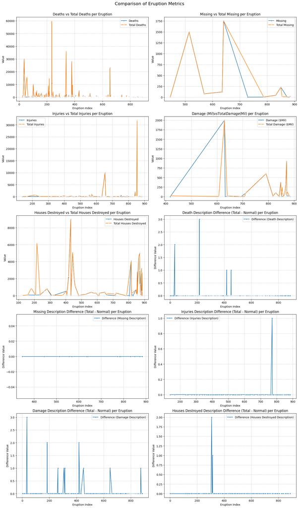

```python
# Function to plot curve graphs comparing pairs of related metrics per eruption.
#input: df (pandas.DataFrame)
#output: None
def plot_normal_vs_toal_curves_over_eruptions(df):
    """
    For certain pairs (e.g., 'Deaths' vs 'Total Deaths'), two lines
    are plotted on the same subplot against the DataFrame's index (representing eruptions).
    For 'Description' related pairs, the difference ('Total' - 'Normal') is plotted.
    """
    # Define pairs of columns to be compared. Each tuple contains (normal_metric, total_metric).
    comparison_pairs = [
        ('Deaths', 'Total Deaths'),
        ('Missing', 'Total Missing'),
        ('Injuries', 'Total Injuries'),
        ('Damage ($Mil)', 'Total Damage ($Mil)'),
        ('Houses Destroyed', 'Total Houses Destroyed'),
        ('Death Description', 'Total Death Description'),
        ('Missing Description', 'Total Missing Description'),
        ('Injuries Description', 'Total Injuries Description'),
        ('Damage Description', 'Total Damage Description'),
        ('Houses Destroyed Description', 'Total Houses Destroyed Description')
    ]

    # Determine the number of subplots needed based on the number of comparison pairs.
    num_pairs = len(comparison_pairs)
    # Arrange subplots in a grid with a fixed number of columns (e.g., 2 columns).
    n_cols = 2
    # Calculate the number of rows required for the grid.
    n_rows = (num_pairs + n_cols - 1) // n_cols

    # Create the figure and a set of subplots.
    # 'figsize' sets the total size of the figure, 'layout='constrained'' adjusts subplot params for a tight layout.
    fig, axes = plt.subplots(n_rows, n_cols, figsize=(15, 5 * n_rows), layout='constrained')
    # Flatten the axes array to easily iterate over subplots, regardless of grid dimensions.
    axes = axes.flatten()

    # Iterate through each comparison pair and its corresponding subplot.
    for i, (col1, col2) in enumerate(comparison_pairs):
        # Get the current subplot axis.
        ax = axes[i]

        # Check if both columns for the current pair exist in the DataFrame.
        if col1 in df.columns and col2 in df.columns:
            # Differentiate plotting logic for 'Description' related columns vs. numerical columns.
            if "Description" in col1 and "Description" in col2:
                # For Description columns, calculate and plot the difference ('Total' - 'Normal').
                diff_label = f'Difference ({col2.replace("Total ", "")})'
                sns.lineplot(data=df, x=df.index, y=df[col2] - df[col1], label=diff_label, ax=ax, marker='o', markersize=4)
                # Set the title for the difference plot.
                ax.set_title(f'{col2.replace("Total ", "")} Difference (Total - Normal) per Eruption')
                # Set the Y-axis label.
                ax.set_ylabel('Difference Value')
            else:
                # For numerical columns, plot both the 'Normal' and 'Total' values on the same subplot.
                sns.lineplot(data=df, x=df.index, y=col1, label=col1, ax=ax, marker='o', markersize=4)
                sns.lineplot(data=df, x=df.index, y=col2, label=col2, ax=ax, marker='x', markersize=4)
                # Set the title for the comparison plot.
                ax.set_title(f'{col1} vs {col2} per Eruption')
                # Set the Y-axis label.
                ax.set_ylabel('Value')

            # Set common X-axis label for all plots.
            ax.set_xlabel('Eruption Index')
            # Display the legend to distinguish between lines.
            ax.legend()
            # Add a grid to the subplot for better readability.
            ax.grid(True, linestyle='--', alpha=0.7)
        else:
            # If columns are missing, display a message on the subplot.
            ax.set_title(f'Data Missing for {col1} or {col2}')
            ax.text(0.5, 0.5, 'Columns not found in DataFrame',
                    horizontalalignment='center', verticalalignment='center',
                    transform=ax.transAxes, fontsize=12, color='red')
            # Hide x and y ticks for empty subplots.
            ax.set_xticks([])
            ax.set_yticks([])

    # Hide any unused subplots if the number of pairs is less than the total number of subplots created.
    for j in range(i + 1, len(axes)):
        fig.delaxes(axes[j])

    # Add a main title for the entire figure.
    plt.suptitle('Comparison of Eruption Metrics', fontsize=16, y=1.02)
    # Display the plot.
    plt.show()

plot_normal_vs_toal_curves_over_eruptions(df_tsu_eq_processed)
```

Comparing the 'Total' and 'Normal' columns we see that they are largely the same, with some value not overlapping and some anomalies (like total being inferior to normal). To analyse the data more easily we will consolidate all of these column pairs into the normal column (Total Deaths and Deaths will be consolidated in the Death column while Total Death will be dropped). To consolidate and remove anomalies we will take the maximum between the two columns for each eruption.

```python
# Function to process volcano data by consolidating 'Total' and 'Normal' columns.
# Input: df (pd.DataFrame)
# Output: pd.DataFrame: processed dataframe
def process_total_normal_data(df):
    """
    Comparing 'Total' and 'Normal' columns (e.g., 'Total Deaths' and 'Deaths'), anomalies
    can be observed where values might not overlap or 'Total' values are sometimes
    less than their 'Normal' counterparts. To address these inconsistencies and
    streamline analysis, this function consolidates these pairs into the 'Normal'
    column by taking the maximum value between the two for each eruption.
    The 'Total' columns are then dropped.
    """
    column_pairs = [ # Initialize a list of tuples, where each tuple contains a 'Normal' column name and its corresponding 'Total' column name.
        ('Deaths', 'Total Deaths'), # Pair for death counts.
        ('Missing', 'Total Missing'), # Pair for missing person counts.
        ('Injuries', 'Total Injuries'), # Pair for injury counts.
        ('Damage ($Mil)', 'Total Damage ($Mil)'), # Pair for damage in millions of dollars.
        ('Houses Destroyed', 'Total Houses Destroyed'), # Pair for houses destroyed counts.
        ('Death Description', 'Total Death Description'), # Pair for death descriptions.
        ('Missing Description', 'Total Missing Description'), # Pair for missing descriptions.
        ('Injuries Description', 'Total Injuries Description'), # Pair for injury descriptions.
        ('Damage Description', 'Total Damage Description'), # Pair for damage descriptions.
        ('Houses Destroyed Description', 'Total Houses Destroyed Description') # Pair for houses destroyed descriptions.
    ]

    for col_name, total_col_name in column_pairs: # Iterate through each 'Normal' and 'Total' column pair.
        # Calculate the maximum between the two columns for each row
        df[col_name] = df[[col_name, total_col_name]].max(axis=1) # For each row, update the 'Normal' column with the maximum value between itself and its 'Total' counterpart.

    # Drop the 'Total' columns
    columns_to_drop = [pair[1] for pair in column_pairs] # Create a list containing only the 'Total' column names from the `column_pairs`.
    df = df.drop(columns=columns_to_drop) # Drop all the 'Total' columns from the DataFrame.

    return df # Return the processed DataFrame.

df_processed = process_total_normal_data(df_tsu_eq_processed)
```

```python
df_processed.head()
```

|  | Year | Mo | Dy | Tsu | Eq | Name | Location | Country | Latitude | Longitude | Elevation (m) | Type | VEI | Deaths | Death Description | Missing | Missing Description | Injuries | Injuries Description | Damage ($Mil) | Damage Description | Houses Destroyed | Houses Destroyed Description | Agent_? | Agent_A | Agent_E | Agent_F | Agent_G | Agent_I | … |
| --- | --- | --- | --- | --- | --- | --- | --- | --- | --- | --- | --- | --- | --- | --- | --- | --- | --- | --- | --- | --- | --- | --- | --- | --- | --- | --- | --- | --- | --- | --- |
| 1 | -4360.0 | NaN | NaN | 0 | 0 | Macauley | Kermadec Is | New Zealand | -30.210 | -178.475 | 238.0 | Caldera | 6.0 | NaN | NaN | NaN | NaN | NaN | NaN | NaN | NaN | NaN | NaN | 0 | 0 | 0 | 0 | 0 | 0 | … |
| 2 | -4350.0 | NaN | NaN | 0 | 0 | Kikai | Ryukyu Is | Japan | 30.793 | 130.305 | 704.0 | Caldera | 7.0 | NaN | 3.0 | NaN | NaN | NaN | NaN | NaN | 3.0 | NaN | 3.0 | 0 | 0 | 0 | 0 | 0 | 0 | … |
| 3 | -4050.0 | NaN | NaN | 0 | 0 | Masaya | Nicaragua | Nicaragua | 11.985 | -86.165 | 594.0 | Caldera | 6.0 | NaN | NaN | NaN | NaN | NaN | NaN | NaN | NaN | NaN | NaN | 0 | 0 | 0 | 0 | 0 | 0 | … |
| 4 | -4000.0 | NaN | NaN | 0 | 0 | Witori | New Britain-SW Pac | Papua New Guinea | -5.576 | 150.516 | 724.0 | Caldera | 6.0 | NaN | 1.0 | NaN | NaN | NaN | NaN | NaN | 1.0 | NaN | NaN | 0 | 0 | 0 | 0 | 0 | 0 | … |
| 5 | -3580.0 | NaN | NaN | 0 | 0 | Taal | Luzon-Philippines | Philippines | 14.002 | 120.993 | 311.0 | Stratovolcano | 6.0 | NaN | NaN | NaN | NaN | NaN | NaN | NaN | NaN | NaN | NaN | 0 | 0 | 0 | 0 | 0 | 0 | … |

### Analysing and dealing with description pairs

```python
# Function to check unique values in all columns ending with 'Description'
# Input: df (pd.DataFrame)
# Output: None
def check_description_values(df):
    print("Inspecting Unique Values in Description Columns") # Print a header message indicating the start of the inspection process.

    # Filter columns that end with 'Description'
    description_cols = [col for col in df.columns if col.endswith('Description')] # Create a list of column names that end with 'Description'.

    if not description_cols: # Check if the list of description columns is empty.
        print("No columns ending with 'Description' found.") # Print a message if no description columns are found.
        return # Exit the function if no description columns are present.

    for col in description_cols: # Iterate through each column identified as a 'Description' column.
        # Get unique values, dropping NaNs to see the codes clearly
        unique_vals = sorted(df[col].dropna().unique()) # Get the unique values from the current column, drop NaN values, and sort them.
        print(f"Unique values in '{col}': {unique_vals}") # Print the column name and its sorted unique values.

# Run the function
check_description_values(df_processed)
```

```
Inspecting Unique Values in Description Columns
Unique values in 'Death Description': [np.float64(1.0), np.float64(2.0), np.float64(3.0), np.float64(4.0)]
Unique values in 'Missing Description': [np.float64(1.0), np.float64(2.0), np.float64(3.0), np.float64(4.0)]
Unique values in 'Injuries Description': [np.float64(1.0), np.float64(2.0), np.float64(3.0), np.float64(4.0)]
Unique values in 'Damage Description': [np.float64(1.0), np.float64(2.0), np.float64(3.0), np.float64(4.0)]
Unique values in 'Houses Destroyed Description': [np.float64(1.0), np.float64(2.0), np.float64(3.0), np.float64(4.0)]
```

Looking at the description columns we see that they represent ordinal scales like we thought. This can be redundant with the columns that represent the actual number of fatalities, injuries, missing persons... But maybe they are interesting since we may lack precise data for some of the older eruptions.

```python
# Function to analyze potential information loss in Description columns
# Input: df_processed which no longer has the total columns(pd.DataFrame)
# Output: Prints a summary table
def analyze_information_loss(df):
    """
    Analyzes potential information loss for all Description columns.
    It counts rows where the Quantitative value is Missing (NaN)
    but the Qualitative Description exists (Not NaN), and vice-versa.
    """

    # 1. Define the pairs: (Quantitative Column, Description Column)
    pairs = [
        ('Deaths', 'Death Description'),
        ('Missing', 'Missing Description'),
        ('Injuries', 'Injuries Description'),
        ('Damage ($Mil)', 'Damage Description'),
        ('Houses Destroyed', 'Houses Destroyed Description'),
    ]

    print(f"{'Quantitative Column':<25} | {'Missing Qty':<12} | {'Description Col':<30} | {'Hidden Data (Loss)':<20} | {'Missing Desc'}")
    print("-" * 120)

    for qty_col, desc_col in pairs:
        # Verify columns exist in dataframe to avoid errors
        if qty_col not in df.columns or desc_col not in df.columns:
            print(f"{qty_col:<25} | {'N/A':<12} | {desc_col:<30} | {'Column Not Found':<20} | {'Column Not Found'}")
            continue

        # Count total missing quantitative values
        missing_qty = df[qty_col].isna().sum()

        # Count "Hidden Data": Rows where Qty is NaN AND Desc is NOT NaN
        # These are the events you lose if you simply drop the description column.
        hidden_data_loss_count = df[df[qty_col].isna() & df[desc_col].notna()].shape[0]

        # Count "Missing Description": Rows where Qty is NOT NaN AND Desc is NaN
        # These are events with a quantitative value but no descriptive context.
        missing_desc_count = df[df[qty_col].notna() & df[desc_col].isna()].shape[0]

        print(f"{qty_col:<25} | {missing_qty:<12} | {desc_col:<30} | {hidden_data_loss_count:<20} | {missing_desc_count}")

analyze_information_loss(df_processed)
```

```
Quantitative Column       | Missing Qty  | Description Col                | Hidden Data (Loss)   | Missing Desc
------------------------------------------------------------------------------------------------------------------------
Deaths                    | 420          | Death Description              | 131                  | 0
Missing                   | 874          | Missing Description            | 4                    | 2
Injuries                  | 779          | Injuries Description           | 27                   | 0
Damage ($Mil)             | 858          | Damage Description             | 252                  | 0
Houses Destroyed          | 825          | Houses Destroyed Description   | 95                   | 0
```

Looking at this result we can therefore see that dropping the description columns is not a good idea. We therefore have to find a way to understand this ordinal orders. To do this we will visualise the distribution of the description columns compared to the numerical values they represent in rows where we have both.

```python
# Function to analyze multiple metric/description pairs to verify if they all follow the ordinal scale pattern (1-4).
#Input: df (pd.DataFrame)
#Output: None (prints analysis and shows plots)
def analyze_all_description_pairs(df):

    # We want to investigate the pairs as followed :  (Metric Column, Description Column)
    # Define a list of tuples, where each tuple contains a metric column name and its corresponding description column name.
    pairs_to_check = [
        ('Deaths', 'Death Description'), # Pair for 'Deaths' metric and its description.
        ('Missing', 'Missing Description'), # Pair for 'Missing' metric and its description.
        ('Injuries', 'Injuries Description'), # Pair for 'Injuries' metric and its description.
        ('Damage ($Mil)', 'Damage Description'), # Pair for 'Damage ($Mil)' metric and its description.
        ('Houses Destroyed', 'Houses Destroyed Description'), # Pair for 'Houses Destroyed' metric and its description.
    ]

    # Iterate over each (metric_col, desc_col) pair in the list.
    for metric_col, desc_col in pairs_to_check:
        # Create a filtered DataFrame by dropping rows where either the metric or description column has a missing value.
        df_filtered = df.dropna(subset=[metric_col, desc_col])
        # Check if both the metric column and description column exist in the filtered DataFrame's columns.
        if metric_col in df_filtered.columns and desc_col in df_filtered.columns:
            # Print a header indicating which pair is currently being analyzed.
            print(f"Analysis: {metric_col}  vs.  {desc_col}")


            #Statistical Check
            # Group the original DataFrame by the description column and calculate various statistics for the metric column.
            stats = df.groupby(desc_col)[metric_col].agg(
                Count='count', # Count of non-null values in the metric column for each description category.
                Min='min', # Minimum value in the metric column for each description category.
                Median='median', # Median value in the metric column for each description category.
                Max='max', # Maximum value in the metric column for each description category.
                Mean='mean' # Mean value in the metric column for each description category.
            )
            # Print the calculated statistics.
            print(stats)

            # Filter data for plotting
            # Create a copy of the DataFrame, dropping rows with NaN in the current metric or description columns.
            plot_df = df.dropna(subset=[metric_col, desc_col]).copy()
            # Convert the description column to string type for proper categorical plotting and assign it to a new 'Category' column.
            plot_df['Category'] = plot_df[desc_col].astype(str) # Convert to string for categorical plotting

            # Create a box plot using Plotly Express.
            fig = px.box(df_filtered, # Use the filtered DataFrame for plotting.
                        x=desc_col, # Set the description column as the x-axis.
                        y=metric_col, # Set the metric column as the y-axis.
                        points="all", # Display all data points on the box plot.
                        title=f"Distribution of {metric_col} by Category (Log Scale)", # Set the title of the plot.
                        log_y=True, # Apply a logarithmic scale to the y-axis.
                        labels={desc_col: 'Category Description', metric_col: f'{metric_col} (Log Scale)'}, # Define custom axis labels.
                        color=desc_col # Color the box plots based on the description categories.
                        )
            # Display the generated Plotly figure.
            fig.show()

        # If either the metric column or description column is not found in the DataFrame.
        else:
            # Print a message indicating that the pair is being skipped due to missing columns.
            print(f"Skipping pair {metric_col}/{desc_col}: Columns not found.")


analyze_all_description_pairs(df_processed)
```

[output not shown]

```
Analysis: Deaths  vs.  Death Description
                   Count     Min  Median      Max         Mean
Death Description
1.0                  344     1.0     2.0    103.0     7.546512
2.0                   27    54.0    68.0    120.0    71.555556
3.0                   52   106.0   220.5   1000.0   331.423077
4.0                   44  1001.0  2000.0  60000.0  7097.090909
```

```
Analysis: Missing  vs.  Missing Description
                     Count     Min  Median     Max         Mean
Missing Description
1.0                      6     2.0     9.5    44.0    14.666667
2.0                      1    78.0    78.0    78.0    78.000000
3.0                      2   120.0   174.5   229.0   174.500000
4.0                      2  1500.0  1627.5  1755.0  1627.500000
```

```
Analysis: Injuries  vs.  Injuries Description
                      Count     Min   Median      Max          Mean
Injuries Description
1.0                      82     1.0      5.5     50.0     11.621951
2.0                       9    13.0     64.0     86.0     59.000000
3.0                      14   112.0    263.5   1000.0    349.785714
4.0                       3  1972.0  10000.0  31943.0  14638.333333
```

```
Analysis: Damage ($Mil)  vs.  Damage Description
                    Count   Min   Median     Max     Mean
Damage Description
1.0                     1   1.0    1.000     1.0    1.000
2.0                     8   2.0    2.750     4.0    2.908
3.0                     8   5.0   14.750    20.0   14.125
4.0                    12  67.0  192.684  2000.0  424.364
```

```
Analysis: Houses Destroyed  vs.  Houses Destroyed Description
                              Count     Min  Median     Max         Mean
Houses Destroyed Description
1.0                              22     1.0    10.0    75.0    17.181818
2.0                               6    60.0    69.0    90.0    71.666667
3.0                              20    37.0   296.5   871.0   370.650000
4.0                              14  1109.0  3085.0  9000.0  3734.428571
```

After analysing the distributions and to get the most out of the data, we will input the median values of the description categories into rows where the numerical values are missing. We chose the median because it is less affected by outliers than other alternatives. This way we will get a better overview of the data especially for older eruptions.

```python
# Function to impute missing values for ALL quantitative columns (Deaths, Injuries, Damage, etc.) based on their corresponding Description columns using the Median strategy.
#Input: df (pandas.DataFrame)
#Output: df_imputed (pandas.DataFrame)
def impute_missing_numericals(df):
    """
    For each category (1, 2, 3, 4) in a Description column, we calculate the
    median of the non-missing values in the corresponding Quantitative column,
    and use that to fill the missing values.
    """

    # Create a copy of the input DataFrame to avoid modifying the original.
    df_imputed = df.copy()

    # Define a list of tuples, where each tuple contains a quantitative column name and its corresponding description column name.
    pairs = [
        ('Deaths', 'Death Description'),
        ('Missing', 'Missing Description'),
        ('Injuries', 'Injuries Description'),
        ('Damage ($Mil)', 'Damage Description'),
        ('Houses Destroyed', 'Houses Destroyed Description'),
    ]

    # Print a header for the imputation report.
    print("--- Imputation Report ---")

    # Iterate through each pair of quantitative and description columns.
    for qty_col, desc_col in pairs:
        # Check if both the quantitative and description columns exist in the DataFrame.
        if qty_col not in df_imputed.columns or desc_col not in df_imputed.columns:
            # If either column is missing, skip to the next pair.
            continue

        # 1. Calculate Medians for each description category dynamically
        # Group the DataFrame by the description column and calculate the median of the quantitative column for each group.
        # This creates a Series where the index is the description category and the value is the median.
        median_map = df_imputed.groupby(desc_col)[qty_col].median()

        # 2. Identify rows to fill: Qty is NaN AND Desc is NOT NaN
        # Create a boolean mask to identify rows where the quantitative column is NaN AND the description column is NOT NaN.
        mask = df_imputed[qty_col].isna() & df_imputed[desc_col].notna()

        # Count the number of rows that match the mask, indicating how many values need imputation.
        count_to_fill = mask.sum()

        # Check if there are any values to fill for the current quantitative column.
        if count_to_fill > 0:
            # 3. Apply Imputation
            # Use .loc to select rows identified by the mask and the specific quantitative column.
            # Map the values from the description column (for the masked rows) to their corresponding medians using the pre-calculated median_map.
            df_imputed.loc[mask, qty_col] = df_imputed.loc[mask, desc_col].map(median_map)

            # Print a report indicating how many values were filled and the median values used.
            print(f"[{qty_col}] Filled {count_to_fill} missing values using calculated medians: {median_map.to_dict()}")
        # If no values need to be filled for the current quantitative column.
        else:
            # Print a message indicating that no imputable missing values were found.
            print(f"[{qty_col}] No imputable missing values found.")

    # Return the DataFrame with imputed missing numerical values.
    return df_imputed

df_imputed = impute_missing_numericals(df_processed)
```

```
--- Imputation Report ---
[Deaths] Filled 131 missing values using calculated medians: {1.0: 2.0, 2.0: 68.0, 3.0: 220.5, 4.0: 2000.0}
[Missing] Filled 4 missing values using calculated medians: {1.0: 9.5, 2.0: 78.0, 3.0: 174.5, 4.0: 1627.5}
[Injuries] Filled 27 missing values using calculated medians: {1.0: 5.5, 2.0: 64.0, 3.0: 263.5, 4.0: 10000.0}
[Damage ($Mil)] Filled 252 missing values using calculated medians: {1.0: 1.0, 2.0: 2.75, 3.0: 14.75, 4.0: 192.684}
[Houses Destroyed] Filled 95 missing values using calculated medians: {1.0: 10.0, 2.0: 69.0, 3.0: 296.5, 4.0: 3085.0}
```

```python
# Function to impute missing Description values (Category 1.0, 2.0, 3.0, 4.0) based on the corresponding known Quantitative values.
#Input: df (pandas.DataFrame)
#Output: df_imputed (pandas.DataFrame)
def impute_description_ordinal_scales(df):
    """
    Logic:
    1. For each variable (e.g., Deaths), calculate the median value for each known category (1-4).
    2. Determine thresholds (geometric midpoints) between these medians.
    3. Assign missing descriptions (as floats) based on which interval the numeric value falls into.
    """
    df_imputed = df.copy() # Create a copy of the input DataFrame to avoid modifying the original

    pairs = [ # Define a list of tuples, where each tuple contains a quantitative column name and its corresponding description column name
        ('Deaths', 'Death Description'), # Pair for Deaths and Death Description
        ('Missing', 'Missing Description'), # Pair for Missing and Missing Description
        ('Injuries', 'Injuries Description'), # Pair for Injuries and Injuries Description
        ('Damage ($Mil)', 'Damage Description'), # Pair for Damage ($Mil) and Damage Description
        ('Houses Destroyed', 'Houses Destroyed Description'), # Pair for Houses Destroyed and Houses Destroyed Description
        ('Total Deaths', 'Total Death Description'), # Pair for Total Deaths and Total Death Description
        ('Total Missing', 'Total Missing Description'), # Pair for Total Missing and Total Missing Description
        ('Total Injuries', 'Total Injuries Description'), # Pair for Total Injuries and Total Injuries Description
        ('Total Damage ($Mil)', 'Total Damage Description'), # Pair for Total Damage ($Mil) and Total Damage Description
        ('Total Houses Destroyed', 'Total Houses Destroyed Description') # Pair for Total Houses Destroyed and Total Houses Destroyed Description
    ]

    print("--- Description Imputation Report ---") # Print a header for the imputation report

    for qty_col, desc_col in pairs: # Iterate through each quantitative and description column pair
        if qty_col not in df_imputed.columns or desc_col not in df_imputed.columns: # Check if both columns exist in the DataFrame
            continue # If either column is missing, skip to the next pair

        # 1. Get medians for existing categories
        medians = df_imputed.groupby(desc_col)[qty_col].median().sort_index() # Calculate the median of the quantitative column for each category in the description column, then sort by index

        if len(medians) < 2: # Check if there are at least two distinct categories with median values
            print(f"[{desc_col}] Not enough categories to build thresholds. Skipping.") # Print a message indicating insufficient categories
            continue # Skip to the next pair if not enough categories are present

        # 2. Build Thresholds (Geometric Midpoints)
        thresholds = [] # Initialize an empty list to store calculated thresholds
        cats = medians.index.tolist() # Get the list of unique categories (description values)

        for i in range(len(cats) - 1): # Iterate through the categories to create pairs for threshold calculation
            c1 = cats[i] # Get the current category
            c2 = cats[i+1] # Get the next category
            m1 = medians[c1] # Get the median value for the current category
            m2 = medians[c2] # Get the median value for the next category

            if m1 <= 0: m1 = 0.01 # Replace non-positive medians with a small positive value to avoid issues with geometric mean
            if m2 <= 0: m2 = 0.01 # Replace non-positive medians with a small positive value to avoid issues with geometric mean

            limit = np.sqrt(m1 * m2) # Calculate the geometric mean (threshold) between the two medians
            thresholds.append((limit, c1)) # Add the calculated limit and the lower category to the thresholds list

        last_cat = cats[-1] # Store the last category, which will be the default for values exceeding all thresholds

        # 3. Apply Imputation
        # Find rows: Qty Is Known (notna) AND Description is Missing (isna)
        mask = df_imputed[qty_col].notna() & df_imputed[desc_col].isna() # Create a boolean mask for rows where the quantitative value is known but the description is missing
        target_indices = df_imputed[mask].index # Get the indices of the rows that need imputation

        count = 0 # Initialize a counter for the number of imputed values
        for idx in target_indices: # Iterate through the indices of rows needing imputation
            val = df_imputed.at[idx, qty_col] # Get the quantitative value for the current row
            assigned_cat = last_cat # Initialize the assigned category to the last category (default)

            for limit, cat in thresholds: # Iterate through the calculated thresholds
                if val <= limit: # Check if the quantitative value is less than or equal to the current limit
                    assigned_cat = cat # Assign the corresponding category if the condition is met
                    break # Exit the inner loop once a category is assigned

            # Assign as float to match existing columns (1.0, 2.0 etc)
            df_imputed.at[idx, desc_col] = float(assigned_cat) # Assign the determined category (converted to float) to the description column at the current index
            count += 1 # Increment the imputation counter

        if count > 0: # Check if any descriptions were imputed for the current pair
            print(f"[{desc_col}] Imputed {count} missing descriptions based on numeric values.") # Print a success message with the count of imputed values
            # print(f"   Thresholds: {[f'{t[1]}<={t[0]:.1f}' for t in thresholds]}") # (Optional) Print the calculated thresholds

    return df_imputed # Return the DataFrame with imputed description values

# Apply the function
df_imputed_2 = impute_description_ordinal_scales(df_imputed)
```

```
--- Description Imputation Report ---
[Missing Description] Imputed 2 missing descriptions based on numeric values.
```

```python
analyze_information_loss(df_imputed_2)
```

```
Quantitative Column       | Missing Qty  | Description Col                | Hidden Data (Loss)   | Missing Desc
------------------------------------------------------------------------------------------------------------------------
Deaths                    | 289          | Death Description              | 0                    | 0
Missing                   | 870          | Missing Description            | 0                    | 0
Injuries                  | 752          | Injuries Description           | 0                    | 0
Damage ($Mil)             | 606          | Damage Description             | 0                    | 0
Houses Destroyed          | 730          | Houses Destroyed Description   | 0                    | 0
```

This is great we have successfully imputed missing values

## Link all the processing code in one function

```python
# Function to clean the data by applying all preprocessing steps: renaming columns, handling types, and filling NaNs.
#Input: df (pd.DataFrame) : The raw dataframe
#Output: df (pd.DataFrame) : The cleaned dataframe
def clean_data(df):

    dfr = df.copy() # Create a copy of the input DataFrame to avoid modifying the original
    dfr = drop_first_row_and_column(dfr) # Drop the first row and column, likely metadata or index
    dfr = divide_agents(dfr) # Process and divide agent-related columns
    dfr = process_tsu_eq_columns(dfr) # Process Tsunami and Earthquake related columns
    dfr = process_total_normal_data(dfr) # Process columns related to total and normal data
    dfr = impute_missing_numericals(dfr) # Impute missing values for numerical columns
    dfr = impute_description_ordinal_scales(dfr) # Impute missing values for ordinal scale description columns

    #Rename columns to remove spaces and special characters for easier coding
    #and for a better understanding
    dfr = dfr.rename(columns={ # Rename specific columns for consistency and clarity
        'Mo': 'Month', # Rename 'Mo' to 'Month'
        'Dy': 'Day', # Rename 'Dy' to 'Day'
        'Tsu': 'Tsunami', # Rename 'Tsu' to 'Tsunami'
        'Eq': 'Earthquake', # Rename 'Eq' to 'Earthquake'
        'Damage ($Mil)': 'Damage_Millions', # Rename 'Damage ($Mil)' to 'Damage_Millions'
        'Elevation (m)': 'Elevation', # Rename 'Elevation (m)' to 'Elevation'
        'Houses Destroyed': 'Houses_Destroyed', # Rename 'Houses Destroyed' to 'Houses_Destroyed'
        'Injuries Description': 'Injuries_Description', # Rename 'Injuries Description' to 'Injuries_Description'
        'Death Description': 'Deaths_Description', # Rename 'Death Description' to 'Deaths_Description'
        'Damage Description': 'Damage_Description', # Rename 'Damage Description' to 'Damage_Description'
        'Missing Description': 'Missing_Description', # Rename 'Missing Description' to 'Missing_Description'
        'Houses Destroyed Description': 'Houses_Destroyed_Description' # Rename 'Houses Destroyed Description' to 'Houses_Destroyed_Description'
    })

    return dfr # Return the cleaned DataFrame

df_cleaned = clean_data(df_raw.copy())
print("Data cleaned.")
df_cleaned.head(5)
```

```
--- Imputation Report ---
[Deaths] Filled 131 missing values using calculated medians: {1.0: 2.0, 2.0: 68.0, 3.0: 220.5, 4.0: 2000.0}
[Missing] Filled 4 missing values using calculated medians: {1.0: 9.5, 2.0: 78.0, 3.0: 174.5, 4.0: 1627.5}
[Injuries] Filled 27 missing values using calculated medians: {1.0: 5.5, 2.0: 64.0, 3.0: 263.5, 4.0: 10000.0}
[Damage ($Mil)] Filled 252 missing values using calculated medians: {1.0: 1.0, 2.0: 2.75, 3.0: 14.75, 4.0: 192.684}
[Houses Destroyed] Filled 95 missing values using calculated medians: {1.0: 10.0, 2.0: 69.0, 3.0: 296.5, 4.0: 3085.0}
--- Description Imputation Report ---
[Missing Description] Imputed 2 missing descriptions based on numeric values.
Data cleaned.
```

|  | Year | Month | Day | Tsunami | Earthquake | Name | Location | Country | Latitude | Longitude | Elevation | Type | VEI | Deaths | Deaths_Description | Missing | Missing_Description | Injuries | Injuries_Description | Damage_Millions | Damage_Description | Houses_Destroyed | Houses_Destroyed_Description | Agent_? | Agent_A | Agent_E | Agent_F | Agent_G | Agent_I | … |
| --- | --- | --- | --- | --- | --- | --- | --- | --- | --- | --- | --- | --- | --- | --- | --- | --- | --- | --- | --- | --- | --- | --- | --- | --- | --- | --- | --- | --- | --- | --- |
| 1 | -4360.0 | NaN | NaN | 0 | 0 | Macauley | Kermadec Is | New Zealand | -30.210 | -178.475 | 238.0 | Caldera | 6.0 | NaN | NaN | NaN | NaN | NaN | NaN | NaN | NaN | NaN | NaN | 0 | 0 | 0 | 0 | 0 | 0 | … |
| 2 | -4350.0 | NaN | NaN | 0 | 0 | Kikai | Ryukyu Is | Japan | 30.793 | 130.305 | 704.0 | Caldera | 7.0 | 220.5 | 3.0 | NaN | NaN | NaN | NaN | 14.75 | 3.0 | 296.5 | 3.0 | 0 | 0 | 0 | 0 | 0 | 0 | … |
| 3 | -4050.0 | NaN | NaN | 0 | 0 | Masaya | Nicaragua | Nicaragua | 11.985 | -86.165 | 594.0 | Caldera | 6.0 | NaN | NaN | NaN | NaN | NaN | NaN | NaN | NaN | NaN | NaN | 0 | 0 | 0 | 0 | 0 | 0 | … |
| 4 | -4000.0 | NaN | NaN | 0 | 0 | Witori | New Britain-SW Pac | Papua New Guinea | -5.576 | 150.516 | 724.0 | Caldera | 6.0 | 2.0 | 1.0 | NaN | NaN | NaN | NaN | 1.00 | 1.0 | NaN | NaN | 0 | 0 | 0 | 0 | 0 | 0 | … |
| 5 | -3580.0 | NaN | NaN | 0 | 0 | Taal | Luzon-Philippines | Philippines | 14.002 | 120.993 | 311.0 | Stratovolcano | 6.0 | NaN | NaN | NaN | NaN | NaN | NaN | NaN | NaN | NaN | NaN | 0 | 0 | 0 | 0 | 0 | 0 | … |

```python
# Function to show rankings (correlations) between numerical variables.
#Input: df (pd.DataFrame)
#Output: None (prints rankings)
def show_rankings(df):

    # We select only numeric columns for correlation analysis
    numeric_df = df.select_dtypes(include=[np.number]) # Selects only numerical columns from the input DataFrame.

    corr_matrix = numeric_df.corr() # Calculates the pairwise correlation between numerical columns.

    # Let's see what correlates most strongly with Deaths
    if 'Deaths' in corr_matrix.columns: # Checks if 'Deaths' column exists in the correlation matrix.
        print("Ranking of variables correlated with 'Deaths':") # Prints a descriptive header for the output.
        print(corr_matrix['Deaths'].sort_values(ascending=False)) # Prints the correlation of all variables with 'Deaths', sorted in descending order.

show_rankings(df_cleaned) # Calls the function with the cleaned DataFrame.
```

```
Ranking of variables correlated with 'Deaths':
Deaths                          1.000000
Missing                         0.758471
Missing_Description             0.723233
Injuries_Description            0.423172
Deaths_Description              0.361159
Injuries                        0.308702
VEI                             0.290583
Damage_Description              0.243078
Agent_W                         0.242436
Houses_Destroyed                0.241334
Houses_Destroyed_Description    0.222332
Tsunami                         0.218267
Agent_I                         0.182680
Agent_P                         0.160556
Agent_A                         0.159744
Damage_Millions                 0.067606
Earthquake                      0.047052
Agent_S                         0.034678
Agent_E                         0.012152
Agent_M                         0.010835
Elevation                       0.004348
Agent_?                        -0.006484
Day                            -0.010614
Agent_F                        -0.014806
Month                          -0.015059
Agent_m                        -0.026269
Agent_G                        -0.027257
Latitude                       -0.031411
Agent_L                        -0.033694
Longitude                      -0.051560
Year                           -0.053990
Agent_T                        -0.066083
Name: Deaths, dtype: float64
```

## Spatial Analysis

```python
# Function to update the layout of a plotly figure with a common theme.
#Input: fig (plotly figure), title (str), x_title (str), y_title (str)
#Output: fig (plotly figure)

def update_layout(fig, title="", x_title="", y_title=""):
    fig.update_layout( # Call the update_layout method on the provided plotly figure object.
        title=dict(text=title, x=0.5), # Set the plot title, centering it horizontally.
        xaxis_title=x_title, # Set the title for the x-axis.
        yaxis_title=y_title, # Set the title for the y-axis.
        template="plotly_dark", # Apply the "plotly_dark" theme template to the plot.
        paper_bgcolor='rgba(0,0,0,0)', # Set the background color of the entire paper area to transparent.
        plot_bgcolor='rgba(0,0,0,0)', # Set the background color of the plotting area to transparent.
        font=dict(color="white"), # Set the default font color for all text elements in the plot to white.
        margin=dict(l=40, r=20, t=60, b=40), # Set the margins around the plot (left, right, top, bottom).
    ) # End of the update_layout method call.
    return fig # Return the modified plotly figure object.
```

```python
# Function: Build a scatter-based world map showing individual volcano eruptions.
# Input:
#   - df (pd.DataFrame): filtered volcano dataset containing at least
#       ["Latitude", "Longitude", "Type", "Name", "VEI", "Country", "Year", "Deaths"]
# Output:
#   - fig (plotly.graph_objs.Figure): an interactive scatter_geo map (used in Dash)

def get_map_points(df):
    # Copy the dataframe to avoid modifying the original one
    df_map = df.copy()

    # Replace missing VEI values with a small default value (0.5)
    # to avoid invisible points on the map
    df_map['VEI_Size'] = df_map['VEI'].fillna(0.5)

    # Create the base geographic scatter plot
    fig = px.scatter_geo(
        df_map,
        lat="Latitude",           # Specifies the column for latitude coordinates
        lon="Longitude",          # Specifies the column for longitude coordinates
        color="Type",             # Assigns color to points based on the 'Type' column (volcano morphological category)
        size="VEI_Size",          # Sets the bubble size based on the 'VEI_Size' column (explosivity)
        hover_name="Name",        # Displays the volcano 'Name' when hovering over a point
        hover_data={              # Defines additional information to show in the tooltip
            "Country": True,      # Shows the 'Country' in the tooltip
            "Year": True,         # Shows the 'Year' in the tooltip
            "Deaths": True,       # Shows the 'Deaths' in the tooltip
            "VEI": True,          # Shows the 'VEI' in the tooltip
            "VEI_Size": False     # Hides the 'VEI_Size' from the tooltip as it's an internal calculation
        },
        title="Global Volcano Distribution (Bubble size = VEI)", # Sets the title of the map
        projection="natural earth", # Specifies the geographic projection style for the map
        size_max=15,                # Sets the maximum size for the bubbles on the map
        template="plotly_dark"      # Applies a dark theme template to the plot to match the dashboard
    )

    # Custom color palette: 20 vivid volcanic colors (orange → red → magenta → violet)
    warm_palette = [

    "#ffd500",  # Defines a deep orange color
    "#ff8f00",  # Defines a vivid orange color
    "#ff3d00",  # Defines a bright red-orange color
    "#ff1a00",  # Defines a pure red-orange color
    "#e60000",  # Defines an intense red color
    "#c51162",  # Defines a magenta color
    "#ff0055",  # Defines a neon pink-red color
    "#d81b60",  # Defines a pink-magenta color
    "#b0003a",  # Defines a dark magenta-red color
    "#9c004d",  # Defines a deep pink-purple color
    "#aa00ff",  # Defines a neon violet color
    "#8e24aa",  # Defines a classic violet color
    "#7b1fa2",  # Defines a deep violet color
    "#6a1b9a",  # Defines a darker violet color
    "#4a148c",  # Defines an almost purple-black color
    "#7f0000",  # Defines a dark red color
    "#b30000",  # Defines a medium red color
    "#d50000",  # Defines a bright red color
    "#ff1744",  # Defines a vibrant red color
    "#ff4081"   # Defines a pinkish-red color
    ]

    n_traces = len(fig.data)   # Calculates the number of traces (one per volcano Type)
    n_colors = len(warm_palette) # Calculates the number of colors in the custom palette

    # Assign a distinct color from the palette to each volcano Type
    for i, trace in enumerate(fig.data): # Iterates through each trace in the figure data
        color = warm_palette[i % n_colors]     # Selects a color from the palette, looping if there are more types than colors
        trace.marker.update(                   # Updates the marker properties for the current trace
            color=color,                       # Sets the marker color
            line=dict(width=0)                 # Removes the outline of the markers for a cleaner look
        )

    # Add geographic features (coastlines, countries, land)
    fig.update_geos(
        showcountries=True, # Displays country borders on the map
        showcoastlines=True, # Displays coastlines on the map
        showland=True,      # Displays land masses on the map
    )

    # Transparent background to match the dashboard's dark theme
    fig.update_layout(

        margin={"r": 0, "t": 50, "l": 0, "b": 0}, # Sets the margins around the plot (right, top, left, bottom)
        paper_bgcolor='rgba(0,0,0,0)',           # Sets the background color of the entire paper to transparent
        plot_bgcolor='rgba(0,0,0,0)',            # Sets the background color of the plot area to transparent
        font=dict(color="white"),                # Sets the default font color for the plot to white
        legend=dict(itemdoubleclick=False)       # Disables the double-click legend item behavior
    )

    return fig # Returns the configured plotly figure
```

```python
# This is a dictionary associating all country names from the dataset with their ISO codes.
# This is done as the option "locationmode='country names'," in the px.choropleth function is deprecated.
# To ensure stability for future versions of Plotly, we use the ISO codes instead.

COUNTRY_ISO_MAP = {
    'New Zealand': 'NZL',
    'Japan': 'JPN',
    'Nicaragua': 'NIC',
    'Papua New Guinea': 'PNG',
    'Philippines': 'PHL',
    'Italy': 'ITA',
    'United States': 'USA',
    'Chile': 'CHL',
    'Greece': 'GRC',
    'Ecuador': 'ECU',
    'Vanuatu': 'VUT',
    'Yemen': 'YEM',
    'Russia': 'RUS',
    'Indonesia': 'IDN',
    'El Salvador': 'SLV',
    'Saudi Arabia': 'SAU',
    'Iceland': 'ISL',
    'Mexico': 'MEX',
    'North Korea': 'PRK',
    'Ethiopia': 'ETH',
    'Guatemala': 'GTM',
    'Solomon Is.': 'SLB',
    'Portugal': 'PRT',
    'Colombia': 'COL',
    'Pacific Ocean': None, # No ISO code for Oceans (will be gray/invisible on map)
    'Peru': 'PER',
    'China': 'CHN',
    'Spain': 'ESP',
    'Canada': 'CAN',
    'Tanzania': 'TZA',
    'St. Vincent & the Grenadines': 'VCT',
    'Turkey': 'TUR',
    'St. Kitts & Nevis': 'KNA',
    'Guadeloupe': 'GLP',
    'Cape Verde': 'CPV',
    'Tonga': 'TON',
    'Taiwan': 'TWN',
    'Eritrea': 'ERI',
    'Comoros': 'COM',
    'Martinique': 'MTQ',
    'Samoa': 'WSM',
    'Cameroon': 'CMR',
    'Trinidad': 'TTO',
    'Congo, DRC': 'COD',
    'Vietnam': 'VNM',
    'Netherlands': 'NLD',
    'Costa Rica': 'CRI',
    'Antarctica': 'ATA',
    'Reunion': 'REU',
    'Montserrat': 'MSR'
}
```

```python
# Function: Build a choropleth (colored world map) aggregated by country.
# Input:
#   - df (pd.DataFrame): filtered volcano dataset containing at least:
#       ["Country", value_col]
#   - value_col (str): column name used for coloring (e.g., "Count", "Deaths", "Damage_Millions")
#   - title (str): title of the choropleth
#   - color_label (str): label for the colorbar (e.g., "Eruptions", "Deaths", "Damage")
# Output:
#   - fig (plotly.graph_objs.Figure): an interactive choropleth map (used in Dash)

def get_country_choropleth(df, value_col, title, color_label):
    # Aggregate data by country for the selected metric (count, deaths, damage…)
    agg = df.groupby('Country', as_index=False)[value_col].sum()

    # 2. Map Country Names to ISO Codes (The Fix)
    # We create a new column 'iso_alpha' using the dictionary
    agg['iso_alpha'] = agg['Country'].map(COUNTRY_ISO_MAP)
    # Custom continuous volcanic colormap (dark red → orange → magenta → violet)
    # Designed to avoid white/yellow and emphasize bright volcanic tones
    volcano_scale = [
        (0.00, "#000000"),   # very dark base
        (0.05, "#4b0000"),   # deep red
        (0.10, "#7f0000"),   # darker red
        (0.20, "#b00000"),   # intense red
        (0.30, "#d50000"),   # bright red
        (0.40, "#ff1400"),   # red-orange (flashy)
        (0.55, "#ff3d00"),   # bright orange-red
        (0.70, "#ff6d00"),   # orange incandescent
        (0.85, "#ff8500"),   # bright orange
        (0.93, "#d81b60"),   # magenta
        (1.00, "#6a1b9a")    # deep violet
    ]
    # Build the choropleth map
    fig = px.choropleth(
        agg,
        locations='iso_alpha',      # Use the new ISO code column
        locationmode='ISO-3',       # Set mode to ISO-3 (Removes the deprecated warning)
        color=value_col,                # metric used for color intensity
        hover_name='Country',           # tooltip title
        title=title,
        labels={value_col: color_label}, # name of the color axis
        template="plotly_dark",          # dark theme
        color_continuous_scale=volcano_scale,
        projection="natural earth"       # projection style
    )
    # Display country borders, coastlines, and land
    fig.update_geos(
        showcountries=True,
        showcoastlines=True,
        showland=True
    )
    # Transparent background to blend with the dashboard
    fig.update_layout(
        margin={"r": 0, "t": 50, "l": 0, "b": 0},
        paper_bgcolor='rgba(0,0,0,0)',
        plot_bgcolor='rgba(0,0,0,0)',
        font=dict(color="white")
    )

    return fig
```

```python
dff_map = df_cleaned.copy()
dff_map['Frequency'] = 1
fig1 = get_country_choropleth(dff_map, 'Frequency', "Eruption Frequency by Country", "Eruptions")
fig1.show()
```

[output not shown]

```python
fig = get_country_choropleth(df_cleaned, 'Deaths', "Total Deaths by Country", "Deaths")
fig.show()
```

[output not shown]

```python
fig = get_country_choropleth(df_cleaned, 'Damage_Millions', "Total Damage by Country", "Damage ($M)")
fig.show()
```

[output not shown]

**Spatial Analysis Conclusion:** Eruptions are more likely to occur in regions with high volcanic activity, such as the Pacific Ring of Fire, and within this region they deal more casualties in poorer countries.

## Temporal Analysis of volcanic Eruptions

```python
# Function: Build a yearly time series of eruptions.
# Input:
#   - df (pd.DataFrame): volcano dataset containing at least "Year".
# Output:
#   - eruptions_per_year (pd.Series): a time series with index = Year (int) and value = number of eruptions.
def build_eruptions_per_year(df):

    temp = df.dropna(subset=["Year"]).copy() # Create a temporary DataFrame, dropping rows where 'Year' is missing, and make a copy to avoid SettingWithCopyWarning.
    temp = temp[temp["Year"] > 0] # Filter the temporary DataFrame to include only years greater than 0.

    eruptions_per_year = ( # Start building the eruptions_per_year Series.
        temp
        .groupby("Year") # Group the DataFrame by the 'Year' column.
        .size() # Count the number of rows (eruptions) in each year group.
        .sort_index() # Sort the resulting Series by its index (Year).
    )

    eruptions_per_year.index = eruptions_per_year.index.astype(int) # Convert the index (Year) of the Series to integer type.
    eruptions_per_year.name = "eruptions_per_year" # Assign a name to the Series.

    return eruptions_per_year # Return the resulting time series of eruptions per year.
```

```python
# Function: Aggregate eruption data by year or by century.
# Input:
#   - df (pd.DataFrame): DataFrame containing volcano eruption data, with at least a "Year" column.
#   - by (str): Specifies the aggregation period. Can be "year" or "century". Defaults to "year".
# Output:
#   - grouped (pd.DataFrame): A DataFrame with two columns: "period" (year or century) and "count" (number of eruptions).
def aggregate_eruptions(df, by="year"):
    temp = df.dropna(subset=["Year"]).copy() # Creates a temporary DataFrame, dropping rows with missing 'Year' and making a copy.

    if by == "year": # Checks if the aggregation period is 'year'.
        grouped = ( # Starts defining the 'grouped' DataFrame.
            temp.groupby("Year") # Groups the temporary DataFrame by the 'Year' column.
            .size() # Counts the number of eruptions in each year group.
            .reset_index(name="count") # Converts the Series result to a DataFrame, naming the count column 'count'.
        ) # Ends the DataFrame creation.
        grouped.rename(columns={"Year": "period"}, inplace=True) # Renames the 'Year' column to 'period' in place.
    elif by == "decade": # Checks if the aggregation period is 'decade'.
        temp["decade"] = ((temp["Year"] - 1) // 10 + 1).astype(int) # Calculates the decade for each year and stores it in a new 'decade' column.
        grouped = ( # Starts defining the 'grouped' DataFrame.
            temp.groupby("decade") # Groups the temporary DataFrame by the newly created 'decade' column.
            .size() # Counts the number of eruptions in each decade group.
            .reset_index(name="count") # Converts the Series result to a DataFrame, naming the count column 'count'.
        ) # Ends the DataFrame creation.
        grouped.rename(columns={"decade": "period"}, inplace=True) # Renames the 'decade' column to 'period' in place.

    elif by == "century": # Checks if the aggregation period is 'century'.
        # Century numbering: 1..n (e.g. 19 = 1801-1900) # Explains the century numbering logic.
        temp["century"] = ((temp["Year"] - 1) // 100 + 1).astype(int) # Calculates the century for each year and stores it in a new 'century' column.
        grouped = ( # Starts defining the 'grouped' DataFrame.
            temp.groupby("century") # Groups the temporary DataFrame by the newly created 'century' column.
            .size() # Counts the number of eruptions in each century group.
            .reset_index(name="count") # Converts the Series result to a DataFrame, naming the count column 'count'.
        ) # Ends the DataFrame creation.
        grouped.rename(columns={"century": "period"}, inplace=True) # Renames the 'century' column to 'period' in place.

    else: # If the 'by' parameter is not 'year', 'decade', or 'century'.
        raise ValueError("by must be 'year', 'decade' or 'century'") # Raises a ValueError with an informative message.

    return grouped # Returns the aggregated and grouped DataFrame.
```

```python
# Function: Render a time series plot of eruptions based on the specified aggregation period.
# Input:
#   - df (pd.DataFrame): DataFrame containing volcano eruption data, with at least a "Year" column.
#   - by (str): Specifies the aggregation period.
#Output:
#   - fig (plotly.graph_objs.Figure): A Plotly figure object representing the time series plot.
def render_time_series(df, by="year"):
    # Handle Forecast separately
    if by == 'forecast': # Check if the 'by' parameter is 'forecast'.
        # Reuse the forecast logic defined previously in the notebook
        try: # Start a try block to catch potential errors during forecast generation.
            if df.empty: # Check if the input DataFrame 'df' is empty.
                return go.Figure().add_annotation(text="No Data", showarrow=False, font=dict(color="white")) # If empty, return an empty Plotly figure with a "No Data" annotation.

            # We need to build specific dataset for prophet
            # Assuming build_eruptions_per_year and prepare_prophet_df are available in scope
            eruptions_per_year = build_eruptions_per_year(df) # Call a function to build eruption data per year from the DataFrame.
            df_prophet = prepare_prophet_df(eruptions_per_year, min_year=1800) # Prepare the data in a format suitable for Prophet, starting from 1800.

            if len(df_prophet) < 10: # Check if there are fewer than 10 data points for forecasting.
                 return make_empty_forecast_figure("Not enough data since 1800 for forecast") # If so, return an empty forecast figure with an appropriate message.

            prediction = forecast_eruptions(df_prophet, n_future_years=50) # Generate eruption predictions for the next 50 years using the prepared data.
            fig = make_forecast_figure(df_prophet, prediction) # Create a Plotly figure showing the historical data and the forecast.

            # Update layout to match dashboard style
            fig.update_layout( # Update the layout of the forecast figure.
                height=320, # Set the height of the figure.
                autosize=False, # Disable automatic sizing.
                paper_bgcolor='rgba(0,0,0,0)', # Set the background color of the paper area to transparent.
                plot_bgcolor='rgba(0,0,0,0)', # Set the background color of the plotting area to transparent.
                font=dict(color="white"), # Set the font color for the entire figure to white.
                margin=dict(l=50, r=20, t=60, b=40), # Set the margins around the plot.
                xaxis=dict(gridcolor='#444'), # Set the grid color for the x-axis.
                yaxis=dict(gridcolor='#444') # Set the grid color for the y-axis.
            )
            return fig # Return the styled forecast figure.

        except Exception as e: # Catch any exception that occurs during the forecast process.
            return make_empty_forecast_figure(f"Forecast Error: {str(e)}") # Return an empty forecast figure with an error message.

    # Handle Smooth (10y Avg)
    elif by == 'smooth': # Check if the 'by' parameter is 'smooth' for a 10-year moving average.
        agg = aggregate_eruptions(df, by='year') # Aggregate eruptions by year.
        # Calculate 10y rolling average
        agg['rolling_count'] = agg['count'].rolling(window=10, min_periods=1, center=True).mean() # Calculate the 10-year rolling average of eruption counts.

        fig = px.line( # Create a Plotly line chart.
            agg, # Use the aggregated DataFrame.
            x="period", # Set the 'period' column for the x-axis.
            y="rolling_count", # Set the 'rolling_count' column for the y-axis.
            labels={"period": "Year", "rolling_count": "Average Eruptions (10y)"}, # Define axis labels.
            title="Eruptions per Year (10-Year Moving Average)", # Set the chart title.
            color_discrete_sequence=['#ff5722'] # Set the line color using a specific hex code.
        )
        fig.update_traces( # Update the properties of the traces (lines) in the figure.
             hovertemplate="Year: %{x}<br>10y Avg: %{y:.1f}<extra></extra>" # Define the hover tooltip format.
        )
        # Standard styling below

    else: # Handle standard aggregations ('year', 'century', 'decade').
        # Standard 'year', 'century', 'decade' handled by aggregate_eruptions
        agg = aggregate_eruptions(df, by=by) # Aggregate eruptions based on the 'by' parameter.

        if by == "year": # Check if aggregation is by year.
            x_label = "Year" # Set the x-axis label.
            title = "Number of eruptions per year" # Set the chart title.
        elif by == "century": # Check if aggregation is by century.
            x_label = "Century" # Set the x-axis label.
            title = "Number of eruptions per century" # Set the chart title.
        else: # Default to decade aggregation.
            x_label = "Decade" # Set the x-axis label.
            title = "Number of eruptions per decade" # Set the chart title.

        fig = px.line( # Create a Plotly line chart.
            agg, # Use the aggregated DataFrame.
            x="period", # Set the 'period' column for the x-axis.
            y="count", # Set the 'count' column for the y-axis.
            markers=True, # Display markers on the line.
            labels={"period": x_label, "count": "Number of eruptions"}, # Define axis labels.
            title=title, # Set the chart title.
            color_discrete_sequence=['#ff5722'] # Set the line color using a specific hex code.
        )

        fig.update_traces( # Update the properties of the traces (lines) in the figure.
            hovertemplate=f"{x_label}: %{{x}}<br>Eruptions: %{{y}}<extra></extra>" # Define the hover tooltip format using an f-string.
        )

    # Shared Styling for Smooth and Standard
    fig.update_layout( # Update the layout for both 'smooth' and standard aggregation figures.
        height=320, # Set the height of the figure.
        autosize=False, # Disable automatic sizing.
        paper_bgcolor='rgba(0,0,0,0)', # Set the background color of the paper area to transparent.
        plot_bgcolor='rgba(0,0,0,0)', # Set the background color of the plotting area to transparent.
        font=dict(color="white"), # Set the font color for the entire figure to white.
        xaxis=dict( # Configure the x-axis properties.
            tickmode="auto", # Set tick mode to auto.
            tickangle=-45, # Rotate x-axis tick labels by -45 degrees.
            gridcolor='#444' # Set the grid color for the x-axis.
        ),
        yaxis=dict(gridcolor='#444'), # Set the grid color for the y-axis.
        margin=dict(l=50, r=20, t=60, b=40) # Set the margins around the plot.
    )

    return fig # Return the final styled Plotly figure.
```

```python
fig = render_time_series(df_cleaned, by="year")
fig.show()
```

```python
fig = render_time_series(df_cleaned, by="decade")
fig.show()
```

```python
fig = render_time_series(df_cleaned, by="century")
fig.show()
```

For other types of data it is interesting to look at the temporal aspect of the data and try to predict future events. But here if we try to forecast eruptions we will not get a very accurate prediction:

```python
# Function to prepare the eruption data for Prophet forecasting model.
# Input:
#   - eruptions_per_year (pd.DataFrame): DataFrame with index as years and
#                                        a column for eruption counts.
#   - min_year (int): Minimum year to include in the DataFrame (default is 1800).
# Output:
#   - pd.DataFrame: DataFrame formatted for Prophet with 'ds' (date) and 'y' (eruption count) columns.
def prepare_prophet_df(eruptions_per_year, min_year=1800):
    """
    Prepares the eruption data for use with the Prophet forecasting model.
    This involves filtering data by a minimum year, renaming columns to 'ds' and 'y'
    as required by Prophet, and converting the 'Year' column to datetime objects.
    """
    # Filter the DataFrame to include only years greater than or equal to min_year and reset the index
    df_p = eruptions_per_year[eruptions_per_year.index >= min_year].reset_index()
    # Rename the columns to 'Year' and 'y' as required for Prophet's target variable
    df_p.columns = ["Year", "y"]
    # Convert the 'Year' column to datetime objects and store it in a new 'ds' column (Prophet's date column)
    df_p["ds"] = pd.to_datetime(df_p["Year"], format="%Y")
    # Return the prepared DataFrame
    return df_p
```

```python
#Function to fit a Prophet model on the historical data and forecast n_future_years ahead.
#Input:
#   - df_prophet (pd.DataFrame): DataFrame with historical eruption data,
#                                expected to have 'ds' (datetime) and 'y' (numerical) columns.
#   - n_future_years (int): Number of years to forecast into the future.
#Output:
#   - pd.DataFrame: A DataFrame containing the forecast, including historical data
#                   and future predictions, with columns like 'ds', 'yhat', 'yhat_lower', 'yhat_upper'.
def forecast_eruptions(df_prophet, n_future_years=20):

    model = Prophet()
    model.fit(df_prophet)

    # Generate future dates (one point per year)
    future_dates = model.make_future_dataframe(periods=n_future_years, freq="YE")

    # Predict on both historical + future dates
    prediction = model.predict(future_dates)

    return prediction
```

```python
# Function to genreate a Plotly figure displaying historical yearly volcanic eruption data and a Prophet model's forecast of future eruptions.
# Input:
#   - df_prophet (pd.DataFrame): DataFrame containing historical eruption data,
#                                expected to have 'ds' (datetime) and 'y' (float) columns.
#   - prediction (pd.DataFrame): DataFrame containing the Prophet model's forecast,
#                                expected to have 'ds' (datetime) and 'yhat' (float) columns.
# Output:
#   - go.Figure: A Plotly figure object visualizing the historical data and forecast
def make_forecast_figure(df_prophet, prediction):

    fig = go.Figure() # Initializes an empty Plotly figure object.

    # Historical data
    fig.add_trace(go.Scatter( # Adds a scatter plot trace to the figure for historical data.
        x=df_prophet["ds"], # Sets the x-axis data to the 'ds' column of df_prophet.
        y=df_prophet["y"], # Sets the y-axis data to the 'y' column of df_prophet.
        mode="lines", # Specifies that the trace should be rendered as lines.
        name="Historical", # Assigns the name "Historical" to this trace for the legend.
        line=dict(color="#ff5722", width=2) # Defines the line style: color orange and width 2.
    ))

    # Forecast
    fig.add_trace(go.Scatter( # Adds another scatter plot trace to the figure for the forecast.
        x=prediction["ds"], # Sets the x-axis data to the 'ds' column of the prediction DataFrame.
        y=prediction["yhat"], # Sets the y-axis data to the 'yhat' column of the prediction DataFrame.
        mode="lines", # Specifies that the trace should be rendered as lines.
        name="Forecast", # Assigns the name "Forecast" to this trace for the legend.
        line=dict(color="#ff9800", width=2, dash="dash")  # orange, dashed # Defines the line style: color orange, width 2, and dashed.
    ))

    fig.update_layout( # Updates the layout of the Plotly figure.
        title="Forecast of volcanic eruptions per year (Prophet)", # Sets the main title of the plot.
        xaxis_title="Year", # Sets the title for the x-axis.
        yaxis_title="Number of eruptions", # Sets the title for the y-axis.
        height=320, # Sets the height of the plot in pixels.
        paper_bgcolor='rgba(0,0,0,0)',   # same as other cards # Sets the background color of the paper area to transparent.
        plot_bgcolor='rgba(0,0,0,0)', # Sets the background color of the plot area to transparent.
        font=dict(color="white"), # Sets the default font color for the plot to white.
        margin=dict(l=50, r=20, t=60, b=40), # Sets the margins around the plot area (left, right, top, bottom).
        legend=dict(bgcolor="rgba(0,0,0,0)") # Sets the background color of the legend to transparent.
    )

    return fig # Returns the configured Plotly figure object.
```

```python
#Function to generate a simple, empty Plotly figure to be displayed when there is insufficient data to create a meaningful forecast model.
#Input:
#   - message (str): The title message to display on the empty figure, explaining why a forecast cannot be generated.
#Output:
#   - go.Figure: An empty Plotly graph object figure, styled for a dark background with a descriptive title.
def make_empty_forecast_figure(message):
    """
    This is typically used when data filters result in too few data points
    to reliably fit a model like Prophet. The figure includes a title,
    axis labels, and a dark theme.
    """
    fig = go.Figure() # Initializes an empty Plotly graph figure object.
    fig.update_layout( # Updates the layout properties of the figure.
        title=message, # Sets the main title of the figure using the provided message.
        xaxis_title="Time", # Sets the title for the x-axis.
        yaxis_title="Number of eruptions", # Sets the title for the y-axis.
        height=320, # Sets the height of the figure in pixels.
        paper_bgcolor='rgba(0,0,0,0)', # Sets the background color of the entire figure area to transparent.
        plot_bgcolor='rgba(0,0,0,0)', # Sets the background color of the plotting area to transparent.
        font=dict(color="white"), # Sets the default font color for all text in the figure to white.
        margin=dict(l=50, r=20, t=60, b=40) # Sets the margins around the plotting area (left, right, top, bottom).
    )
    return fig # Returns the configured Plotly figure object.
```

```python
fig = None # Initialize the figure object to None
try: # Begin a try block to catch potential errors during the forecasting process
    eruptions_per_year = build_eruptions_per_year(df_cleaned) # Calculate the number of eruptions per year from the cleaned DataFrame
    df_prophet = prepare_prophet_df(eruptions_per_year, min_year=1800) # Prepare the data in a format suitable for Prophet, starting from a minimum year
    if len(df_prophet) < 10: # Check if there are enough data points for a reliable forecast
        fig = make_empty_forecast_figure("Not enough data since 1800 for forecast") # If data is insufficient, create an empty figure with a warning message

    prediction = forecast_eruptions(df_prophet, n_future_years=50) # Generate a forecast for the next 50 years using the prepared Prophet DataFrame
    fig = make_forecast_figure(df_prophet, prediction) # Create a visualization of the historical data and the generated forecast
except Exception as e: # Catch any exception that occurs within the try block
    fig = make_empty_forecast_figure(f"Forecast Error: {str(e)}") # If an error occurs, create an empty figure displaying the error message

fig.show() # Display the final generated figure
```

```
20:06:56 - cmdstanpy - INFO - Chain [1] start processing
20:06:56 - cmdstanpy - INFO - Chain [1] done processing
```

Like expected we only predict a linear growth of eruption (when looking at the data from the past 200 years). But this is on one hand incoherent as the number of eruptions does not increase over time and on the othe the number of eruptions per year varies dramatically year to year.

```python
# Function: Render a bar chart of volcanic deaths aggregated by century.
# Input:
#   - df (pd.DataFrame): volcano dataset containing at least: "Year" and "Deaths".
# Output:
#   - fig (plotly.graph_objs.Figure): an interactive bar chart
def render_deaths_over_time(df):

    if df.empty: return go.Figure()

    # 1. Create Century Column (e.g., 1815 -> 1800)
    # We use .copy() to avoid SettingWithCopy warnings on the original dataframe
    dff = df.copy()
    dff['Century'] = (dff['Year'] // 100) * 100

    # 2. Smart Aggregation
    # We sort by deaths first so 'first' captures the deadliest event
    dff_sorted = dff.sort_values('Deaths', ascending=False)

    stats = dff_sorted.groupby("Century").agg(
        Total_Deaths=('Deaths', 'sum'),
        Event_Count=('Name', 'count')
    ).reset_index()

    # Filter to show only relevant history (e.g., from 1000 AD onwards) or keep all
    # stats = stats[stats['Century'] >= 1000] # Optional: Uncomment to filter ancient history
    stats = stats[stats['Total_Deaths'] > 0] # Remove empty centuries

    # 3. Create Bar Chart
    fig = px.bar(
        stats,
        x="Century",
        y="Total_Deaths",
        color="Total_Deaths",
        color_continuous_scale="Reds",
        # Add context to the tooltip
        hover_data={
            'Century': False,
            'Total_Deaths': ':,',
            'Event_Count': True
        },
        labels={'Total_Deaths': 'Fatalities', 'Century': 'Century (Start Year)'},
        title="<b>Volcanic Fatalities by Century</b>"
    )

    # 4. Layout
    fig.update_traces(marker_color='#ff5722')
    fig.update_layout(
        template="plotly_dark", # Keep plotly_dark as it's a common dark theme
        xaxis=dict(title="Century", tickformat="d"), # 'd' ensures 1900, not 1.9k
        yaxis=dict(title="Total Deaths"),
        coloraxis_showscale=False,
        hovermode="x unified",
        plot_bgcolor='rgba(0,0,0,0)', # Transparent plot background
        paper_bgcolor='rgba(0,0,0,0)' # Transparent paper background
    )

    # Optional: Annotation for the deadliest century (1800s)
    if not stats.empty:
        top_century = stats.loc[stats['Total_Deaths'].idxmax()]
        fig.add_annotation(
            x=top_century['Century'],
            y=top_century['Total_Deaths'],
            text=f"<b>Peak: {top_century['Total_Deaths']:,} deaths in {top_century['Century']}s</b>",
            showarrow=True,
            arrowhead=1,
            ay=-40
        )

    return fig
```

```python
render_deaths_over_time(df_cleaned)
```

If we look at the death toll instead, we notice the same skew towards more recent times as well as the same randomness of death tolls over time.

**Temporal Analysis Conclusion :** Temporal data of eruptions displays only one striking fact, eruptions are unpredictable which is inturn the main reason they are destructive.

## Patern Analysis

```python
#Function to format a label for a volcano eruption based on its name, year, and month.
#Input:
#   - row (pandas.Series): A row from a DataFrame containing 'Year', 'Name', and 'Month' columns.
#Output:
#   - str: A formatted label string in the format "Name (Year - Month)"
def format_label(row):

    y = row['Year'] # Extracts the 'Year' value from the input row.
    name = row['Name'] # Extracts the 'Name' value from the input row.
    month = row.get('Month', 0) # Extracts the 'Month' value from the row, defaulting to 0 if not present.

    # Month mapping
    month_map = { # Defines a dictionary to map month numbers to their three-letter abbreviations.
        1: 'Jan', 2: 'Feb', 3: 'Mar', 4: 'Apr', 5: 'May', 6: 'Jun', # Maps month numbers 1-6.
        7: 'Jul', 8: 'Aug', 9: 'Sep', 10: 'Oct', 11: 'Nov', 12: 'Dec' # Maps month numbers 7-12.
    }

    try: # Starts a try block to handle potential errors during year conversion.
        y_int = int(y) # Converts the year 'y' to an integer.
        suffix = "BC" if y_int < 0 else "AD" # Determines if the year is BC or AD based on its sign.
        year_str = f"{abs(y_int)} {suffix}" # Formats the year string with absolute value and suffix.
    except: # Catches any exception that occurs during year conversion.
        year_str = str(y) # If conversion fails, converts the year to a string as is.

    label = f"{name} ({year_str})" # Initializes the label string with name and formatted year.

    # Add month if valid
    try: # Starts a try block to handle potential errors during month conversion.
        m_int = int(month) # Converts the month to an integer.
        if 1 <= m_int <= 12: # Checks if the integer month is within a valid range (1 to 12).
            label = f"{name} ({year_str} - {month_map[m_int]})" # Updates the label to include the formatted month.
    except: # Catches any exception that occurs during month conversion or mapping.
        pass # If an error occurs, do nothing and keep the label without the month.

    return label # Returns the final formatted label string.
```

```python
# Function to generate a horizontal bar chart of the top 10 deadliest volcanic eruptions.
# Input:
#   - df (pd.DataFrame): cleaned dataframe
# Output:
#   - fig (plotly.graph_objs.Figure): a Plotly figure object representing the horizontal bar chart.
def top_ten_deadliest_eruptions(df):

    # Select the top 10 deadliest eruptions and sort them by the number of deaths in ascending order
    top_deadly = df.nlargest(10, 'Deaths').sort_values('Deaths', ascending=True).copy()


    # 1. Generate initial labels for each eruption using the format_label function
    top_deadly['Label'] = top_deadly.apply(format_label, axis=1)

    # 2. Ensure Uniqueness for labels, especially for eruptions with the same year or month
    final_labels = []
    seen_labels = {} # Dictionary to keep track of seen labels and their counts

    # Iterate through the initially generated labels to check for duplicates
    for label in top_deadly['Label']:
        if label in seen_labels:
            # If a label is a duplicate, append a counter to make it unique
            seen_labels[label] += 1
            final_labels.append(f"{label} #{seen_labels[label]}")
        else:
            # If the label is new, add it to seen_labels and final_labels
            seen_labels[label] = 1
            final_labels.append(label)

    # Update the 'Label' column in the DataFrame with the unique labels
    top_deadly['Label'] = final_labels

    # Create a horizontal bar chart using Plotly Express
    fig = px.bar(
        top_deadly,
        x="Deaths", # X-axis represents the number of deaths
        y="Label",  # Y-axis represents the unique eruption labels
        orientation='h', # Set orientation to horizontal
        text="Deaths", # Display the number of deaths as text on the bars
        title="Top 10 Deadliest Eruptions", # Set the chart title
        template="plotly_dark" # Use the plotly_dark theme
    )
    # Update trace properties: set bar color and position text outside the bars
    fig.update_traces(marker_color='#ff5722', textposition='outside')
    # Customize layout properties for better aesthetics
    fig.update_layout(
        xaxis_title="Deaths", # Label for the x-axis
        yaxis_title="", # Remove y-axis label
        paper_bgcolor='rgba(0,0,0,0)', # Set paper background to transparent
        plot_bgcolor='rgba(0,0,0,0)', # Set plot background to transparent
        font=dict(color="white") # Set font color to white for better contrast in dark theme
    )
    return fig
```

```python
# Function to generate a Plotly figure for VEI analysis.
# Input:
#   - df (pd.DataFrame): volcano dataset containing at least "VEI" and "Deaths".
#   - metric (str): metric to analyze, options are 'median', 'mean', 'sum', 'count'.
# Output:
#   - fig (plotly.graph_objs.Figure): a Plotly figure object representing the VEI analysis bar chart.
def get_vei_analysis_figure(df, metric='median'):

    # Analysis 1: VEI vs Impact.
    # This function allows switching between Median, Mean, Total Deaths, and Total Eruptions.

    # Map the input metric string to a pandas aggregation function and a human-readable label.
    metric_map = {
        'median': ('median', 'Median Deaths'),  # Map 'median' to the 'median' function and 'Median Deaths' label.
        'mean': ('mean', 'Average Deaths'),      # Map 'mean' to the 'mean' function and 'Average Deaths' label.
        'sum': ('sum', 'Total Deaths'),          # Map 'sum' to the 'sum' function and 'Total Deaths' label.
        'count': ('count', 'Total Eruptions')    # Map 'count' to the 'count' function and 'Total Eruptions' label.
    }

    # Get the aggregation function and label based on the provided metric, defaulting to 'median' if not found.
    agg_func, label = metric_map.get(metric, ('median', 'Median Deaths'))

    # Perform grouping and aggregation based on the chosen metric.
    if metric == 'count':
        # If the metric is 'count', count the occurrences of each VEI.
        # Group the DataFrame by 'VEI' and count the number of rows in each group, then reset the index.
        # Name the resulting count column 'Deaths' for consistent plotting.
        df_vei = df.groupby('VEI').size().reset_index(name='Deaths')
    else:
        # For other metrics (median, mean, sum), aggregate the 'Deaths' column.
        # Group the DataFrame by 'VEI' and apply the chosen aggregation function to the 'Deaths' column, then reset the index.
        df_vei = df.groupby('VEI')['Deaths'].agg(agg_func).reset_index()

    # Create a bar chart using Plotly Express.
    fig = px.bar(
        df_vei, x="VEI", y="Deaths",  # Use 'VEI' for the x-axis and 'Deaths' for the y-axis.
        title=f"{label} by VEI",      # Set the title of the chart dynamically based on the chosen label.
        template="plotly_dark"        # Apply the 'plotly_dark' theme for the chart.
    )
    # Update the color of the bars in the chart.
    fig.update_traces(marker_color='#ff5722')
    # Update the layout of the figure for better presentation.
    fig.update_layout(
        xaxis_title="Volcanic Explosivity Index (VEI)",  # Set the x-axis title.
        yaxis_title=label,                               # Set the y-axis title dynamically based on the chosen label.
        paper_bgcolor='rgba(0,0,0,0)',                   # Set the background color of the paper to transparent.
        plot_bgcolor='rgba(0,0,0,0)',                    # Set the background color of the plot area to transparent.
        font=dict(color="white"),                        # Set the font color for all text in the plot to white.
        height=400,                                      # Set the height of the plot.
        autosize=False                                   # Disable autosizing to maintain specified height.
    )
    # Return the generated Plotly figure.
    return fig
```

```python
get_vei_analysis_figure(df_cleaned, metric='median').show()
```

```python
get_vei_analysis_figure(df_cleaned, metric='mean').show()
```

There seems to be a clear pattern linking VEI (Volcanic Explosivity Index) to the death toll of eruptions. The smaller amount of deaths for VEI = 7 in the median chart again higlights the fact that some eruptions are overwhemingly more deadly than others even if they have the same VEI.

```python
get_vei_analysis_figure(df_cleaned, metric='count').show()
```

```python
get_vei_analysis_figure(df_cleaned, metric='sum').show()
```

Looking at the total amount of deaths per VEI we can see that passed a VEI equal to 2 most VEI share the same amount of deaths (except for VEI 5). Furthermore we can explain this by the simple fact that less explosive eruptions (VEI of 3 and 4) happen much more often than the more explosive eruptions (VEI of 5 and 6 and 7).

```python
# Function to generate a horizontal bar chart of the top 10 countries by historical volcanic deaths.
# Input:
#   - df (pd.DataFrame): volcano dataset
# Output:
#   - fig (plotly.graph_objs.Figure): a Plotly figure
def get_top_countries_by_historical_deaths_figure(df):
    # Analysis 2: Geographic Risk (Top 10 Countries by Deaths)
    # Group the DataFrame by 'Country', sum the 'Deaths' for each country, get the top 10, sort them, and reset the index.
    df_country = df.groupby('Country')['Deaths'].sum().nlargest(10).sort_values(ascending=True).reset_index()
    # Create a bar chart using Plotly Express with the processed data.
    fig = px.bar(
        df_country, x="Deaths", y="Country", orientation='h', # Specify data, x and y axes, and horizontal orientation.
        title="Top 10 Countries by Historical Fatalities", # Set the title of the chart.
        template="plotly_dark" # Apply the 'plotly_dark' theme.
    )
    # Update the color of the bars in the plot.
    fig.update_traces(marker_color='#ff5722')
    # Update the layout of the figure.
    fig.update_layout(
        xaxis_title="Total Confirmed Deaths", # Set the title for the x-axis.
        yaxis_title="", # Remove the title for the y-axis.
        paper_bgcolor='rgba(0,0,0,0)', # Set the background color of the paper (outside the plot area) to transparent.
        plot_bgcolor='rgba(0,0,0,0)', # Set the background color of the plot area to transparent.
        font=dict(color="white") # Set the font color for all text in the plot to white.
    )
    # Return the generated figure object.
    return fig
```

```python
get_top_countries_by_historical_deaths_figure(df_cleaned).show()
```

Looking at the death toll per country we see that Indonesia has far more deaths than the other countries. This is easily explained by the fact that, like we saw earlier in the spatial analysis, Indonesia has more frequent eruptions than any other country and has less infrastructure to deal with the same eruptions. Whatmore we again notice that out of the 10 countries with the most deaths, 9 of them are in the 'Ring of Fire'. And again, amongst these countries, Indonesia is the largest in size and population which further explains the higher frequency of eruptions and the higher death toll.

```python
# Funciton to render a horizontal bar chart of the top 10 deadliest regions based on total deaths.
# Input:
#   - df (pd.DataFrame): DataFrame containing the 'Location' and 'Deaths' columns.
# Output:
#   - go.Figure: Plotly figure object representing the horizontal bar chart.
def render_top10_deadliest_regions(df):

    if df.empty: # Check if the input DataFrame is empty
        return go.Figure() # Return an empty Plotly figure if the DataFrame is empty
    dff = df.groupby("Location")["Deaths"].sum().reset_index() # Group the DataFrame by 'Location' and sum the 'Deaths' for each location, then reset the index
    dff = dff.sort_values("Deaths", ascending=False).head(10) # Sort the aggregated DataFrame by 'Deaths' in descending order and select the top 10 entries
    fig = px.bar(dff, x="Deaths", y="Location", orientation='h', # Create a horizontal bar chart using Plotly Express with 'Deaths' on the x-axis and 'Location' on the y-axis
                 text="Deaths") # Display the 'Deaths' value as text on each bar
    fig.update_traces(textposition='outside', marker_color='#ff5722') # Update the traces to position the text outside the bars and set the bar color
    fig.update_yaxes(autorange="reversed") # Reverse the order of the y-axis categories (locations)
    return update_layout(fig,"Top 10 Deadliest Regions", "Total Deaths", "Region") # Apply a custom layout to the figure with specified title and axis labels
```

```python
render_top10_deadliest_regions(df_cleaned).show()
```

Looking at regions we see the same interpretation of data as with countries, with 9 out of 10 regions being in the 'Ring of Fire' and 3 out the 10 being located in Indonesia.

```python
# Function for rendering top 10 events by number of deaths
# Input: df (pandas DataFrame containing volcano data)
# Output: fig (plotly.graph_objects.Figure containing the bar chart)
def render_top10_deaths(df):
    # Check if the dataframe is empty
    if df.empty: return go.Figure()

    dff = df.copy()

    # If filtered data is empty, return empty figure
    if dff.empty: return go.Figure()

    # Sort by Deaths descending and take the top 10
    dff = dff.sort_values("Deaths", ascending=False).head(10)

    # Create a horizontal bar chart
    # orientation='h': horizontal bars, x-axis for deaths, y-axis for volcano name
    fig = px.bar(dff, x="Deaths", y="Name", orientation='h',
                 text="Deaths")

    # Format the text on the bars to 2 decimal places, position it outside, and set bar color
    fig.update_traces(texttemplate='%{text:.2f}', textposition='outside', marker_color='#ff5722')

    # Reverse the y-axis so the highest number of deaths is at the top
    fig.update_yaxes(autorange="reversed")

    # Apply layout updates and return
    return update_layout(fig, "Top 10 Events by Deaths", "Number of Deaths", "Volcano")
```

```python
render_top10_deaths(df_cleaned)
```

Again we see how even amongst the top 10 dealiest events, the death toll increases exponentially.

```python
# Function to render a horizontal bar chart of the top 10 most damaged countries based on total damage.
# Input:
#   - df (pd.DataFrame): DataFrame containing the 'Country' and 'Damage_Amount_USD' columns.
# Output:
#   - go.Figure: Plotly figure object representing the horizontal bar chart.
def render_top10_most_damaged_countries(df):

    if df.empty: return go.Figure() # Check if the input DataFrame is empty, and return an empty figure if it is.
    dff = df.groupby("Country")["Damage_Millions"].sum().reset_index() # Group the DataFrame by 'Country', sum 'Damage_Millions', and reset the index.
    dff = dff.sort_values("Damage_Millions", ascending=False).head(10) # Sort the grouped data by 'Damage_Millions' in descending order and select the top 10.
    fig = px.bar(dff, x="Damage_Millions", y="Country", orientation='h', # Create a horizontal bar chart using Plotly Express with 'Damage_Millions' on the x-axis and 'Country' on the y-axis.
                 text="Damage_Millions") # Display 'Damage_Millions' as text on the bars.
    fig.update_traces(textposition='outside', marker_color='#ff5722') # Update the bar traces to place text outside and set the marker color.
    fig.update_yaxes(autorange="reversed") # Reverse the order of the y-axis (countries) to have the highest damage at the top.

    return update_layout(fig,"Top 10 Most Damaged Countries", "Total Damage (Millions of USD)", "Country") # Apply a custom layout to the figure with specified title and axis labels.
```

```python
render_top10_most_damaged_countries(df_cleaned)
```

Like previously said in the spatial analysis, the countries were the cost of the damage caused by eruptions is not necessarily the countries with the most eruptions or most fatalities, but is rather mostly influenced by the countries with the highest standards of living (USA, Italy, Spain).

```python
# Function for rendering top 10 events by economic damage
# Input: df (pandas DataFrame containing volcano data)
# Output: fig (plotly.graph_objects.Figure containing the bar chart)
def render_top10_damage(df):


    # Check if the dataframe is empty
    if df.empty: return go.Figure()
    dff = df.copy()

    # Sort by Damage descending and take the top 10
    dff = dff.sort_values("Damage_Millions", ascending=False).head(10)

    # If filtered data is empty, return empty figure
    if dff.empty: return go.Figure()

    # Create a unique label by combining Name and Year.
    # Example: "Mt. St. Helens" -> "Mt. St. Helens (1980)"
    dff['Unique_Label'] = dff.apply(
        lambda row: f"{row['Name']} ({int(row['Year'])})" if pd.notna(row['Year']) else row['Name'],
        axis=1
    )

    # Create chart using the NEW 'Unique_Label' for the Y-axis
    fig = px.bar(
        dff,
        x="Damage_Millions",
        y="Unique_Label", # Use the unique column here
        orientation='h',
        text="Damage_Millions"
    )

    # Format text: Add '$' and 'M' for millions, 2 decimal places
    fig.update_traces(
        texttemplate='$%{text:,.2f}M',
        textposition='outside',
        marker_color='#ff5722'
    )

    # Reverse y-axis so highest value is at the top
    fig.update_yaxes(autorange="reversed", title="")

    # Apply layout updates
    return update_layout(fig, "Top 10 Events by Damage", "Damage ($M)", "Volcano")
```

```python
render_top10_damage(df_cleaned)
```

Interestingly for the top 10 most damaging eruptions, we see a similar exponential trend to the top ten deadliest eruptions but the events shown are not the same indicating again that damage is not directly proportional to the number of deaths but to the cost of the infrastructure affected. It is also likely that data on fatalities is more easily collected than damage data.

```python
# Function to render a sunburst chart for regional volcano fatalities.
# Input:
#   - df (pd.DataFrame): Input DataFrame containing the cleaned volcano data.
# Output:
#   - go.Figure: Sunburst chart figure.
def render_region_volcano_sunburst(df):

    # 1. Handle empty DataFrame input gracefully
    if df.empty:
        print("Input DataFrame is empty, returning an empty figure.")
        return go.Figure()

    # 2. Filter for deadly events only to focus on fatalities
    # Create a copy to avoid SettingWithCopyWarning during subsequent operations.
    dff = df[df["Deaths"] > 0].copy()

    # 3. Handle case where no deadly events are found after filtering
    if dff.empty:
        print("No deadly events found in the filtered DataFrame, returning an empty figure.")
        return go.Figure()

    # 4. Reconstruct the 'Agent' string from binary columns for a comprehensive tooltip
    # Identify all columns that represent different types of agents by their prefix.
    agent_cols = [col for col in dff.columns if col.startswith('Agent_')]

    # Define a helper function to concatenate active agents for each row
    def get_active_agents(row):
        active_agents = []
        for col in agent_cols:
            # If the agent column has a value of 1, it means that agent was active
            if row[col] == 1:
                # Extract the agent code (e.g., 'P' from 'Agent_P')
                agent_code = col.replace('Agent_', '')
                active_agents.append(agent_code)
        # Join active agents with a comma, or default to "Unknown" if none are active
        return ", ".join(active_agents) if active_agents else "Unknown"

    # Apply the helper function to create a new 'Active_Agents' column
    # This column will be used directly in the sunburst chart's hover data.
    dff['Active_Agents'] = dff.apply(get_active_agents, axis=1)

    # 5. Generate the Sunburst chart using Plotly Express
    # The hierarchy path is defined by 'Country' -> 'Location' -> 'Name' of the volcano.
    # 'values' are aggregated by 'Deaths' to show the magnitude of fatalities.
    # 'color' is mapped to 'Deaths' with a 'Reds' continuous scale for visual emphasis on higher fatalities.
    # 'hover_data' specifies additional information to display on hover, including 'Type' and 'Active_Agents'.
    fig = px.sunburst(
        dff,
        path=['Country', 'Location', 'Name'],
        values='Deaths',
        color='Deaths',
        color_continuous_scale='Reds',
        # 'Type' and 'Active_Agents' are passed as custom data to be accessed in hovertemplate.
        # 'Location' and 'Country' are set to False to avoid redundancy as they are part of the path label.
        hover_data={'Type': True, 'Active_Agents': True, 'Deaths': ':,', 'Location': False, 'Country': False},
        title="Regional Hierarchy of Fatalities"
    )

    # 6. Customize the hover template for better readability and information presentation
    # %{label} displays the current level's name (Country, Location, or Name).
    # %{value:,.0f} displays the aggregated death count, formatted with commas.
    # %{customdata[0]} and %{customdata[1]} access 'Type' and 'Active_Agents' respectively from hover_data.
    fig.update_traces(
        hovertemplate="<b>%{label}</b><br>Deaths: %{value:,.0f}<br>Type: %{customdata[0]}<br>Agents: %{customdata[1]}"
    )

    # 7. Apply a common layout update function (assumed to be defined elsewhere)
    # This function likely standardizes titles, fonts, or other general figure properties.
    return update_layout(fig, "Regional Hierarchy of Fatalities")
```

```python
render_region_volcano_sunburst(df_cleaned).show()
```

Once again we see how Indonesia is overwhelmingly getting the highest number of deaths.

```python
# Function to render a treemap of the deadliest volcanoes based on fatalities.
# Input:
#   - df (pd.DataFrame): Input DataFrame containing the cleaned volcano data.
# Output:
#   - go.Figure: Treemap chart figure.
def render_deadliest_volcanoes_treemap(df):
    # Check if the input DataFrame is empty; if so, return an empty Plotly figure.
    if df.empty: return go.Figure()
    # Create a copy of the DataFrame, filtering for rows where 'Deaths' is greater than 0.
    dff = df[df["Deaths"] > 0].copy()
    # Check if the filtered DataFrame is empty; if so, return an empty Plotly figure.
    if dff.empty: return go.Figure()
    # Create a treemap figure using Plotly Express, showing fatalities by Country, Type, and Name.
    fig = px.treemap(dff, path=['Country', 'Type', 'Name'], values='Deaths',
                     # Color the treemap based on the 'Deaths' column.
                     color='Deaths', color_continuous_scale='Reds')
    # Update the layout of the figure with a title and return the modified figure.
    return update_layout(fig, "Treemap of Fatalities by Country & Type")
```

```python
render_deadliest_volcanoes_treemap(df_cleaned).show()
```

```python
# Function for rendering a donut chart of deadliest volcano types
# Input: df (pandas DataFrame containing volcano data)
# Output: fig (plotly.graph_objects.Figure containing the donut chart)
def render_deadliest_volcanoes_donut(df):


    # Check if the dataframe is empty; if so, return an empty figure to prevent errors
    if df.empty: return go.Figure()

    # Group the data by 'Type' and sum the 'Deaths' column, then reset index to make 'Type' a column
    dff = df.groupby("Type")["Deaths"].sum().reset_index()

    # Calculate the total number of deaths across all types
    total_deaths = dff["Deaths"].sum()

    # Check if there are any deaths to process
    if total_deaths > 0:
        # Create a boolean mask to identify types that contribute at least 1% to the total deaths
        mask = dff["Deaths"] / total_deaths >= 0.01

        # Filter the dataframe to keep only the large contributors
        large = dff[mask].copy()

        # Calculate the sum of deaths for the small contributors (less than 1%)
        small_sum = dff[~mask]["Deaths"].sum()

        # If there are small contributors, group them into an 'Other' category
        if small_sum > 0:
            # Create a new DataFrame row for the 'Other' category
            other_df = pd.DataFrame([{'Type': 'Other', 'Deaths': small_sum}])
            # Concatenate the large contributors with the 'Other' category
            dff = pd.concat([large, other_df], ignore_index=True)
        else:
            # If no small contributors, just use the large contributors
            dff = large

    # Create a pie chart (donut style) using Plotly Express
    # values='Deaths': segment size based on death count
    # names='Type': segment labels based on volcano type
    # hole=0.4: creates the donut hole
    # color_discrete_sequence: sets the color palette to Red shades
    fig = px.pie(dff, values='Deaths', names='Type', hole=0.4,
                 color_discrete_sequence=px.colors.sequential.Reds_r)

    # Apply standard layout styling and return the figure
    return update_layout(fig, "Share of Fatalities by Volcano Type")
```

```python
render_deadliest_volcanoes_donut(df_cleaned).show()
```

Apart from some regions taking in most of the casualties, we also see that certain types of volcanoes like Stratovolcanoes also represent a way higher percentage of the total casualties than other types of volcanoes. And this share of fatalities per volcano type is different across countries.

```python
# Function for rendering a scatter plot comparing deaths and injuries
# Input: df (pandas DataFrame containing volcano data)
# Output: fig (plotly.graph_objects.Figure containing the scatter plot)
def render_deaths_vs_injuries_scatter(df):
    # Check if the dataframe is empty; if so, return an empty figure
    if df.empty: return go.Figure()

    # Create a scatter plot using Plotly Express
    # x="Injuries", y="Deaths": axes mapping
    # color="Type": color points by volcano type
    # hover_data: additional info to show on hover
    # log_x=True, log_y=True: use logarithmic scales for both axes due to data skewness
    fig = px.scatter(df, x="Injuries", y="Deaths", color="Type",
                     hover_data=["Name", "Year", "Country"], log_x=True, log_y=True)

    # Apply layout updates with title and axis labels, then return the figure
    return update_layout(fig, "Deaths vs Injuries (Log Scale)", "Injuries", "Deaths")
```

```python
render_deaths_vs_injuries_scatter(df_cleaned).show()
```

```python
# Function for rendering a bubble chart comparing deaths and injuries, sized by VEI
# Input: df (pandas DataFrame containing volcano data)
# Output: fig (plotly.graph_objects.Figure containing the bubble chart)
def render_deaths_vs_injuries_bubble(df):


    # Comment: Size = VEI or Damage? Let's use VEI for dot size

    # Check if the dataframe is empty; if so, return an empty figure
    if df.empty: return go.Figure()

    # Create a copy of the dataframe to avoid modifying the original
    dff = df.copy()

    # Fill missing VEI values with 0
    dff['VEI'] = dff['VEI'].fillna(0)

    # Ensure VEI is positive for size mapping (minimum size 0.1)
    dff['VEI_Size'] = dff['VEI'].apply(lambda x: max(0.1, x))

    # Create a scatter plot (bubble chart) using Plotly Express
    # size="VEI_Size": bubble size based on VEI
    fig = px.scatter(dff, x="Injuries", y="Deaths", size="VEI_Size", color="Type",
                     hover_data=["Name", "Year", "VEI"], log_x=True, log_y=True)

    # Apply layout updates with title and axis labels, then return the figure
    return update_layout(fig, "Deaths vs Injuries (Size = VEI)", "Injuries", "Deaths")
```

```python
render_deaths_vs_injuries_bubble(df_cleaned).show()
```

We notice a clear log relation between the number of casualties and the number of deaths. Whatmore is that here we see certain types of volcanoes like Stratovolcanoes can cause a lot of casualties and injuries or only a few while other types of volcanoes Calderas tend to always be deadly.

```python
# Function for rendering top 10 events by injury/death ratio
# Input: df (pandas DataFrame containing volcano data)
# Output: fig (plotly.graph_objects.Figure containing the bar chart)
def render_top10_injury_ratio(df):

    # Comment: Ratio = Injuries / Deaths (for events with > 0 deaths)

    # Check if the dataframe is empty
    if df.empty: return go.Figure()

    # Filter for events with > 10 deaths and > 0 injuries to ensure meaningful ratios
    dff = df[(df["Deaths"] > 10) & (df["Injuries"] > 0)].copy()

    # If filtered data is empty, return empty figure
    if dff.empty: return go.Figure()

    # Calculate the Injury to Death Ratio
    dff["Injury_Death_Ratio"] = dff["Injuries"] / dff["Deaths"]

    # Sort by ratio descending and take the top 10
    dff = dff.sort_values("Injury_Death_Ratio", ascending=False).head(10)

    # Create a horizontal bar chart
    # orientation='h': horizontal bars
    # color based on ratio using Viridis scale
    fig = px.bar(dff, x="Injury_Death_Ratio", y="Name", orientation='h',
                 text="Injury_Death_Ratio", color="Injury_Death_Ratio", color_continuous_scale="Viridis")

    # Format the text on the bars to 2 decimal places and position it outside
    fig.update_traces(texttemplate='%{text:.2f}', textposition='outside')

    # Reverse the y-axis so the highest ratio is at the top
    fig.update_yaxes(autorange="reversed")

    # Apply layout updates and return
    return update_layout(fig, "Top 10 Events by Injury/Death Ratio (>10 Deaths)", "Ratio (Injuries/Deaths)", "Volcano")
```

```python
render_top10_injury_ratio(df_cleaned).show()
```

Looking at the Injury to Death ratio per eruptions we clearly see the exponential / log relation between injuries and deaths.

```python
# Function for rendering injury/death ratio over time scatter plot
# Input: df (pandas DataFrame containing volcano data)
# Output: fig (plotly.graph_objects.Figure)
def render_injury_ratio_scatter(df):
    # Check if the dataframe is empty
    if df.empty: return go.Figure()

    # Filter for events with both deaths and injuries
    dff = df[(df["Deaths"] > 0) & (df["Injuries"] > 0)].copy()

    # If filtered data is empty, return empty figure
    if dff.empty: return go.Figure()

    # Calculate the Injury to Death Ratio
    dff["Injury_Death_Ratio"] = dff["Injuries"] / dff["Deaths"]

    # Create the scatter plot
    # x="Year": trend over time
    # y="Injury_Death_Ratio": the metric to analyze
    # log_y=True: Use log scale for Y axis as ratios can vary wildly
    fig = px.scatter(dff, x="Year", y="Injury_Death_Ratio", color="Type",
                     hover_data=["Name", "Country"], log_y=True)

    # Apply layout updates and return
    return update_layout(fig, "Injury/Death Ratio Over Time", "Year", "Ratio (Log)")
```

```python
render_injury_ratio_scatter(df_cleaned).show()
```

Looking at the ratio over time we again see that time is not a factor which affects the values of this dataset.

```python
# Function for rendering a boxplot of fatalities
# Input: df (pandas DataFrame containing volcano data)
# Output: fig (plotly.graph_objects.Figure)
def render_death_boxplot(df):
    # Check if the dataframe is empty
    if df.empty: return go.Figure()

    # Filter for events with > 0 deaths
    dff = df[df["Deaths"] > 0]

    # Create a box plot
    # points="all": show all data points alongside the box
    # log_y=True: Use log scale for Y axis (Deaths)
    fig = px.box(dff, y="Deaths", log_y=True, points="all")

    # Apply layout updates and return
    return update_layout(fig, "Distribution of Fatalities (Log Scale)", "", "Deaths")
```

```python
render_death_boxplot(df_cleaned).show()
```

Looking at the death distribution confirms the trend we have seen up until now. Some rare eruptions cause exponentially more deaths than the rest of the eruptions.

```python
 # Function for rendering boxplots of fatalities broken down by volcano type
# Input: df (pandas DataFrame containing volcano data)
# Output: fig (plotly.graph_objects.Figure)
def render_death_boxplot_by_type(df):
    # Check if the dataframe is empty
    if df.empty: return go.Figure()

    # Filter for events with > 0 deaths
    dff = df[df["Deaths"] > 0]

    # Create a box plot
    # x="Type": Group by volcano type
    # color="Type": Color by volcano type
    fig = px.box(dff, x="Type", y="Deaths", log_y=True, color="Type")

    # Apply layout updates and return
    return update_layout(fig, "Fatality Distribution by Volcano Type", "Type", "Deaths")
```

```python
render_death_boxplot_by_type(df_cleaned).show()
```

Looking at this same distribution per volcano type shows us deeper insights into the data. We again can witness the spread of Stratovolcanoes which can either be very deadly or almost harmless. We can see through this graph that the type of volcano is a strong indicator of the number of fatalities of an eruptions with some types of volcanoes like lava domes being almost harmless, others like Maar causing dozens to thousands of fatalities and others like caldera and stratovolcanoes ranging from a few fatalities to thousands of fatalities.

```python
# Function to generate a bar chart of deaths by volcano type
# Input: df (DataFrame), scale ('log'/'linear'), metric ('total'/'rate')
# Output: fig (plotly.graph_objects.Figure)
def get_volcano_type_figure(df, scale='log', metric='total'):
    # Indicator 4: Volcanic Type vs Impact.
    # Displays Total Deaths or Deaths per Eruption by Volcano Type with selectable scale.

    # 1. Prepare Data
    if df.empty:
        # Use go.Figure for consistent return type if empty
        fig = go.Figure()
        fig.add_annotation(text="No Data Available", x=0.5, y=0.5, showarrow=False, font=dict(color="white"))
        return fig

    # Group by Type and calculate sums of Deaths and Count of eruptions
    # This creates columns: 'Type', 'Total_Deaths', 'Count'
    df_type = df.groupby('Type').agg(
        Total_Deaths=('Deaths', 'sum'),
        Count=('Name', 'count')
    ).reset_index()

    # Calculate Rate: Deaths per Eruption
    # FIXED: Use 'Total_Deaths' instead of 'Deaths' (which doesn't exist after agg with named tuples)
    df_type['Deaths_per_Eruption'] = df_type['Total_Deaths'] / df_type['Count']

    # Filter out 0s for the plot to avoid log scale issues or clutter
    # FIXED: Use 'Total_Deaths' instead of 'Deaths'
    df_type = df_type[df_type['Total_Deaths'] > 0]

    # Check if filtering resulted in empty data
    if df_type.empty:
        fig = go.Figure()
        fig.add_annotation(text="No Fatalities recorded in selection", x=0.5, y=0.5, showarrow=False, font=dict(color="white"))
        return fig

    # 2. Generate Figure
    # Determine if log scale is requested
    is_log = (scale == 'log')

    # Configure plot parameters based on metric
    if metric == 'rate':
        x_col = 'Deaths_per_Eruption'
        title_text = "Deaths per Eruption by Volcano Type"
        x_axis_label = f"Deaths per Eruption ({'Log' if is_log else 'Linear'} Scale)"
        hover_template = "Type: %{y}<br>Deaths/Eruption: %{x:.2f}<extra></extra>"
    else:
        x_col = 'Total_Deaths' # FIXED: Changed from 'Deaths' to 'Total_Deaths'
        title_text = "Total Deaths by Volcano Type"
        x_axis_label = f"Total Deaths ({'Log' if is_log else 'Linear'} Scale)"
        hover_template = "Type: %{y}<br>Total Deaths: %{x}<extra></extra>"


    # Generate Horizontal Bar Plot
    fig = px.bar(
        df_type.sort_values(x_col, ascending=True), # Sort for better visualization
        x=x_col,
        y='Type',
        orientation='h', # Horizontal bars
        title=title_text,
        template="plotly_dark",
        log_x=is_log # Apply log scale if requested
    )
    # Customize traces with color and hover template
    fig.update_traces(marker_color='#ff5722', hovertemplate=hover_template)

    # Update axes titles
    fig.update_xaxes(title_text=x_axis_label)
    fig.update_yaxes(title_text="")

    # 3. Apply Common Styling (to match dashboard theme)
    fig.update_layout(
        height=400,
        paper_bgcolor='rgba(0,0,0,0)',
        plot_bgcolor='rgba(0,0,0,0)',
        font=dict(color="white"),
        margin=dict(l=10, r=10, t=40, b=10),
        autosize=False
    )

    return fig
```

```python
get_volcano_type_figure(df_cleaned).show()
```

```python
get_volcano_type_figure(df_cleaned, metric='rate').show()
```

```python
# Function for rendering a Pareto chart of fatalities
# Input: df (pandas DataFrame)
# Output: fig (plotly.graph_objects.Figure)
def render_pareto_chart(df):

    # Comment: Cumulative % of deaths

    # Check if the dataframe is empty
    if df.empty: return go.Figure()

    # Sort data by Deaths descending and reset index
    dff = df.sort_values("Deaths", ascending=False).reset_index(drop=True)

    # Calculate cumulative sum of deaths
    dff["Cumulative_Deaths"] = dff["Deaths"].cumsum()

    # Calculate total deaths
    total_deaths = dff["Deaths"].sum()
    if total_deaths == 0: return go.Figure()

    # Calculate cumulative percentage
    dff["Cumulative_Percentage"] = 100 * dff["Cumulative_Deaths"] / total_deaths

    # Create Rank column (1-based index)
    dff["Rank"] = dff.index + 1

    # Initialize a new Figure
    fig = go.Figure()

    # Add Bar trace for individual event deaths
    fig.add_trace(go.Bar(x=dff["Rank"], y=dff["Deaths"], name="Deaths per Event", marker_color="#ff5722", opacity=0.6))

    # Add Scatter trace for cumulative percentage (on secondary y-axis)
    fig.add_trace(go.Scatter(x=dff["Rank"], y=dff["Cumulative_Percentage"], name="Cumulative %", yaxis="y2", line=dict(color="white", width=2)))

    # Update layout with dual axes and styling
    fig.update_layout(
        title=dict(text="Pareto Chart of Fatalities", x=0.5), # Centered title
        xaxis_title="Rank (Event)", # X axis label
        yaxis_title="Deaths", # Primary Y axis label
        yaxis2=dict(title="Cumulative %", overlaying="y", side="right", range=[0, 105], showgrid=False), # Secondary Y axis settings
        template="plotly_dark", # Dark theme
        paper_bgcolor='rgba(0,0,0,0)', # Transparent background
        plot_bgcolor='rgba(0,0,0,0)', # Transparent plot area
        font=dict(color="white"), # White text
        margin=dict(l=40, r=40, t=60, b=40), # Margins
        legend=dict(x=0.5, y=0.9, xanchor='center') # Legend position
    )
    return fig
```

```python
render_pareto_chart(df_cleaned).show()
```

```python
# Function for rendering a log-log rank-size plot (Heavy Tail Analysis)
# Input: df (pandas DataFrame)
# Output: fig (plotly.graph_objects.Figure)
def render_loglog_heavytail(df):

    # Comment: Rank-Frequency plot (Zipf's law check)

    # Check if the dataframe is empty
    if df.empty: return go.Figure()

    # Filter > 0 deaths, sort descending, reset index
    dff = df[df["Deaths"] > 0].sort_values("Deaths", ascending=False).reset_index(drop=True)

    # Create Rank column
    dff["Rank"] = dff.index + 1

    # Create scatter plot with log-log axes
    fig = px.scatter(dff, x="Rank", y="Deaths", log_x=True, log_y=True,
                     title="Log-Log Rank-Size Plot (Heavy Tail Analysis)")

    # Apply layout updates and return
    return update_layout(fig, "Log-Log Rank-Size Plot", "Rank", "Deaths")
```

```python
render_loglog_heavytail(df_cleaned).show()
```

Here we confirm our overall analysis, volcano eruptions follow a power law, only a few eruptions are responsible for most of the fatilities. If we are looking to limit the number of fatilities, we should focus on these few eruptions.

```python
# Function for rendering a correlation heatmap of numerical variables
# Input: df (pandas DataFrame)
# Output: fig (plotly.graph_objects.Figure)
def render_correlation_heatmap(df):
    # Select potential numerical columns to analyze
    if df.empty: return go.Figure()
    cols = ["Year", "VEI", "Deaths", "Injuries", "Damage_Millions", "Elevation"]

    # Check which of the selected columns actually exist in the dataframe
    valid_cols = [c for c in cols if c in df.columns]

    # If no valid columns found, return empty figure
    if not valid_cols: return go.Figure()

    # Calculate the correlation matrix
    dff = df[valid_cols].corr()

    # Create heatmap using px.imshow
    # zmin=-1, zmax=1: Set color scale limits for correlation coefficients
    fig = px.imshow(dff, text_auto=True, color_continuous_scale="RdBu_r", zmin=-1, zmax=1)

    # Apply layout updates and return
    return update_layout(fig, "Correlation Heatmap")
```

```python
render_correlation_heatmap(df_cleaned).show()
```

```python
# Function to generate a bar chart visualizing the impact (lethality or frequency) of different volcanic hazards (agents or secondary hazards) on deaths.
# Input: df (pd.DataFrame), metric (str)
# Output: plotly.graph_objects.Figure
def get_with_and_without_indirect_deaths_by_type_figure(df, metric='mean'):
    """
    The function supports two main analysis modes:
    1.  'Agent Analysis': Examines the impact of specific volcanic agents (e.g., Pyroclastic Flow, Lava Flow).
    2.  'Secondary Hazard Analysis': Examines the impact of secondary hazards like Tsunami or Earthquake.

    It can display either the mean, median, sum of deaths, or the count of eruptions
    associated with each hazard. A baseline bar is included for eruptions with no
    recorded hazards in the respective category.

    """
    # Define aggregation logic based on the metric provided.
    # 'is_agent_analysis' determines if we are analyzing specific volcanic agents or secondary hazards.
    is_agent_analysis = metric.endswith('_agents')
    # 'base_metric' extracts the core aggregation type (e.g., 'mean' from 'mean_agents').
    base_metric = metric.replace('_agents', '')

    # Map common metric strings to pandas aggregation function names.
    metric_map = {'mean': 'mean', 'median': 'median', 'sum': 'sum', 'count': 'count'}
    # Get the actual aggregation function; defaults to 'mean' if not found.
    agg_func = metric_map.get(base_metric, 'mean')

    # Create a copy of the DataFrame to avoid modifying the original.
    df_to_use = df.copy()

    # Define labels for the y-axis based on the chosen metric.
    label_map = {
        'mean': 'Average Deaths',
        'median': 'Median Deaths',
        'sum': 'Deaths (All Eruptions)',
        'count': 'Number of Eruptions'
    }
    # Get the appropriate y-axis label; defaults to 'Average Deaths'.
    y_label = label_map.get(base_metric, 'Average Deaths')

    # List to store results for each hazard category before converting to DataFrame.
    res = []

    if is_agent_analysis:
        # --- AGENT ANALYSIS PATH ---
        # This block analyzes the impact of specific volcanic agents (e.g., pyroclastic flow).
        title_suffix = "(Agents)"

        # Define the list of agents to analyze, including their code and display name.
        # 'm' is a duplicate of 'M' for Mudflow, indicating a potential data inconsistency or specific nuance.
        agents_to_analyze = [
            ('P', 'Pyroclastic Flow'), ('M', 'Mudflow (Primary)'), ('T', 'Tephra (Ash)'),
            ('W', 'Waves (Tsunami)'), ('L', 'Lava Flow'), ('G', 'Gas'),
            ('I', 'Indirect'), ('A', 'Avalanche'), ('F', 'Floods'),
            ('S', 'Seismic'), ('E', 'Electrical'), ('m', 'Mudflow (Secondary)'),
            ('?', 'Unknown')
        ]

        # List to keep track of agent columns actually present in the DataFrame.
        active_agent_cols = []

        # 1. Calculate metrics for each specific agent.
        for code, name in agents_to_analyze:
            agent_col_name = f'Agent_{code}'
            # Check if the agent column exists in the DataFrame.
            if agent_col_name in df_to_use.columns:
                active_agent_cols.append(agent_col_name)

                # Filter the DataFrame to include only eruptions where this agent was present (value == 1).
                subset_yes = df_to_use[df_to_use[agent_col_name] == 1]

                # Determine the 'Value' (deaths or count) based on the chosen metric.
                if base_metric == 'count':
                    val_yes = len(subset_yes)  # Count the number of eruptions.
                else:
                    val_yes = subset_yes['Deaths'].agg(agg_func)  # Aggregate 'Deaths'.

                # Always calculate the count for hover information, regardless of the primary metric.
                count_yes = len(subset_yes)

                # Append the results for the current agent.
                res.append({
                    'Hazard': name,
                    'Value': val_yes,
                    'ColorGroup': 'Hazard',  # Categorize as a specific hazard.
                    'Count': count_yes
                })

        # 2. Calculate Baseline for eruptions with NO agents recorded.
        # This provides a comparison point for the specific agents.
        if active_agent_cols: # Only proceed if there were agent columns to analyze.
            # Create a mask for rows where the sum of all active agent columns is 0,
            # indicating no recorded agents for those eruptions.
            mask_no_agents = df_to_use[active_agent_cols].sum(axis=1) == 0
            subset_none = df_to_use[mask_no_agents]

            # Calculate the 'Value' for the baseline category.
            if base_metric == 'count':
                val_none = len(subset_none)
            else:
                val_none = subset_none['Deaths'].agg(agg_func)

            # Always calculate the count for hover information.
            count_none = len(subset_none)

            # Append the baseline results.
            res.append({
                'Hazard': 'No Agents Recorded',
                'Value': val_none,
                'ColorGroup': 'Baseline',  # Categorize as baseline for distinct coloring.
                'Count': count_none
            })

    else:
        # --- SECONDARY HAZARD ANALYSIS PATH ---
        # This block analyzes the impact of secondary hazards like Tsunami or Earthquake.
        title_suffix = "(Secondary Hazards)"

        # 1. Tsunami Analysis
        # Filter for eruptions where a Tsunami was recorded.
        subset_tsu = df_to_use[df_to_use['Tsunami'] == 1]

        # Calculate the 'Value' for Tsunami.
        if base_metric == 'count':
            tsu_val = len(subset_tsu)
        else:
            tsu_val = subset_tsu['Deaths'].agg(agg_func)

        # Append Tsunami results.
        res.append({
            'Hazard': 'Tsunami',
            'Value': tsu_val,
            'ColorGroup': 'Hazard',
            'Count': len(subset_tsu)
        })

        # 2. Earthquake Analysis
        # Filter for eruptions where an Earthquake was recorded.
        subset_eq = df_to_use[df_to_use['Earthquake'] == 1]

        # Calculate the 'Value' for Earthquake.
        if base_metric == 'count':
            eq_val = len(subset_eq)
        else:
            eq_val = subset_eq['Deaths'].agg(agg_func)

        # Append Earthquake results.
        res.append({
            'Hazard': 'Earthquake',
            'Value': eq_val,
            'ColorGroup': 'Hazard',
            'Count': len(subset_eq)
        })

        # 3. Baseline for eruptions with NEITHER Tsunami nor Earthquake.
        # This provides a comparison point for these secondary hazards.
        mask_none = (df_to_use['Tsunami'] != 1) & (df_to_use['Earthquake'] != 1)
        subset_none = df_to_use[mask_none]

        # Calculate the 'Value' for the baseline category.
        if base_metric == 'count':
            val_none = len(subset_none)
        else:
            val_none = subset_none['Deaths'].agg(agg_func)

        # Append the baseline results.
        res.append({
            'Hazard': 'No Tsu/Eq',
            'Value': val_none,
            'ColorGroup': 'Baseline',
            'Count': len(subset_none)
        })

    # Convert the list of dictionaries into a pandas DataFrame for Plotly.
    df_hazards = pd.DataFrame(res)

    # Create the bar chart using Plotly Express.
    fig = px.bar(
        df_hazards,
        x="Hazard",
        y="Value",
        color="ColorGroup",  # Use 'ColorGroup' to differentiate hazards from baseline.
        title=f"Impact Amplification by {title_suffix} ({y_label})", # Dynamic title based on analysis type and metric.
        template="plotly_dark", # Use a dark theme for the plot.
        color_discrete_map={'Hazard': '#ff5722', 'Baseline': '#757575'}, # Custom colors for hazard and baseline.
        hover_data=['Count'] # Display the 'Count' in the hover tooltip for all bars.
    )

    # Update layout for better aesthetics and readability.
    fig.update_layout(
        yaxis_title=y_label, # Set y-axis title based on the chosen metric.
        paper_bgcolor='rgba(0,0,0,0)', # Transparent background for the entire figure.
        plot_bgcolor='rgba(0,0,0,0)', # Transparent background for the plotting area.
        font=dict(color="white"), # Set font color to white for dark theme compatibility.
        showlegend=False # Hide the legend as colors are explained by context.
    )

    return fig
```

```python
get_with_and_without_indirect_deaths_by_type_figure(df_cleaned, metric='mean').show()
```

```python
get_with_and_without_indirect_deaths_by_type_figure(df_cleaned, metric='sum').show()
```

```python
get_with_and_without_indirect_deaths_by_type_figure(df_cleaned, metric='count').show()
```

```python
get_with_and_without_indirect_deaths_by_type_figure(df_cleaned, metric='mean_agents').show()
```

```python
get_with_and_without_indirect_deaths_by_type_figure(df_cleaned, metric='sum_agents').show()
```

```python
get_with_and_without_indirect_deaths_by_type_figure(df_cleaned, metric='count_agents').show()
```

After determining that only a few eruptions are worth looking at when looking to prevent deaths, we look at the indirect causes of deaaths and the results are striking. Although most eruptions have no agents or not earthquakes or tsunamis, the ones that have them represent the majority of fatalities. We can safely conclude that the indirect causes of deaths are the most dangerous aspect of eruptions. We see that tsunamis / waves are on average the deadliest indirect causes of deaths, followed closely by indirect (famines & others) and avalanches. If we look at the total amount of deaths pyroclastic flow takes the lead as it is significantly more frequent than the other indirect causes of deaths.

If we strive to prevent deaths, we should focus on these deadliest indirect causes of deaths.

```python
# Function to generate a heatmap of Volcano Types vs Secondary Hazards (Tsunami/Earthquake)
# Input: df (DataFrame), normalize (bool: if True, show percentage probability)
# Output: fig (plotly.graph_objects.Figure)
def volcano_type_vs_secondary_heatmap(df, normalize=False):

    # 1. Identify Target Columns
    target_cols = ['Tsunami', 'Earthquake']

    # Check if columns exist in the dataframe
    available_cols = [col for col in target_cols if col in df.columns]

    # If no columns found, return empty figure
    if not available_cols:
        fig = px.imshow([[0]], labels=dict(x="Hazard", y="Type", color="No Data"))
        fig.add_annotation(text="No Secondary Hazard Data Available", x=0.5, y=0.5, showarrow=False, font=dict(color="gray", size=20))
        fig.update_layout(template="plotly_dark", xaxis={'visible': False}, yaxis={'visible': False})
        return fig

    # 2. Aggregation: Sum occurrences by Volcano Type
    # We assume the columns contain 1 for presence and 0 for absence
    hazard_matrix = df.groupby('Type')[available_cols].sum()

    # 3. Normalization Logic
    if normalize:
        # Calculate total events per volcano type
        total_events_by_type = df['Type'].value_counts()
        # Align totals with the matrix index
        total_events_aligned = total_events_by_type.reindex(hazard_matrix.index)
        # Divide matrix by totals and multiply by 100 to get percentage
        hazard_matrix = hazard_matrix.div(total_events_aligned, axis=0) * 100

        title_text = "Heatmap: Secondary Risk Percentage (Probability per Eruption)"
        color_label = "Probability (%)"
        z_format = ".1f" # Format as float with 1 decimal
    else:
        title_text = "Heatmap: Volcano Types vs. Secondary Hazards"
        color_label = "Count"
        z_format = "d" # Format as integer

    # 4. Create Plotly Heatmap
    fig = px.imshow(
        hazard_matrix,
        x=hazard_matrix.columns,
        y=hazard_matrix.index,
        color_continuous_scale="Reds",
        title=title_text,
        template="plotly_dark",
        labels=dict(x="Secondary Hazard", y="Volcano Type", color=color_label),
        aspect="auto"
    )

    # Update hover template to show formatted values
    fig.update_traces(hovertemplate="Type: %{y}<br>Hazard: %{x}<br>" + color_label + ": %{z:" + z_format + "}<extra></extra>")

    # Apply layout updates
    fig.update_layout(
        height=400,
        paper_bgcolor='rgba(0,0,0,0)',
        plot_bgcolor='rgba(0,0,0,0)',
        font=dict(color="white"),
        margin=dict(l=10, r=10, t=40, b=50),
        autosize=True,
        xaxis_title="",
        yaxis_title=""
    )
    # Rotate x-axis labels for readability
    fig.update_xaxes(side="bottom", tickangle=0) # 0 degrees is fine for just 2 columns

    return fig
```

```python
# Function to generate a heatmap of Volcano Types vs Hazards (Agents)
# Input: df (DataFrame), normalize (bool: if True, show percentage probability)
# Output: fig (plotly.graph_objects.Figure)
def volcano_type_vs_hasard_heatmap(df, normalize=False, subset_agents=None):


    # Comments:
    # Generates a heatmap of Volcano Types vs Hazards.
    # Specifically breaks down Mudflows into: Aggregated, Primary, and Secondary.

    # 1. Identify Agent Columns in the dataframe (columns starting with 'Agent_')
    agent_cols = [col for col in df.columns if col.startswith('Agent_')]

    # If no agent columns found, return empty figure
    if not agent_cols:
        fig = go.Figure()
        fig.add_annotation(text="No Hazard Data Available", x=0.5, y=0.5, showarrow=False, font=dict(color="gray", size=20))
        fig.update_layout(template="plotly_dark", xaxis={'visible': False}, yaxis={'visible': False})
        return fig

    # 2. Aggregation: Sum occurrences by Volcano Type
    agent_type_matrix = df.groupby('Type')[agent_cols].sum()

    # 3. Create "Mudflow (Aggregated)" Column
    # We sum Primary (M) and Secondary (m) if they exist
    # Note: We use .get(..., 0) to handle cases where 'm' might be missing entirely in a filtered dataset
    mudflow_agg = agent_type_matrix.get('Agent_M', 0) + agent_type_matrix.get('Agent_m', 0)

    # Insert the aggregated mudflow column into the matrix
    agent_type_matrix['Mudflow (Aggregated)'] = mudflow_agg

    # 4. Rename and Reorder Columns for better readability
    hazard_map = {
        'Agent_P': 'Pyroclastic Flow',
        'Agent_T': 'Tephra (Ash)',
        'Agent_W': 'Waves (Tsunami)',
        'Agent_L': 'Lava Flow',
        'Agent_G': 'Gas',
        'Agent_I': 'Indirect',
        'Agent_A': 'Avalanche',
        'Agent_F': 'Floods',
        'Agent_S': 'Seismic',
        'Agent_E': 'Electrical',
        'Agent_M': 'Mudflow (Primary)',   # Rename M
        'Agent_m': 'Mudflow (Secondary)', # Rename m
        'Agent_?': 'Unknown'
    }

    # Rename existing columns using the map
    agent_type_matrix.rename(columns=hazard_map, inplace=True)

    # Define desired column order: Put Mudflows first for comparison, then others sorted
    priority_cols = ['Mudflow (Aggregated)', 'Mudflow (Primary)', 'Mudflow (Secondary)']
    # Get other columns that are not priority
    other_cols = sorted([c for c in agent_type_matrix.columns if c not in priority_cols])

    # Filter to keep only columns that actually exist in this slice and order them
    final_cols = [c for c in priority_cols if c in agent_type_matrix.columns] + other_cols

    # 4b. Filter by subset_agents if provided
    if subset_agents:
        # Keep only columns that are in subset_agents
        final_cols = [c for c in final_cols if c in subset_agents]
        if not final_cols:
             fig = go.Figure()
             fig.add_annotation(text="No Hazard Data (Filtered)", x=0.5, y=0.5, showarrow=False, font=dict(color="gray", size=20))
             fig.update_layout(template="plotly_dark", xaxis={'visible': False}, yaxis={'visible': False})
             return fig

    agent_type_matrix = agent_type_matrix[final_cols]

    # 5. Normalization Logic
    if normalize:
        # Calculate total events per volcano type
        total_events_by_type = df['Type'].value_counts()
        # Align totals with the matrix index
        total_events_aligned = total_events_by_type.reindex(agent_type_matrix.index)
        # Divide matrix by totals and multiply by 100 to get percentage
        agent_type_matrix = agent_type_matrix.div(total_events_aligned, axis=0) * 100

        title_text = "Heatmap: Risk Percentage (Hazard Probability per Eruption)"
        color_label = "Probability (%)"
        z_format = ".1f" # Format as float with 1 decimal
    else:
        title_text = "Heatmap: Volcano Types vs. Hazards (Agents)"
        color_label = "Count"
        z_format = "d" # Format as integer

    # 6. Create Plotly Heatmap
    fig = px.imshow(
        agent_type_matrix,
        x=agent_type_matrix.columns,
        y=agent_type_matrix.index,
        color_continuous_scale="Reds",
        title=title_text,
        template="plotly_dark",
        labels=dict(x="Hazard Agent", y="Volcano Type", color=color_label),
        aspect="auto"
    )

    # Update hover template to show formatted values
    fig.update_traces(hovertemplate="Type: %{y}<br>Agent: %{x}<br>" + color_label + ": %{z:" + z_format + "}<extra></extra>")

    # Apply layout updates
    fig.update_layout(
        height=400,
        paper_bgcolor='rgba(0,0,0,0)',
        plot_bgcolor='rgba(0,0,0,0)',
        font=dict(color="white"),
        margin=dict(l=10, r=10, t=40, b=100), # Extra bottom margin for long labels
        autosize=True,
        xaxis_title="", # Title is redundant with labels
        yaxis_title=""
    )
    # Rotate x-axis labels for readability
    fig.update_xaxes(side="bottom", tickangle=-45)

    return fig
```

```python
volcano_type_vs_secondary_heatmap(df_cleaned)
```

```python
volcano_type_vs_hasard_heatmap(df_cleaned).show()
```

```python
volcano_type_vs_secondary_heatmap(df_cleaned, normalize=True)
```

```python
volcano_type_vs_hasard_heatmap(df_cleaned, normalize=True).show()
```

Looking at the relation between volcano types and the hazards they cause, we see why stratovolcanoes are the deadliest of all, by their sheer frequency of eruptions they are the ones that cause the most secondary hazards followed by complex volcanos, both of which figure amongst the 4 deadliest types of volcanoes. When looking at the types causing the most Earthquakes and Tsunamis, we can see that the 4 deadliest types of volcanoes figure amongst the five types that cause the most tsunamis.

```python
# Function for rendering a correlation heatmap of numerical variables
# Input: df (pandas DataFrame)
# Output: fig (plotly.graph_objects.Figure)
def render_hazard_correlation_heatmap(df):
    # Select potential numerical columns to analyze
    if df.empty: return go.Figure()
    cols = ["Deaths", "Tsunami", "Earthquake", "Agent_W", "Agent_P", "Agent_I", "Agent_A"]

    # Check which of the selected columns actually exist in the dataframe
    valid_cols = [c for c in cols if c in df.columns]

    # If no valid columns found, return empty figure
    if not valid_cols: return go.Figure()

    # Calculate the correlation matrix
    dff = df[valid_cols].corr()

    # Create heatmap using px.imshow
    # zmin=-1, zmax=1: Set color scale limits for correlation coefficients
    fig = px.imshow(dff, text_auto=True, color_continuous_scale="RdBu_r", zmin=-1, zmax=1)

    # Apply layout updates and return
    return update_layout(fig, "Correlation Heatmap")
```

```python
render_hazard_correlation_heatmap(df_cleaned)
```

```python
#  Helper function to generate a comma-separated list of hazards for a given volcano row.
# Input: row (pd.Series): A row from the volcano dataset.
# Output: str: A string containing the list of active hazards, or "None" if no hazards are present.
def get_hazards_list(row):

    active = []
    # Check Secondary
    if row.get('Tsunami') == 1: active.append('Tsunami')
    if row.get('Earthquake') == 1: active.append('Earthquake')

    # Check Agents
    agent_map = {
        'Agent_P': 'Pyroclastic Flow', 'Agent_M': 'Mudflow', 'Agent_T': 'Ash',
        'Agent_L': 'Lava', 'Agent_G': 'Gas', 'Agent_I': 'Indirect',
        'Agent_A': 'Avalanche', 'Agent_F': 'Floods', 'Agent_E': 'Electrical',
        'Agent_m': 'Mudflow(Sec)', 'Agent_W': 'Waves'
    }
    for col, name in agent_map.items():
        if row.get(col) == 1 and name not in active: # Avoid duplicates if Tsu/Eq already added
            active.append(name)
    return ", ".join(active) if active else "None"

# Helper function to categorize a volcano's secondary hazards (Tsunami/Earthquake).
# Input: row (pd.Series): A row from the volcano dataset.
# Output: str: Category of secondary hazards ("Tsunami & Earthquake", "Tsunami Only", "Earthquake Only", or "None").
def get_sec_cat(row):

    t = row.get('Tsunami') == 1
    e = row.get('Earthquake') == 1
    if t and e: return "Tsunami & Earthquake"
    if t: return "Tsunami Only"
    if e: return "Earthquake Only"
    return "None"

# Helper function to determine the primary agent of destruction for a volcano, based on a predefined priority.
# Input: row (pd.Series): A row from the volcano dataset.
# Output: str: The name of the primary agent, or "None/Other" if no prioritized agent is found.
def get_primary_agent(row):

    # Order of precedence for coloring
    priority = [
        ('Agent_P', 'Pyroclastic Flow'),
        ('Agent_M', 'Mudflow'),
        ('Agent_m', 'Mudflow'),
        ('Agent_W', 'Tsunami (Waves)'),
        ('Agent_L', 'Lava Flow'),
        ('Agent_T', 'Ash (Tephra)'),
        ('Agent_G', 'Gas'),
        ('Agent_A', 'Avalanche'),
        ('Agent_I', 'Indirect')
    ]
    for col, name in priority:
        if row.get(col) == 1:
            return name

    # Check others
    if row.get('Agent_S') == 1: return 'Seismic'
    if row.get('Agent_E') == 1: return 'Electrical'

    return "None/Other"

# Function to generate a scatter-based world map of volcanoes, colored by either secondary hazards or primary agents.
# Input: df (pd.DataFrame), map_mode (str)
# Output: fig (plotly.graph_objects.Figure)
def get_map_points_hazards(df, map_mode='secondary'):

    # Copy dataframe
    df_map = df.copy()

    # 1. Handle Missing Data for Size
    df_map['VEI_Size'] = df_map['VEI'].fillna(0.5)

    # 2. Define Helper to generate Tooltip Text (Hazards list)
    df_map['Hazards_Tooltip'] = df_map.apply(get_hazards_list, axis=1)

    # 3. LOGIC FOR COLORING BASED ON MODE
    color_col = None # Initialize
    color_map = {}   # Initialize

    if map_mode == 'secondary':
        # Create categories for Tsunami / Earthquake
        df_map['Secondary_Status'] = df_map.apply(get_sec_cat, axis=1)
        color_col = 'Secondary_Status'

        # Define Colors
        color_map = {
            "Tsunami & Earthquake": "#d50000", # Red (Severe)
            "Tsunami Only": "#00b0ff",         # Blue
            "Earthquake Only": "#ff9100",      # Orange
            "None": "#424242"                  # Grey
        }

    elif map_mode == 'agents':
        # Create categories for Agents based on Priority (Severity)
        # Since points can only have 1 color, we prioritize: P > M > W > L > T > Others
        df_map['Primary_Agent'] = df_map.apply(get_primary_agent, axis=1)
        color_col = 'Primary_Agent'

        # Define Colors for Agents
        color_map = {
            'Pyroclastic Flow': '#ff1744', # Red
            'Mudflow': '#795548',          # Brown
            'Tsunami (Waves)': '#2979ff',  # Blue
            'Lava Flow': '#d50000',        # Dark Red
            'Ash (Tephra)': '#90a4ae',     # Grey-Blue
            'Gas': '#ffd600',              # Yellow
            'Avalanche': '#00e5ff',        # Cyan
            'Indirect': '#ab47bc',         # Purple
            'None/Other': '#424242'        # Dark Grey
        }
    else:
        raise ValueError("Invalid map_mode. Choose 'secondary' or 'agents'.")

    # 4. Create Map
    fig = px.scatter_geo(
        df_map,
        lat="Latitude",
        lon="Longitude",
        color=color_col,
        size="VEI_Size",
        hover_name="Name",
        hover_data={
            "Country": True, "Year": True, "Deaths": True,
            "VEI": True, "VEI_Size": False,
            "Hazards_Tooltip": True, # Show full list in hover
             color_col: False        # Hide the technical color column name
        },
        color_discrete_map=color_map, # Apply custom colors
        title=f"Global Volcanoes (Colored by {map_mode.capitalize()})",
        projection="natural earth",
        size_max=15,
        template="plotly_dark"
    )

    # 5. Layout Updates
    fig.update_geos(showcountries=True, showcoastlines=True, showland=True)
    fig.update_layout(
        margin={"r": 0, "t": 50, "l": 0, "b": 0},
        paper_bgcolor='rgba(0,0,0,0)',
        plot_bgcolor='rgba(0,0,0,0)',
        font=dict(color="white"),
        legend=dict(title=dict(text=color_col.replace('_', ' ')))
    )

    return fig
```

```python
get_map_points_hazards(df_cleaned)
```

```python
get_map_points_hazards(df_cleaned, map_mode='agents')
```

```python
# Function to generate a 'Risk Matrix' scatter plot (Frequency vs Deadliness)
# Input: df (DataFrame)
# Output: fig (plotly.graph_objects.Figure)
def get_type_vs_frequency(df):

    # 1. Prepare Data
    # Group by Type and count eruptions, calculate mean deaths
    type_stats = df.groupby('Type').agg({'Name': 'count', 'Deaths': 'mean'}).reset_index()
    type_stats.columns = ['Type', 'Count', 'Avg_Deaths']

    # Filter out singleton types (count > 1) to reduce noise
    type_stats = type_stats[type_stats['Count'] > 1]

    # Fill NaN deaths with 0
    type_stats['Avg_Deaths'] = type_stats['Avg_Deaths'].fillna(0)

    # 2. Logic: Who gets a label?
    # We label the Top 3 by Frequency AND Top 3 by Deadliness
    top_freq = type_stats.nlargest(3, 'Count')['Type'].tolist()
    top_dead = type_stats.nlargest(3, 'Avg_Deaths')['Type'].tolist()
    # Combine unique labels to show
    labels_to_show = list(set(top_freq + top_dead))

    # Create a new column just for labels (others get empty string)
    type_stats['Label'] = type_stats.apply(
        lambda x: x['Type'] if x['Type'] in labels_to_show else "", axis=1
    )

    # 3. Create Scatter Plot
    fig = px.scatter(
        type_stats,
        x='Count',
        y='Avg_Deaths',
        size='Count',                # Bubble size = Frequency
        color='Avg_Deaths',          # Color = Danger level
        text='Label',                # Use our smart label column
        color_continuous_scale='Reds',
        log_x=True, # Log scale for Frequency
        log_y=True, # Log scale for Deaths
        title='<b>Volcano Risk Matrix</b>: Frequency vs. Deadliness',
        labels={'Count': 'Frequency (Log Scale)', 'Avg_Deaths': 'Avg. Deaths (Log Scale)'},
        template="plotly_dark"
    )

    # 4. Add Quadrant Lines (The "Crosshairs")
    # We use x=20 and y=100 as visual thresholds for "High Freq" and "High Death"
    fig.add_hline(y=100, line_dash="dash", line_color="gray", opacity=0.5)
    fig.add_vline(x=20, line_dash="dash", line_color="gray", opacity=0.5)

    # 5. Add Context Annotations (The "Story")
    fig.add_annotation(x=np.log10(500), y=np.log10(2000), text="<b>CRITICAL THREATS</b><br>(Frequent & Deadly)",
                       showarrow=False, font=dict(color="red", size=10))
    fig.add_annotation(x=np.log10(3), y=np.log10(2000), text="<b>BLACK SWANS</b><br>(Rare but Catastrophic)",
                       showarrow=False, font=dict(color="orange", size=10))

    # 6. Styling Polish
    fig.update_traces(
        textposition='top center', # Move text above dot
        marker=dict(line=dict(width=1, color='White'), sizemin=5) # Add white ring and min size
    )

    fig.update_traces(marker=dict(color='#ff5722', opacity=0.7))

    # Update Layout
    fig.update_layout(
        paper_bgcolor='rgba(0,0,0,0)',
        plot_bgcolor='rgba(0,0,0,0)',
        showlegend=False,
        coloraxis_showscale=False,
        font=dict(family="Arial", size=12)
    )

    return fig
```

```python
get_type_vs_frequency(df_cleaned).show()
```

[output not shown]

Looking at the 'Matrix of Death' we can complete our analysis, the deadliest volcanoes are those that happen frequently and are frequently deadly. They are also those which cause the most secondary hazards especially tsunamis.

```python
# Function to generate scatter plot of Deaths vs Damage
# Input: df (DataFrame)
# Output: fig (plotly.graph_objects.Figure)
def get_deaths_vs_damage_figure(df):

    # Scatter plot of Deaths vs Damage.
    # Low availability (~18 events, treat as anecdotal).

    # Filter zeros to focus on meaningful events with both impact types
    # Creates a new DataFrame `df_plot` by filtering rows where both 'Deaths' and 'Damage_Millions' are not zero.
    df_plot = df[(df['Deaths'] != 0) & (df['Damage_Millions'] != 0)].copy()

    # Create Scatter plot
    # Generates a scatter plot using Plotly Express.
    fig = px.scatter(
        # Specifies the DataFrame to use for plotting.
        df_plot,
        # Sets the 'Deaths' column as the x-axis.
        x="Deaths",
        # Sets the 'Damage_Millions' column as the y-axis.
        y="Damage_Millions",
        # Sets the title of the plot.
        title="Deaths vs. Damage ($M)",
        # Applies the 'plotly_dark' theme to the plot.
        template="plotly_dark",
        # Sets the 'Name' column to be displayed as the hover name for each point.
        hover_name="Name",
        # Specifies additional data ('Country', 'Year') to display on hover.
        hover_data=["Country", "Year"]
    )

    # Custom styling
    # Updates the properties of the traces (markers) in the plot.
    fig.update_traces(
        # Sets marker properties.
        marker=dict(
            # Sets the color of the markers to orange.
            color='#ff5722',
            # Sets the opacity of the markers.
            opacity=0.7
        )
    )
    # Updates the layout of the plot.
    fig.update_layout(
        # Sets the background color of the paper (outside the plot area) to transparent.
        paper_bgcolor='rgba(0,0,0,0)',
        # Sets the background color of the plot area to transparent.
        plot_bgcolor='rgba(0,0,0,0)',
        # Sets the font properties for the plot.
        font=dict(
            # Sets the font color to white.
            color="white"
        )
    )
    # Returns the generated Plotly figure object.
    return fig
```

```python
get_deaths_vs_damage_figure(df_cleaned).show()
```

[output not shown]

```python
# Function to create a statistical table for volcano types
# Input: df (DataFrame)
# Output: table (dash_table.DataTable)
def get_volcano_type_stats_table(df):


    #  Creates a table showing Total Eruptions, Last Eruption Year,
    # and Mean/Median Time Between Eruptions by Volcano Type.

    # Check if df is empty
    if df.empty: # Checks if the input DataFrame is empty.
        return dash_table.DataTable() # Returns an empty Dash DataTable if the DataFrame is empty.

    # 1. Calculate Intervals
    # Sort by Type and Year to ensure correct diff calculation between consecutive events
    df_sorted = df.sort_values(['Type', 'Year']) # Sorts the DataFrame by 'Type' and then 'Year' to group eruptions by type and order them chronologically.

    # Calculate difference in years between consecutive eruptions within each Type
    df_sorted['Interval'] = df_sorted.groupby('Type')['Year'].diff() # Calculates the difference in 'Year' between consecutive eruptions within each 'Type' group.

    # 2. Aggregation
    # Group by Type and calculate stats
    stats = df_sorted.groupby('Type').agg( # Groups the sorted DataFrame by 'Type' to perform aggregations.
        Total_Eruptions=('Name', 'count'), # Counts the total number of eruptions for each volcano type.
        Last_Eruption=('Year', 'max'), # Finds the maximum (most recent) eruption year for each type.
        Mean_Interval=('Interval', 'mean'), # Calculates the mean of the 'Interval' (time between eruptions) for each type.
        Median_Interval=('Interval', 'median') # Calculates the median of the 'Interval' (time between eruptions) for each type.
    ).reset_index() # Resets the index to turn the 'Type' group key back into a regular column.

    # 3. Formatting
    # Sort by Total Eruptions descending for better readability
    stats = stats.sort_values('Total_Eruptions', ascending=False) # Sorts the aggregated statistics DataFrame by 'Total_Eruptions' in descending order.

    # Format Last Eruption to be integer (remove decimals)
    stats['Last_Eruption'] = stats['Last_Eruption'].fillna(0).astype(int) # Fills any NaN values in 'Last_Eruption' with 0 and converts the column to integer type.

    # Format Intervals (round to 1 decimal place, fill NaNs with '-')
    stats['Mean_Interval'] = stats['Mean_Interval'].round(1).fillna('-') # Rounds 'Mean_Interval' to one decimal place and replaces any NaN values with a hyphen.
    stats['Median_Interval'] = stats['Median_Interval'].round(1).fillna('-') # Rounds 'Median_Interval' to one decimal place and replaces any NaN values with a hyphen.

    # 4. Create DataTable
    table = dash_table.DataTable( # Initializes a Dash DataTable component.
        data=stats.to_dict('records'), # Converts the 'stats' DataFrame into a list of dictionaries, suitable for DataTable data.
        columns=[ # Defines the columns for the DataTable.
            {'name': 'Volcano Type', 'id': 'Type'}, # Defines the 'Volcano Type' column with its display name and ID.
            {'name': 'Total Eruptions', 'id': 'Total_Eruptions'}, # Defines the 'Total Eruptions' column.
            {'name': 'Last Eruption Year', 'id': 'Last_Eruption'}, # Defines the 'Last Eruption Year' column.
            {'name': 'Mean Interval (Years)', 'id': 'Mean_Interval'}, # Defines the 'Mean Interval (Years)' column.
            {'name': 'Median Interval (Years)', 'id': 'Median_Interval'} # Defines the 'Median Interval (Years)' column.
        ],
        style_header={ # Sets the styling for the table header row.
            'backgroundColor': '#333', # Sets the background color of the header.
            'color': 'white', # Sets the text color of the header.
            'fontWeight': 'bold', # Makes the header text bold.
            'border': '1px solid #444' # Adds a border to the header cells.
        },
        style_cell={ # Sets the default styling for all cells in the table.
            'backgroundColor': '#1e1e1e', # Sets the background color of the cells.
            'color': 'white', # Sets the text color of the cells.
            'border': '1px solid #444', # Adds a border to the cells.
            'textAlign': 'left', # Aligns the text to the left within cells.
            'padding': '10px' # Adds padding inside the cells.
        },
        # Zebra striping for rows
        style_data_conditional=[ # Applies conditional styling to data rows.
            { # Defines a style condition for odd-indexed rows.
                'if': {'row_index': 'odd'}, # Condition: if the row index is odd.
                'backgroundColor': '#252525' # Sets a different background color for odd rows (zebra striping).
            }
        ],
        page_size=10, # Sets the number of rows displayed per page for pagination.
        style_table={'overflowX': 'auto'} # Allows horizontal scrolling if the table content overflows its container.
    )

    return table # Returns the created Dash DataTable.
```

```python
get_volcano_type_stats_table(df_cleaned).data
```

```
[{'Type': 'Stratovolcano',
  'Total_Eruptions': 568,
  'Last_Eruption': 2024,
  'Mean_Interval': 9.9,
  'Median_Interval': 0.0},
 {'Type': 'Complex volcano',
  'Total_Eruptions': 93,
  'Last_Eruption': 2024,
  'Mean_Interval': 48.3,
  'Median_Interval': 3.0},
 {'Type': 'Shield volcano',
  'Total_Eruptions': 70,
  'Last_Eruption': 2018,
  'Mean_Interval': 52.6,
  'Median_Interval': 3.0},
 {'Type': 'Caldera',
  'Total_Eruptions': 69,
  'Last_Eruption': 2018,
  'Mean_Interval': 93.8,
  'Median_Interval': 8.5},
 {'Type': 'Submarine volcano',
  'Total_Eruptions': 23,
  'Last_Eruption': 2022,
  'Mean_Interval': 8.3,
  'Median_Interval': 8.5},
 {'Type': 'Subglacial volcano',
  'Total_Eruptions': 15,
  'Last_Eruption': 2011,
  'Mean_Interval': 77.9,
  'Median_Interval': 55.0},
 {'Type': 'Pyroclastic shield',
  'Total_Eruptions': 13,
  'Last_Eruption': 2018,
  'Mean_Interval': 172.3,
  'Median_Interval': 26.0},
 {'Type': 'Lava dome',
  'Total_Eruptions': 9,
  'Last_Eruption': 2015,
  'Mean_Interval': 208.1,
  'Median_Interval': 28.0},
```

[output cut: 45 more lines]

```
 {'Type': 'Mud volcano',
  'Total_Eruptions': 1,
  'Last_Eruption': 1911,
  'Mean_Interval': '-',
  'Median_Interval': '-'},
 {'Type': 'Pumice cone',
  'Total_Eruptions': 1,
  'Last_Eruption': 1900,
  'Mean_Interval': '-',
  'Median_Interval': '-'},
 {'Type': 'Submarine volcanoes',
  'Total_Eruptions': 1,
  'Last_Eruption': 1923,
  'Mean_Interval': '-',
  'Median_Interval': '-'}]
```

## UI

```python
# Initialize App
app = Dash(__name__)
```

```python
# --- Helper Functions from project.py ---
# Function to create a group of expanding buttons with state management
# Input: group_id (str), options (list of dicts), default_value (str)
# Output: html.Div containing dcc.Store and button group
def create_expanding_buttons(group_id, options, default_value):
    buttons = [] # Initializes an empty list to store the button components.
    for opt in options: # Iterates through each option provided in the 'options' list.
        value = opt['value'] # Extracts the 'value' from the current option dictionary.
        label = opt['label'] # Extracts the 'label' from the current option dictionary.
        is_active = (value == default_value) # Checks if the current option's value matches the default value.

        style = { # Defines a dictionary for the CSS style of the button.
            'flex-grow': '3' if is_active else '1', # Sets flex-grow property based on whether the button is active.
            'background-color': '#ff5722' if is_active else '#333', # Sets background color based on whether the button is active.
            'color': 'white' if is_active else '#888', # Sets text color based on whether the button is active.
            'padding': '10px', # Sets the padding around the button text.
            'margin-right': '5px', # Sets the right margin for spacing between buttons.
            'border-radius': '5px', # Sets the border-radius for rounded corners.
            'cursor': 'pointer', # Changes the mouse cursor to a pointer when hovering over the button.
            'text-align': 'center', # Centers the text within the button.
            'overflow': 'hidden', # Hides any content that overflows the button's boundaries.
            'white-space': 'nowrap', # Prevents the button text from wrapping to the next line.
            'transition': 'all 0.5s ease' # Applies a smooth transition effect to all style changes over 0.5 seconds.
        } # Ends the style dictionary.

        buttons.append(html.Div(label, id=f'btn-{group_id}-{value}', n_clicks=0, style=style)) # Appends an HTML Div (button) with its label, unique ID, initial clicks, and defined style to the buttons list.

    return html.Div([ # Returns an HTML Div containing the dcc.Store and the group of buttons.
        dcc.Store(id=f'{group_id}-store', data=default_value), # Creates a dcc.Store component to hold the state of the selected button.
        html.Div(buttons, style={'display': 'flex', 'width': '100%', 'justify-content': 'center', 'marginBottom': '10px'}) # Creates an HTML Div to contain all the buttons, styled as a flex container.
    ]) # Ends the outer HTML Div.
```

```python
#Function to create a callback for a group of expanding buttons
# Input: group_id (str), options (list of dicts)
# Output: Dash callback function
def create_button_callback(group_id, options):
    inputs = [Input(f'btn-{group_id}-{opt["value"]}', 'n_clicks') for opt in options] # Creates a list of Input objects for each button's 'n_clicks' property.
    states = [State(f'btn-{group_id}-{opt["value"]}', 'style') for opt in options] # Creates a list of State objects for each button's 'style' property.

    outputs = [Output(f'{group_id}-store', 'data')] + \
              [Output(f'btn-{group_id}-{opt["value"]}', 'style') for opt in options] # Creates a list of Output objects for the store and each button's 'style'.

    @app.callback(outputs, inputs, states) # Decorator to register the following function as a Dash callback.
    def update_buttons(*args): # Defines the callback function that updates button styles and store data.
        n_clicks = args[:len(options)] # Extracts the 'n_clicks' values for all buttons from the arguments.
        styles = args[len(options):] # Extracts the current 'style' dictionaries for all buttons from the arguments.

        ctx_msg = ctx.triggered_id # Gets the ID of the component that triggered the callback.
        default_value = options[0]['value'] # Sets the default selected value to the first option's value.

        if not ctx_msg: # Checks if no button has been clicked yet (initial load).
            return default_value, *styles # Returns the default value and current styles without changes.

        # Determine which button was clicked # Comment indicating the start of logic to find the clicked button.
        clicked_value = default_value # Initializes the clicked value with the default value.
        for opt in options: # Iterates through each option to find the clicked button.
            if f'btn-{group_id}-{opt["value"]}' == ctx_msg: # Checks if the current option's button ID matches the triggered ID.
                clicked_value = opt['value'] # Sets the clicked value to the current option's value.
                break # Exits the loop once the clicked button is found.

        new_styles = [] # Initializes an empty list to store the new styles for all buttons.
        for i, opt in enumerate(options): # Iterates through each option with its index.
            style = styles[i].copy() # Creates a mutable copy of the current style for the button.
            if opt['value'] == clicked_value: # Checks if the current option is the one that was clicked.
                style['flex-grow'] = '3' # Sets the 'flex-grow' property to make the clicked button larger.
                style['background-color'] = '#ff5722' # Sets the background color for the clicked button.
                style['color'] = 'white' # Sets the text color for the clicked button.
            else: # If the current option is not the one that was clicked.
                style['flex-grow'] = '1' # Sets the 'flex-grow' property to make other buttons smaller.
                style['background-color'] = '#333' # Sets the background color for unclicked buttons.
                style['color'] = '#888' # Sets the text color for unclicked buttons.
            new_styles.append(style) # Adds the modified style dictionary to the list of new styles.

        return clicked_value, *new_styles # Returns the value of the clicked button and the updated styles for all buttons.
```

```python
# Function to create a group of expanding buttons for UI controls
# Input: group_id (str), options (list of dicts), default_value (str/val)
# Output: html.Div (Dash component)
def create_expanding_buttons(group_id, options, default_value):
    # Creates a group of expanding buttons with a dcc.Store for state management.

    buttons = [] # Initialize an empty list to store the button components
    # Loop to create each button
    for opt in options: # Iterate through each option dictionary in the 'options' list
        value = opt['value'] # Extract the 'value' from the current option dictionary
        label = opt['label'] # Extract the 'label' from the current option dictionary
        # Check if button is active/selected
        is_active = (value == default_value) # Determine if the current button's value matches the default_value, setting its active state

        # Define style based on active state
        style = { # Initialize a dictionary to define the CSS style for the button
            'flex-grow': '3' if is_active else '1', # Set flex-grow to 3 if active, otherwise 1, for expansion effect
            'background-color': '#ff5722' if is_active else '#333', # Set background color to orange if active, otherwise dark gray
            'color': 'white' if is_active else '#888', # Set text color to white if active, otherwise light gray
            'padding': '10px', # Apply 10 pixels of padding inside the button
            'margin-right': '5px', # Apply a 5-pixel right margin to separate buttons
            'border-radius': '5px', # Apply a 5-pixel border-radius for rounded corners
            'cursor': 'pointer', # Change the cursor to a pointer when hovering over the button
            'text-align': 'center', # Center the text horizontally within the button
            'overflow': 'hidden', # Hide any content that overflows the button's boundaries
            'white-space': 'nowrap', # Prevent the button's text from wrapping to the next line
            'transition': 'all 0.5s ease' # Apply a smooth transition effect for all style changes over 0.5 seconds
        }

        # Create html.Div behaving as a button
        buttons.append(html.Div(label, id=f'btn-{group_id}-{value}', n_clicks=0, style=style)) # Append an html.Div component (acting as a button) to the list, setting its label, unique ID, initial clicks, and style

    # Return container with Store (for value) and Button container
    return html.Div([ # Return a Dash html.Div component as the main container
        dcc.Store(id=f'{group_id}-store', data=default_value), # Include a dcc.Store component to hold the selected value for state management, with a unique ID and initial data
        html.Div(buttons, style={'display': 'flex', 'width': '100%', 'justify-content': 'center', 'marginBottom': '10px'}) # Embed another html.Div to contain all the created buttons, applying flexbox styling for layout, full width, centered content, and a bottom margin
    ])
```

```python
# Register Heatmap Buttons Callback
create_button_callback('heatmap', [ # Calls the function to create button callbacks, associating them with the 'heatmap' group.
    {'label': 'Hazard (Tsu/Eq)', 'value': 'hazard'}, # Defines a button with label 'Hazard (Tsu/Eq)' and value 'hazard'.
    {'label': 'Hazard Risk', 'value': 'hazard_risk'}, # Defines a button with label 'Hazard Risk' and value 'hazard_risk'.
    {'label': 'Agent (All)', 'value': 'agent'}, # Defines a button with label 'Agent (All)' and value 'agent'.
    {'label': 'Agent Risk', 'value': 'agent_risk'} # Defines a button with label 'Agent Risk' and value 'agent_risk'.
])
```

```python
AGENT_DEFINITIONS = { # Define a dictionary named AGENT_DEFINITIONS to store information about volcanic hazards.
    'Pyroclastic Flow': { # Define a key for 'Pyroclastic Flow' hazard.
        'image': 'pyroclastic_flow.webp', # Store the image filename for Pyroclastic Flow.
        'definition': 'A chaotic, super-heated mixture of gas, ash, and rock that flows down the side of a volcano at incredibly high speeds (often >80 km/h).', # Provide a definition for Pyroclastic Flow.
        'danger': 'It is the deadliest volcanic hazard. It destroys everything in its path through impact and extreme heat (up to 1,000°C). You cannot outrun it.' # Describe the danger of Pyroclastic Flow.
    }, # Close the dictionary for Pyroclastic Flow.
    'Mudflow (Aggregated)': { # Define a key for 'Mudflow (Aggregated)' hazard.
        'image': 'lahar.jpg', # Store the image filename for Mudflow.
        'definition': 'A slurry of volcanic ash, rock debris, and water that flows like wet concrete. Can be Primary (eruption-triggered) or Secondary (rain-triggered).', # Provide a definition for Mudflow.
        'danger': 'They can travel tens of kilometers away from the volcano, burying valleys and towns in thick mud that hardens like cement.' # Describe the danger of Mudflow.
    }, # Close the dictionary for Mudflow (Aggregated).
    'Mudflow (Primary)': { # Define a key for 'Mudflow (Primary)' hazard.
        'image': 'lahar.jpg', # Store the image filename for Mudflow.
        'definition': 'A slurry of volcanic ash, rock debris, and water that flows like wet concrete. Can be Primary (eruption-triggered) or Secondary (rain-triggered).', # Provide a definition for Mudflow.
        'danger': 'They can travel tens of kilometers away from the volcano, burying valleys and towns in thick mud that hardens like cement.' # Describe the danger of Mudflow.
    }, # Close the dictionary for Mudflow (Primary).
    'Mudflow (Secondary)': { # Define a key for 'Mudflow (Secondary)' hazard.
        'image': 'lahar.jpg', # Store the image filename for Mudflow.
        'definition': 'A slurry of volcanic ash, rock debris, and water that flows like wet concrete. Can be Primary (eruption-triggered) or Secondary (rain-triggered).', # Provide a definition for Mudflow.
        'danger': 'They can travel tens of kilometers away from the volcano, burying valleys and towns in thick mud that hardens like cement.' # Describe the danger of Mudflow.
    }, # Close the dictionary for Mudflow (Secondary).
    'Tephra (Ash)': { # Define a key for 'Tephra (Ash)' hazard.
        'image': 'Tephra.webp', # Store the image filename for Tephra.
        'definition': 'Fragments of rock and glass ejected into the air. "Ash" refers to the smallest particles (<2mm), while "Tephra" is the general term.', # Provide a definition for Tephra.
        'danger': 'Ash can collapse roofs due to its weight, destroy jet engines in flight, and cause respiratory problems. It is the most widespread hazard.' # Describe the danger of Tephra.
    }, # Close the dictionary for Tephra (Ash).
    'Waves (Tsunami)': { # Define a key for 'Waves (Tsunami)' hazard.
        'image': 'tsunami.jpg', # Store the image filename for Tsunami.
        'definition': 'Giant ocean waves triggered by a volcanic event, such as a caldera collapse, a debris avalanche entering the sea, or an underwater explosion.', # Provide a definition for Tsunami.
        'danger': 'These waves can devastate coastlines far from the volcano itself (e.g., the 1883 Krakatoa tsunami).' # Describe the danger of Tsunami.
    }, # Close the dictionary for Waves (Tsunami).
    'Lava Flow': { # Define a key for 'Lava Flow' hazard.
        'image': 'lava_flow.jpg', # Store the image filename for Lava Flow.
        'definition': 'Streams of molten rock pouring from a vent.', # Provide a definition for Lava Flow.
        'danger': 'While visually terrifying, lava usually moves slowly enough for people to walk away. The main risk is the total destruction of property and infrastructure.' # Describe the danger of Lava Flow.
    }, # Close the dictionary for Lava Flow.
    'Gas': { # Define a key for 'Gas' hazard.
        'image': 'gaz.jpg', # Store the image filename for Gas.
        'definition': 'Volcanic gases (water vapor, carbon dioxide, sulfur dioxide, etc.) released from magma.', # Provide a definition for Gas.
        'danger': 'Gases like Sulfur Dioxide can cause acid rain. Carbon Dioxide is heavier than air and can settle in low-lying areas, silently suffocating people and animals.' # Describe the danger of Gas.
    }, # Close the dictionary for Gas.
    'Indirect': { # Define a key for 'Indirect' hazard.
        'image': 'indirect.webp', # Store the image filename for Indirect hazards.
        'definition': 'Deaths or damage not caused by the physical eruption itself but by its aftermath.', # Provide a definition for Indirect hazards.
        'danger': 'This historically accounts for massive death tolls. It includes starvation (crops killed by ash), disease (water contamination), and climate cooling.' # Describe the danger of Indirect hazards.
    }, # Close the dictionary for Indirect.
    'Avalanche': { # Define a key for 'Avalanche' hazard.
        'image': 'Avalanche.jpg', # Store the image filename for Avalanche.
        'definition': 'The sudden collapse of a volcano\'s unstable flank (side), causing a massive landslide of rock and soil.', # Provide a definition for Avalanche.
        'danger': 'This is often the trigger for explosive eruptions (like Mt. St. Helens). It can bury vast areas and trigger tsunamis if it hits water.' # Describe the danger of Avalanche.
    }, # Close the dictionary for Avalanche.
    'Floods': { # Define a key for 'Floods' hazard.
        'image': 'floods.jpg', # Store the image filename for Floods.
        'definition': 'Water floods caused by the eruption disrupting natural water systems or melting snow/ice without creating a full lahar.', # Provide a definition for Floods.
        'danger': 'It extends the damage zone beyond the volcano, often affecting people downstream who didn\'t expect to be at risk.' # Describe the danger of Floods.
    }, # Close the dictionary for Floods.
    'Seismic': { # Define a key for 'Seismic' hazard.
        'image': 'seismic.jpg', # Store the image filename for Seismic activity.
        'definition': 'Earthquakes generated by magma moving underground or by the structural failure of the volcano.', # Provide a definition for Seismic activity.
        'danger': 'While usually smaller than tectonic quakes, they can damage buildings near the volcano and trigger landslides or tsunamis.' # Describe the danger of Seismic activity.
    }, # Close the dictionary for Seismic.
    'Electrical': { # Define a key for 'Electrical' hazard (volcanic lightning).
        'image': 'electrical.avif', # Store the image filename for Electrical phenomena.
        'definition': 'Lightning storms generated within the volcanic plume itself.', # Provide a definition for Electrical phenomena.
        'danger': 'The intense static electricity is created by ash particles rubbing together. It poses a risk to people near the eruption and aviation.' # Describe the danger of Electrical phenomena.
    }, # Close the dictionary for Electrical.
    'Unknown': { # Define a key for 'Unknown' hazard.
        'image': None, # Indicate no image is available for Unknown hazards.
        'definition': 'Cause of death or damage not specified in the historical record.', # Provide a definition for Unknown hazards.
        'danger': 'N/A' # Indicate danger is not applicable for Unknown hazards.
    }, # Close the dictionary for Unknown.
    'Tsunami': { # Define a key for 'Tsunami' hazard. (Note: duplicate of 'Waves (Tsunami)' for consistency with data)
        'image': 'tsunami.jpg', # Store the image filename for Tsunami.
        'definition': 'Giant ocean waves triggered by a volcanic event, such as a caldera collapse, a debris avalanche entering the sea, or an underwater explosion.', # Provide a definition for Tsunami.
        'danger': 'These waves can devastate coastlines far from the volcano itself (e.g., the 1883 Krakatoa tsunami).' # Describe the danger of Tsunami.
    }, # Close the dictionary for Tsunami.
    'Earthquake': { # Define a key for 'Earthquake' hazard. (Note: duplicate of 'Seismic' for consistency with data)
        'image': 'seismic.jpg', # Store the image filename for Earthquake.
        'definition': 'Earthquakes generated by magma moving underground or by the structural failure of the volcano.', # Provide a definition for Earthquake.
        'danger': 'While usually smaller than tectonic quakes, they can damage buildings near the volcano and trigger landslides or tsunamis.' # Describe the danger of Earthquake.
    } # Close the dictionary for Earthquake.
} # Close the main AGENT_DEFINITIONS dictionary.
```

```python
# Load Data
df = df_cleaned # Assign the pre-processed and cleaned DataFrame to the variable 'df'
if df.empty: # Check if the DataFrame 'df' is empty, indicating no data was loaded or processed
    raise ValueError("CRITICAL ERROR: Data could not be loaded. Check 'volcano-events.tsv' path.") # Raise a ValueError if the DataFrame is empty, with a descriptive error message
```

```python
# Styles
CONTENT_STYLE = { # Define a dictionary named CONTENT_STYLE to hold CSS-like properties for content
    "padding": "20px", # Set the internal padding for the content to 20 pixels
    "background-color": "#000000", # Set the background color of the content to black
    "min-height": "100vh", # Set the minimum height of the content to 100% of the viewport height
    "color": "white" # Set the text color within the content to white
}

CARD_STYLE = { # Define a dictionary named CARD_STYLE to hold CSS-like properties for cards
    "background-color": "#1e1e1e", # Set the background color of the card to a dark grey
    "padding": "20px", # Set the internal padding for the card to 20 pixels
    "border-radius": "10px", # Set the border radius of the card to 10 pixels for rounded corners
    "margin-bottom": "20px", # Set the bottom margin of the card to 20 pixels
    "box-shadow": "0 4px 6px rgba(0,0,0,0.3)" # Add a subtle shadow effect to the card
}

# Layout
```

```python
app.layout = html.Div(                                                                      # Define the main root container for the Dash application layout
    children=[                                                                              # Begin the list of child components contained within the main Div
        html.H1("Volcano Insights Dashboard", style={'textAlign': 'center', 'color': 'white'}), # Create the main header (H1) with centered white text
        html.P("Analyzing Significant Volcanic Eruptions", style={'textAlign': 'center', 'color': '#ccc'}), # Create a subtitle paragraph (P) with centered light gray text

        # Team Members
        html.Div([                                                                          # Create a Div to encapsulate the Team Members section
            html.P("Team Members:", style={'fontWeight': 'bold', 'color': '#ff5722', 'marginBottom': '5px'}), # Create a bold label for the team list in orange
            html.Ul([                                                                       # Begin an Unordered List (Ul) to display names
                html.Li("Hannah-May LITTIERE"),                                             # List item (Li) for team member 1
                html.Li("Timothée JOLIOT"),                                                 # List item (Li) for team member 2
                html.Li("Axel JUILLARD"),                                                   # List item (Li) for team member 3
                html.Li("Sandrine DANIEL"),                                                 # List item (Li) for team member 4
                html.Li("Ovia Mahalakshmi CHANEMOUGANANDAM"),                               # List item (Li) for team member 5
                html.Li("Léo-Paul CHAUVIGNE")                                               # List item (Li) for team member 6
            ], style={'listStyleType': 'none', 'padding': '0', 'color': '#ccc', 'marginBottom': '0'}) # Style the list: remove bullets, padding, and set color to gray
        ], style={'textAlign': 'center', 'marginBottom': '20px', 'marginTop': '10px'}),    # Center the entire Team Members Div and add vertical margins


        # ---------- Global Filters ----------
        html.Div([                                                                          # Create a container Div for all global filter controls
            # Row 1: Year Slider + Year Inputs
            html.Div([                                                                      # Create a row Div to hold the Year Slider and Inputs
                # Year Slider (Left)
                html.Div([                                                                  # Create a column Div for the Range Slider
                    html.Label("Select Year Range:", style={'color': '#ff5722', 'fontWeight': 'bold', 'marginBottom': '5px'}), # Label for the slider in orange
                    dcc.RangeSlider(                                                        # Initialize a Dash Core Component (dcc) RangeSlider
                        id='year-slider',                                                   # Set the ID for callbacks to reference this slider
                        min=int(df['Year'].min()),                                          # Set minimum value based on the dataset's earliest year
                        max=2025,                                                           # Set the maximum value to the current year (2025)
                        value=[int(df['Year'].min()), 2025],                                # Set the initial selected range (full range)
                        marks={str(year): str(year) for year in range(int(df['Year'].min()), 2026, 500)}, # Generate tick marks every 500 years
                        step=1,                                                             # Set the slider movement step to 1 year
                        tooltip={"placement": "bottom", "always_visible": True},            # Enable a tooltip that is always visible below the handle
                        allowCross=False                                                    # Prevent the min handle from crossing the max handle
                    ),                                                                      # End of RangeSlider definition
                ], style={'flex': '3', 'marginRight': '20px'}),                             # Style slider container: take up 3 parts space, add right margin

                # Year Inputs (Right)
                html.Div([                                                                  # Create a column Div for the precise numeric inputs
                    html.Label("Precise Range:", style={'color': '#ff5722', 'fontWeight': 'bold', 'marginBottom': '5px'}), # Label for inputs
                    html.Div([                                                              # Container for the two input boxes to align them side-by-side
                        dcc.Input(id='year-min-input', type='number', placeholder='Min', style={'width': '70px', 'marginRight': '5px', 'backgroundColor': '#333', 'color': 'white', 'border': '1px solid #555', 'borderRadius': '3px'}), # Input box for Minimum Year
                        html.Span("-", style={'color': 'white', 'marginRight': '5px'}),     # Visual separator (dash) between inputs
                        dcc.Input(id='year-max-input', type='number', placeholder='Max', style={'width': '70px', 'backgroundColor': '#333', 'color': 'white', 'border': '1px solid #555', 'borderRadius': '3px'}), # Input box for Maximum Year
                    ], style={'display': 'flex', 'alignItems': 'center'})                   # Use flexbox to align inputs and dash vertically centered
                ], style={'flex': '1'})                                                     # Style input container: take up 1 part space
            ], style={'display': 'flex', 'alignItems': 'flex-end', 'marginBottom': '15px'}), # Style row: use flexbox, align items to bottom, add margin
```

```python
            # Row 2: Country Selector + Region Selector
            html.Div([                                                                      # Create a second row Div for Dropdown filters
                # Country Selector (Left)
                html.Div([                                                                  # Create a column Div for the Country Dropdown
                    html.Label("Filter by Country:", style={'color': '#ff5722', 'fontWeight': 'bold', 'marginBottom': '5px'}), # Label for country filter
                    dcc.Dropdown(                                                           # Initialize a dcc Dropdown component
                        id='country-dropdown',                                              # ID for callbacks
                        options=[{'label': c, 'value': c} for c in sorted(df['Country'].unique())], # Generate options list dynamically from sorted unique Countries
                        placeholder="Select a country",                                     # Text displayed when nothing is selected
                        style={'color': '#333'}                                             # Set text color to dark gray for readability
                    ),                                                                      # End of Dropdown definition
                ], style={'flex': '1', 'marginRight': '20px'}),                             # Style: take 1 part space, add right margin

                # Region Selector (Right)
                html.Div([                                                                  # Create a column Div for the Region Dropdown
                    html.Label("Filter by Region:", style={'color': '#ff5722', 'fontWeight': 'bold', 'marginBottom': '5px'}), # Label for region filter
                    dcc.Dropdown(                                                           # Initialize a dcc Dropdown component
                        id='region-dropdown',                                               # ID for callbacks
                        options=[{'label': r, 'value': r} for r in sorted(df['Location'].unique())], # Generate options list from sorted unique Locations (Regions)
                        placeholder="Select a region",                                      # Text displayed when nothing is selected
                        style={'color': '#333'}                                             # Set text color to dark gray
                    ),                                                                      # End of Dropdown definition
                ], style={'flex': '1'})                                                     # Style: take 1 part space
            ], style={'display': 'flex', 'marginBottom': '15px'}),                          # Style row: use flexbox, add bottom margin
        ], style={**CARD_STYLE, 'marginBottom': '20px'}),                                   # Apply global CARD_STYLE and extra margin to the Filters container

        # ---------- Volcano Type Filter ----------
        html.Div(                                                                           # Create a container Div for the Volcano Type Checklist
            children=[                                                                      # Begin list of children
                html.Label("Volcano Types", style={'color': 'white', 'marginBottom': '10px', 'display': 'block'}), # Label for the section
                dcc.Checklist(                                                              # Initialize a dcc Checklist component
                    id='volcano-type-checklist',                                            # ID for callbacks
                    options=[{'label': t, 'value': t} for t in sorted(df['Type'].unique())],# Generate options for every unique Volcano Type in the dataframe
                    value=sorted(df['Type'].unique()),                                      # Set all types to be selected by default
                    inline=True,                                                            # Display checkboxes horizontally
                    style={'color': 'white'},                                               # Set text color to white
                    inputStyle={'marginRight': '5px', 'marginLeft': '15px'}                 # Add spacing around the checkboxes
                )                                                                           # End of Checklist definition
            ],                                                                              # End children list
            style={"marginBottom": "30px", "padding": "20px", "backgroundColor": "#1e1e1e", "borderRadius": "10px"} # Style the container: dark bg, padding, rounded corners
        ),                                                                                  # End Volcano Type Div

        html.Div([                                                                          # Create a row Div for the Key Performance Indicators (KPIs)
            html.Div([                                                                      # KPI Card 1: Total Eruptions
                html.H4("Total Eruptions", style={'color': '#888', 'font-size': '14px'}),  # KPI Title
                html.H2(id='kpi-eruptions', style={'font-size': '32px'})                    # KPI Value (Dynamic ID)
            ], style={**CARD_STYLE, 'flex': '1', 'margin-right': '20px'}),                  # Apply Card Style, flex 1, right margin
            html.Div([                                                                      # KPI Card 2: Total Deaths
                html.H4("Total Deaths", style={'color': '#888', 'font-size': '14px'}),      # KPI Title
                html.H2(id='kpi-deaths', style={'font-size': '32px'})                       # KPI Value (Dynamic ID)
            ], style={**CARD_STYLE, 'flex': '1', 'margin-right': '20px'}),                  # Apply Card Style, flex 1, right margin
            html.Div([                                                                      # KPI Card 3: Total Damage
                html.H4("Total Damage", style={'color': '#888', 'font-size': '14px'}),      # KPI Title
                html.H2(id='kpi-damage', style={'font-size': '32px'})                       # KPI Value (Dynamic ID)
            ], style={**CARD_STYLE, 'flex': '1'})                                           # Apply Card Style, flex 1
        ], style={'display': 'flex', 'justify-content': 'space-between', 'margin-bottom': '20px'}), # Style KPI row: Flexbox, space between items
```

```python
        # ---------- Hero Section: Map ----------
        html.Div([                                                                          # Create a container Div for the Map section
            dcc.Graph(id='map-graph', style={'height': '600px', 'width': '100%'}),         # Initialize the Map Graph component (Dynamic ID)
            # Map Controls
            html.Div([                                                                      # Create a container for Map controls underneath the graph
                dcc.Store(id='map-mode-store', data='distribution'),                        # Client-side store to keep track of the current map mode (hidden)
                # Selection Buttons
                html.Div(id='map-selection-container', children=[                           # Container for Select/Unselect buttons
                    dcc.Store(id='map-selection-store', data='all'),                        # Client-side store to track selection state
                    html.Button('Select All', id='btn-select-all', style={                  # Button to Select All data points
                        'backgroundColor': '#333', 'color': '#ff5722',                      # Dark bg, Orange text
                        'border': '1px solid #ff5722', 'padding': '5px 15px', 'marginRight': '5px', 'borderRadius': '5px', 'cursor': 'pointer' # Border styling
                    }),                                                                     # End button
                    html.Button('Unselect All', id='btn-unselect-all', style={              # Button to Unselect All data points
                        'backgroundColor': '#333', 'color': '#ff5722',                      # Dark bg, Orange text
                        'border': '1px solid #ff5722', 'padding': '5px 15px', 'borderRadius': '5px', 'cursor': 'pointer' # Border styling
                    })                                                                      # End button
                ], style={'display': 'flex', 'width': '100%', 'marginBottom': '10px', 'justifyContent': 'flex-end'}), # Align buttons to the right

                html.Div([                                                                  # Container for Map Mode Tabs (Distribution, Frequency, etc.)
                    html.Div("Global Volcano Distribution", id='btn-distribution', n_clicks=0, style={ # Custom Div acting as a button for "Distribution" mode
                        'flex-grow': '3', 'background-color': '#ff5722', 'color': 'white',  # Highlighted (Active) style by default
                        'padding': '10px', 'margin-right': '5px', 'border-radius': '5px',   # Spacing and rounding
                        'cursor': 'pointer', 'text-align': 'center', 'overflow': 'hidden', 'white-space': 'nowrap', 'transition': 'all 0.5s ease' # Text and hover effects
                    }),                                                                     # End Div
                    html.Div("Frequency", id='btn-frequency', n_clicks=0, style={           # Custom Div acting as a button for "Frequency" mode
                        'flex-grow': '1', 'background-color': '#333', 'color': '#888',      # Inactive style (Dark)
                        'padding': '10px', 'margin-right': '5px', 'border-radius': '5px',   # Spacing and rounding
                        'cursor': 'pointer', 'text-align': 'center', 'overflow': 'hidden', 'white-space': 'nowrap', 'transition': 'all 0.5s ease' # Text and hover effects
                    }),                                                                     # End Div
                    html.Div("Total Deaths", id='btn-deaths', n_clicks=0, style={           # Custom Div acting as a button for "Total Deaths" mode
                        'flex-grow': '1', 'background-color': '#333', 'color': '#888',      # Inactive style
                        'padding': '10px', 'margin-right': '5px', 'border-radius': '5px',   # Spacing
                        'cursor': 'pointer', 'text-align': 'center', 'overflow': 'hidden', 'white-space': 'nowrap', 'transition': 'all 0.5s ease' # Effects
                    }),                                                                     # End Div
                    html.Div("Total Damage", id='btn-damage', n_clicks=0, style={           # Custom Div acting as a button for "Total Damage" mode
                        'flex-grow': '1', 'background-color': '#333', 'color': '#888',      # Inactive style
                        'padding': '10px', 'border-radius': '5px',                          # Spacing
                        'cursor': 'pointer', 'text-align': 'center', 'overflow': 'hidden', 'white-space': 'nowrap', 'transition': 'all 0.5s ease' # Effects
                    })                                                                      # End Div
                ], style={'display': 'flex', 'width': '100%', 'justify-content': 'center'}) # Flex container to center the custom tabs
            ], style={'marginTop': '10px'}),                                                # Add margin above the controls

            # Dynamic Insight Text
            html.Div(id='map-insight', style={                                              # Create a Div for displaying dynamic text insights regarding the map
                'marginTop': '15px', 'padding': '15px', 'borderLeft': '4px solid #ff5722',  # Styling: left orange border for emphasis
                'backgroundColor': '#252525', 'color': '#ddd', 'fontStyle': 'italic'        # Dark gray background, italic text
            })                                                                              # End Insight Div
        ], style={**CARD_STYLE, 'padding': '10px'}),                                        # Apply global Card Style to the Map Section with padding

        # Time Series Row
        html.Div([                                                                          # Create a row Div for the Time Series analysis
             html.Div([                                                                     # Container for the Time Series Graph and Controls
                create_expanding_buttons(                                                   # Call helper function to create expanding control buttons
                    'time',                                                                 # Group ID
                    [                                                                       # Options List
                        {'label': 'Year', 'value': 'year'},                                 # Option: Raw Yearly Data
                        {'label': 'Century', 'value': 'century'},                           # Option: Aggregated by Century
                        {'label': 'Smooth (10y Avg)', 'value': 'smooth'},                   # Option: 10-Year Moving Average
                        {'label': 'Forecast (Prophet)', 'value': 'forecast'}                # Option: Predictive Forecast
                    ],                                                                      # End Options
                    'year'                                                                  # Default value
                ),                                                                          # End helper function
                dcc.Graph(id='time-graph', style={'height': '320px'}),                      # Initialize the Time Series Graph (Dynamic ID)
                html.Div(id='forecast-disclaimer', style={'textAlign': 'center', 'color': '#ff9800', 'fontStyle': 'italic', 'marginTop': '10px'}), # Warning text container for Forecasts
```

```python
                # Dynamic Temporal Insight Text
                html.Div(id='temporal-insight', style={                                     # Div for dynamic insights about time trends
                    'marginTop': '15px', 'padding': '15px', 'borderLeft': '4px solid #ff5722', # Styling: left border emphasis
                    'backgroundColor': '#252525', 'color': '#ddd', 'fontStyle': 'italic'    # Dark background, italic text
                })                                                                          # End Insight Div
            ], style={**CARD_STYLE, 'flex': '1'})                                           # Apply Card Style, flex 1
        ], style={'display': 'flex', 'margin-bottom': '20px'}),                             # Style row: flexbox, bottom margin

        # =============================================================================
        # NARRATIVE SECTION 1: The Pareto Principle of Death
        # =============================================================================
        html.Div([                                                                          # Create a container for the first Narrative Section
            html.H2("1. The Pareto Principle of Death", style={'color': '#ff5722', 'borderBottom': '2px solid #ff5722', 'paddingBottom': '10px'}), # Section Title with orange underline
            html.P([                                                                        # Paragraph for narrative text
                html.B("Insight: "), "Volcanic fatalities follow a 'Power Law'. The vast majority of eruptions are harmless. ", # Bold label and text
                "A tiny fraction (<1%) of events (like Tambora, Krakatau, Pelee) account for >80% of historical deaths. ", # Explanatory text on Power Law
                "The Top 10 countries alone account for the vast majority of all recorded fatalities.", # Explanatory text on countries
                html.Br(),                                                                  # Line break
                html.B("Conclusion: "), "Disaster planning shouldn't focus on average eruptions, but on extreme outliers." # Conclusion text
            ], style={'fontSize': '16px', 'marginBottom': '20px'}),                         # Style paragraph font and margin

            html.Div([                                                                      # Row container for the Pareto charts
                html.Div([dcc.Graph(id='pareto-chart', style={'height': '400px'})], style={**CARD_STYLE, 'flex': '1', 'marginRight': '20px'}), # Chart 1: Pareto Chart
                html.Div([dcc.Graph(id='loglog-plot', style={'height': '400px'})], style={**CARD_STYLE, 'flex': '1'}) # Chart 2: Log-Log Plot
            ], style={'display': 'flex'})                                                   # Style row: flexbox
        ], style={'marginBottom': '60px'}),                                                 # Add large bottom margin to separate sections


        # =============================================================================
        # NARRATIVE SECTION 2: The Matrix of Threat
        # =============================================================================
        html.Div([                                                                          # Create a container for the second Narrative Section
            html.H2("2. The Matrix of Threat", style={'color': '#ff5722', 'borderBottom': '2px solid #ff5722', 'paddingBottom': '10px'}), # Section Title
            html.P([                                                                        # Paragraph for narrative text
                html.B("Insight: "), "Stratovolcanoes are responsible for the most total deaths (217k+), simply due to their frequency. ", # Text about Stratovolcanoes
                "However, Calderas are the deadliest *per event* (avg ~1,100 deaths), followed by Maars.", # Text about Calderas
                html.Br(),                                                                  # Line break
                html.B("Conclusion: "), "Risk = Probability x Impact. Stratovolcanoes are high probability/high impact, while Calderas are low probability/extreme impact." # Conclusion
            ], style={'fontSize': '16px', 'marginBottom': '20px'}),                         # Style paragraph

            html.Div([                                                                      # Row container for the Matrix chart
                html.Div([dcc.Graph(id='deaths-injuries-graph', style={'height': '500px'})], style={**CARD_STYLE, 'flex': '1'}) # Chart: Risk Matrix (Type vs Frequency)
            ], style={'display': 'flex'})                                                   # Style row
        ], style={'marginBottom': '60px'}),                                                 # Add large bottom margin

        # =============================================================================
        # DETAILED EXPLORATION (Tabs)
        # =============================================================================
        html.H2("Detailed Exploration", style={'color': 'white', 'borderBottom': '1px solid #333', 'paddingBottom': '10px'}), # Header for the Tabs section
        dcc.Tabs(                                                                           # Initialize dcc Tabs component
            id="tabs",                                                                      # ID for callbacks
            value="tab-global",                                                             # Default selected tab
            colors={"border": "#1e1e1e", "primary": "#ff5722", "background": "#333"},       # Custom color scheme for tabs
            children=[                                                                      # List of Tab children
                # Tab 1 : Global Impact
                dcc.Tab(                                                                    # Define Tab 1
                    label="Global Impact",                                                  # Label on the tab
                    value="tab-global",                                                     # Value ID
                    children=[                                                              # Content of Tab 1
                        html.Div(                                                           # Container Grid for Tab 1
                            children=[                                                      # List of charts
                                html.Div([dcc.Graph(id="top_countries_by_most_damage", style={'height': '400px'})], style={**CARD_STYLE}), # Chart: Top Countries (Damage)
                                html.Div([dcc.Graph(id="top_countries_by_historical_deaths", style={'height': '400px'})], style={**CARD_STYLE}), # Chart: Top Countries (Deaths)
```

```python
                                # VEI Analysis
                                html.Div([                                                  # Container for VEI (Volcanic Explosivity Index) Analysis
                                    html.Div([                                              # Control row
                                        create_expanding_buttons(                           # Helper for buttons
                                            'vei',                                          # Group ID
                                            [                                               # Options
                                                {'label': 'Median Deaths', 'value': 'median'},
                                                {'label': 'Mean Deaths', 'value': 'mean'},
                                                {'label': 'Total Deaths', 'value': 'sum'},
                                                {'label': 'Total Eruptions', 'value': 'count'}
                                            ],
                                            'median'                                        # Default
                                        ),
                                    ], style={'textAlign': 'center'}),                      # Center buttons
                                    dcc.Graph(id='median_deaths_by_VIE', style={'height': '400px'}) # Chart: Deaths by VEI
                                ], style={**CARD_STYLE}),                                   # Apply Card Style

                                # Volcano Type Analysis
                                html.Div([                                                  # Container for Volcano Type Analysis
                                    html.Div([                                              # Control row 1
                                        create_expanding_buttons(                           # Helper for Metric buttons
                                            'type_metric',
                                            [
                                                {'label': 'Total Deaths', 'value': 'total'},
                                                {'label': 'Deaths/Eruption', 'value': 'rate'}
                                            ],
                                            'total'
                                        ),
                                    ], style={'textAlign': 'center'}),                      # Center
                                    html.Div([                                              # Control row 2
                                        create_expanding_buttons(                           # Helper for Scale buttons
                                            'type_scale',
                                            [
                                                {'label': 'Log Scale', 'value': 'log'},
                                                {'label': 'Linear Scale', 'value': 'linear'}
                                            ],
                                            'log'
                                        ),
                                    ], style={'textAlign': 'center', 'marginTop': '5px'}),  # Center and margin
                                    dcc.Graph(id='volcano_type', style={'height': '400px'}),# Chart: Volcano Types
                                ], style={**CARD_STYLE}),                                   # Apply Card Style

                                # Volcano Type Statistics Table
                                html.Div([                                                  # Container for Statistics Table
                                    html.H4("Volcano Type Statistics", style={'color': '#888', 'marginBottom': '10px'}), # Table Header
                                    html.Div(id='volcano-stats-table-container')            # Dynamic Table Content
                                ], style={**CARD_STYLE, 'gridColumn': '1 / -1'}),           # Apply Card Style, span full grid width
                            ],
                            style={"display": "grid", "gridTemplateColumns": "1fr 1fr", "gap": "20px", "padding": "20px"}, # Style Grid Layout
                        )
                    ],
                    style={'backgroundColor': '#1e1e1e', 'color': 'white'},                  # Tab style (inactive)
                    selected_style={'backgroundColor': '#ff5722', 'color': 'white'}         # Tab style (active)
                ),                                                                          # End Tab 1

                # Tab 2 : Regional Analysis
                dcc.Tab(                                                                    # Define Tab 2
                    label="Regional Analysis",                                              # Label
                    value="tab-regions",                                                    # Value
                    children=[                                                              # Content
                        html.Div(                                                           # Grid Container
                            children=[
                                html.Div([dcc.Graph(id="top10-deadliest-regions", style={'height': '400px'})], style={**CARD_STYLE}), # Chart: Deadliest Regions
                                html.Div([dcc.Graph(id="region-volcano-sunburst", style={'height': '400px'})], style={**CARD_STYLE}), # Chart: Sunburst
                                html.Div([dcc.Graph(id="volcano-treemap", style={'height': '400px'})], style={**CARD_STYLE}), # Chart: Treemap
                                html.Div([dcc.Graph(id="volcano-donut", style={'height': '400px'})], style={**CARD_STYLE}), # Chart: Donut
                            ],
                            style={"display": "grid", "gridTemplateColumns": "1fr 1fr", "gap": "20px", "padding": "20px"}, # Grid style
                        )
                    ],
                    style={'backgroundColor': '#1e1e1e', 'color': 'white'},                  # Tab style
                    selected_style={'backgroundColor': '#ff5722', 'color': 'white'}         # Active style
                ),                                                                          # End Tab 2
```

```python
                # Tab 3 : Injury Analysis
                dcc.Tab(                                                                    # Define Tab 3
                    label="Injury Analysis",                                                # Label
                    value="tab-injuries",                                                   # Value
                    children=[                                                              # Content
                        html.Div(                                                           # Grid Container
                            children=[
                                html.Div([dcc.Graph(id="deaths-vs-injuries-scatter", style={'height': '400px'})], style={**CARD_STYLE}), # Chart: Scatter Plot
                                html.Div([dcc.Graph(id="deaths-vs-injuries-bubble", style={'height': '400px'})], style={**CARD_STYLE}), # Chart: Bubble Chart
                                html.Div([dcc.Graph(id="injury-ratio-bar", style={'height': '400px'})], style={**CARD_STYLE}), # Chart: Bar Chart
                                html.Div([dcc.Graph(id="injury-ratio-scatter", style={'height': '400px'})], style={**CARD_STYLE}), # Chart: Ratio Scatter
                            ],
                            style={"display": "grid", "gridTemplateColumns": "1fr 1fr", "gap": "20px", "padding": "20px"}, # Grid style
                        )
                    ],
                    style={'backgroundColor': '#1e1e1e', 'color': 'white'},                  # Tab style
                    selected_style={'backgroundColor': '#ff5722', 'color': 'white'}         # Active style
                ),                                                                          # End Tab 3

                # Tab 4 : Distributions & Risk
                dcc.Tab(                                                                    # Define Tab 4
                    label="Distributions & Risk",                                           # Label
                    value="tab-distributions",                                              # Value
                    children=[                                                              # Content
                        html.Div(                                                           # Grid Container
                            children=[
                                html.Div([dcc.Graph(id="death-boxplot", style={'height': '400px'})], style={**CARD_STYLE}), # Chart: Boxplot (Global)
                                html.Div([dcc.Graph(id="death-boxplot-by-type", style={'height': '400px'})], style={**CARD_STYLE}), # Chart: Boxplot (By Type)
                                html.Div([dcc.Graph(id="correlation-heatmap", style={'height': '400px'})], style={**CARD_STYLE}), # Chart: Heatmap
                                html.Div([dcc.Graph(id="deaths-damage-graph", style={'height': '400px'})], style={**CARD_STYLE}), # Chart: Scatter/Line

                            ],
                            style={"display": "grid", "gridTemplateColumns": "1fr 1fr", "gap": "20px", "padding": "20px"}, # Grid style
                        )
                    ],
                    style={'backgroundColor': '#1e1e1e', 'color': 'white'},                  # Tab style
                    selected_style={'backgroundColor': '#ff5722', 'color': 'white'}         # Active style
                ),                                                                          # End Tab 4
            ],                                                                              # End children list of Tabs
        ),                                                                                  # End Tabs component

        # =============================================================================
        # NARRATIVE SECTION 3: The Indirect Killer
        # =============================================================================
        html.Div([                                                                          # Create a container for the third Narrative Section
            html.H2("3. The Indirect Killer", style={'color': '#ff5722', 'borderBottom': '2px solid #ff5722', 'paddingBottom': '10px'}), # Section Title
            html.P([                                                                        # Paragraph for narrative text
                html.B("Insight: "), "Pyroclastic Flows are the #1 historical killer (182k+ deaths), followed by Tsunamis (137k+). ", # Text about Flows
                "Surprisingly, 'Indirect' causes (starvation, disease) are the 3rd deadliest category (112k+), often more lethal than direct lava flows.", # Text about Indirect causes
                html.Br(),                                                                  # Line break
                html.B("Conclusion: "), "While 'Tephra' (ash) is the most frequent hazard, flows and waves are the true mass killers." # Conclusion
            ], style={'fontSize': '16px', 'marginBottom': '20px'}),                         # Style paragraph

            html.Div([                                                                      # Row container for Indirect Killer analysis
                # Secondary Hazards Bar Chart
                html.Div([                                                                  # Container for Chart and Controls
                    html.Div([                                                              # Control container
                        create_expanding_buttons(                                           # Helper for buttons
                            'secondary',                                                    # Group ID
                            [                                                               # Options
                                {'label': 'Median Deaths', 'value': 'median'},
                                {'label': 'Mean Deaths', 'value': 'mean'},
                                {'label': 'Total Deaths (All)', 'value': 'sum'},
                                {'label': 'Median (Agents)', 'value': 'median_agents'},
                                {'label': 'Mean (Agents)', 'value': 'mean_agents'},
                                {'label': 'Total (Agents)', 'value': 'sum_agents'}
                            ],
                            'mean'                                                          # Default
                        ),
                    ], style={'textAlign': 'center'}),                                      # Center
                    dcc.Graph(id='with_and_without_indirect_deaths_by_type', style={'height': '400px'}) # Chart: Secondary Hazards
                ], style={**CARD_STYLE, 'flex': '2', 'marginRight': '20px'}),               # Style: Flex 2 (wider), right margin
```

```python
                # Insight Box (Middle)
                html.Div(id='agent-insight-box', style={                                    # Container for dynamic insights about Agents
                    **CARD_STYLE, 'flex': '1', 'marginRight': '20px',                       # Style: Flex 1
                    'display': 'flex', 'flexDirection': 'column', 'alignItems': 'center', 'justifyContent': 'center', # Center content vertically and horizontally
                    'padding': '10px', 'textAlign': 'center', 'minHeight': '400px'          # Padding and Min height
                }, children=[
                    html.H4("Agent Definition", style={'color': '#ff5722', 'marginBottom': '5px'}), # Header
                    html.P("Hover over agents to see their definition", style={'color': '#888', 'fontStyle': 'italic', 'fontSize': '12px'}) # Instruction text
                ]),                                                                         # End Insight Box

                # Heatmap
                html.Div([                                                                  # Container for Heatmap
                    # Heatmap UI
                    html.Div([                                                              # Control container
                        create_expanding_buttons(                                           # Helper for buttons
                            'heatmap',                                                      # Group ID
                            [                                                               # Options
                                {'label': 'Hazard (Tsu/Eq)', 'value': 'hazard'},
                                {'label': 'Hazard Risk', 'value': 'hazard_risk'},
                                {'label': 'Agent (All)', 'value': 'agent'},
                                {'label': 'Agent Risk', 'value': 'agent_risk'}
                            ],
                            'hazard' # Default
                        )
                    ]),                                                                     # End controls
                    dcc.Graph(id='vei-deaths-graph', style={'height': '400px', 'width': '100%'}) # Chart: Heatmap
                ], style={**CARD_STYLE, 'flex': '2'})                                       # Style: Flex 2 (wider)
            ], style={'display': 'flex'})                                                   # Style row: flexbox
        ], style={'marginBottom': '60px'}),                                                 # Add large bottom margin

    ], style=CONTENT_STYLE)                                                                 # Apply global Content Style
```